# Fitts’s law

# 1 Summary

Fitts’s law states that there’s a trade-off between speed and accuracy. It is expressed by the formula *MT = a + b x ID*, where a and b are constants depending on the task and ID is the index of difficulty. ID is determined by the formula *ID = log2(A+1/W)*, where A is the amplitude and W is the width of the target. In this analyse we examine if there’s a difference between typical and PD speakers when it comes to Fitts’s law. In this analysis, MT is the time2target.

[figure not shown]

# 2 List of factors

| Factor | Description |
| --- | --- |
| **time2target (MT in Fitts’s law)** | the time from GONS to MAXC |
| **ID** | the index of difficulty |
| **pace** | average number of repetitions per second across the trial |
| **trial.no** | trial number in the experiment |
| **rep.no** | repetition number within the trial, ranging from 1 to 10 |

# 3 Load data

```r
setwd("C:/Users/45598770/Desktop/analyse")
df <- readRDS("modelling_data_DDK.rds")

df$seg <- relevel(df$seg, "P")
df <- df[order(df$subj, df$trial, df$rep.no),]
```

Get rid of outlier:

```r
#df <- ~df %>% subset(!subj == "PD09")
```

Create ordered factors:

```r
df$groupO <- as.ordered(df$group)
contrasts(df$groupO) <-"contr.treatment"

df$segO <- as.ordered(df$seg)
contrasts(df$segO) <-"contr.treatment"
```

Create binary predictors to check interactions:

```r
df$IsPD <- with(df,  ifelse(group=="PD", 1, 0)) # create binary predictor
```

Some plots:

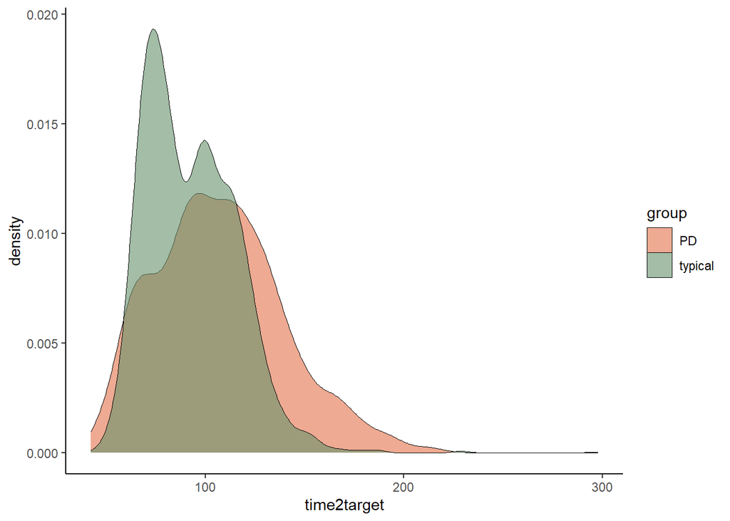

```r
ggplot(df, aes(x=time2target, fill = group)) +
  geom_density(size = 0, alpha=0.6) + theme_classic() +labs(x="time2target") + scale_fill_manual(values=c("#e37249", "#66916a"))
```

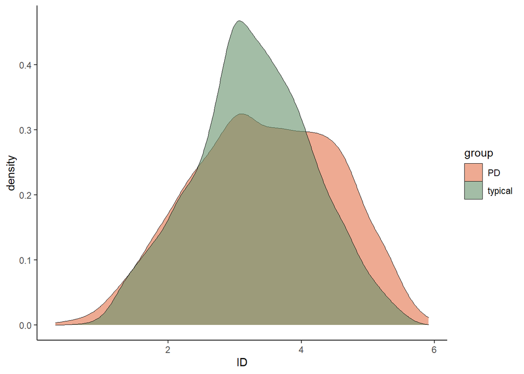

```r
ggplot(df, aes(x=ID, fill = group)) +
  geom_density(size = 0, alpha=0.6) +labs(x="ID") + theme_classic() + scale_fill_manual(values=c("#e37249", "#66916a"))
```

# 4 Hypothesis testing

Check Fitts’s law

```r
summary(m.Fitts <- bam(time2target ~ s(ID) + s(ID, subj, bs='fs', m =1), data = df, discrete = T, nthreads = 10))
```

```
##
## Family: gaussian
## Link function: identity
##
## Formula:
## time2target ~ s(ID) + s(ID, subj, bs = "fs", m = 1)
##
## Parametric coefficients:
##             Estimate Std. Error t value Pr(>|t|)
## (Intercept)   98.349      3.394   28.98   <2e-16 ***
## ---
## Signif. codes:  0 '***' 0.001 '**' 0.01 '*' 0.05 '.' 0.1 ' ' 1
##
## Approximate significance of smooth terms:
##                edf  Ref.df      F p-value
## s(ID)        4.536   5.045  5.664 3.2e-05 ***
## s(ID,subj) 196.320 373.000 27.847 < 2e-16 ***
## ---
## Signif. codes:  0 '***' 0.001 '**' 0.01 '*' 0.05 '.' 0.1 ' ' 1
##
## R-sq.(adj) =  0.779   Deviance explained = 79.1%
## fREML =  15931  Scale est. = 179.58    n = 3892
```

We see evidence for Fitts’s law, when ID increases, also time to target increases.

Visualize:

```
## Summary:
##  * ID : numeric predictor; with 30 values ranging from 0.306751 to 5.911636.
##  * subj : factor; set to the value(s): CTRL01. (Might be canceled as random effect, check below.)
##  * NOTE : The following random effects columns are canceled: s(ID,subj)
##
```

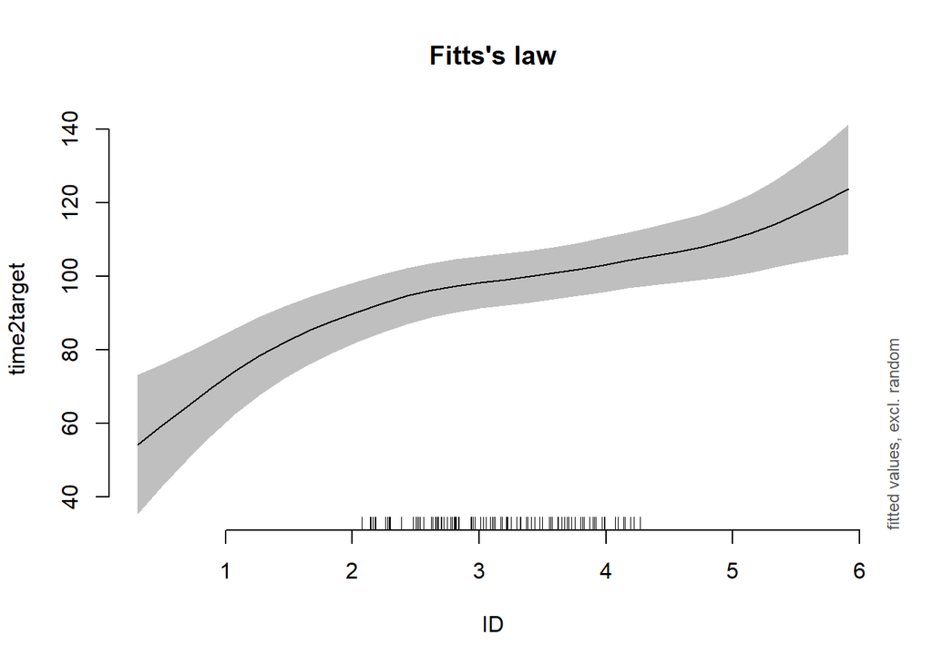

```r
plot_smooth(m.Fitts, view = "ID", main = "Fitts's law")
```

Is there a difference between typical and PD speakers? (hypothesized model)

```r
summary(m.hypo <- bam(time2target ~ groupO + s(ID) + s(ID, by = groupO) + s(ID, subj, bs='fs', m =1), data = df, discrete = T, nthreads = 10))
```

```
##
## Family: gaussian
## Link function: identity
##
## Formula:
## time2target ~ groupO + s(ID) + s(ID, by = groupO) + s(ID, subj,
##     bs = "fs", m = 1)
##
## Parametric coefficients:
##               Estimate Std. Error t value Pr(>|t|)
## (Intercept)    104.635      4.803   21.78   <2e-16 ***
## groupOtypical  -11.707      6.503   -1.80   0.0719 .
## ---
## Signif. codes:  0 '***' 0.001 '**' 0.01 '*' 0.05 '.' 0.1 ' ' 1
##
## Approximate significance of smooth terms:
##                         edf  Ref.df      F  p-value
## s(ID)                 4.268   4.747  5.067 0.000358 ***
## s(ID):groupOtypical   1.000   1.000  1.068 0.301446
## s(ID,subj)          194.709 373.000 25.351  < 2e-16 ***
## ---
## Signif. codes:  0 '***' 0.001 '**' 0.01 '*' 0.05 '.' 0.1 ' ' 1
##
## R-sq.(adj) =  0.779   Deviance explained = 79.1%
## fREML =  15923  Scale est. = 179.59    n = 3892
```

No.

Check assumptions:

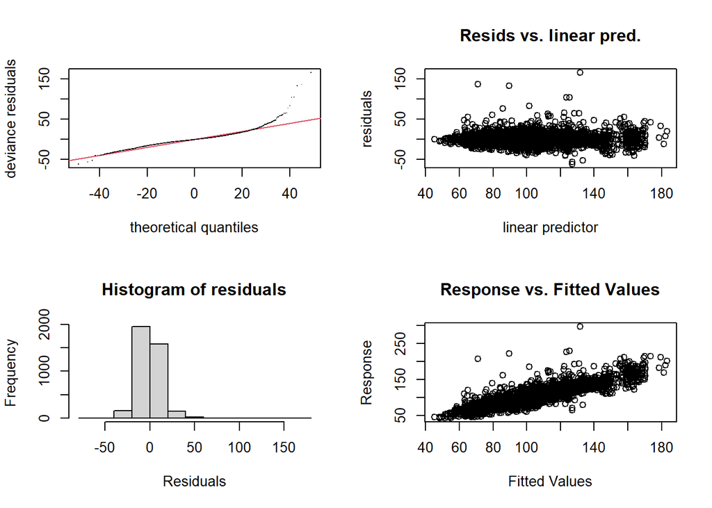

```
##
## Method: fREML   Optimizer: perf chol
## $grad
## [1]  2.452130e-06 -4.299655e-05 -4.827988e-06 -1.180121e-06  5.393909e-05
##
## $hess
##            [,1]          [,2]          [,3]          [,4]          [,5]
##    5.806663e-01 -2.453902e-06  1.105844e-01 -7.024945e-02 -1.634077e+00
##   -2.453902e-06  4.299393e-05  4.823660e-06  1.179900e-06 -5.392911e-05
##    1.105844e-01  4.823660e-06  5.053523e+01  1.502004e+00 -7.901114e+01
##   -7.024945e-02  1.179900e-06  1.502004e+00  1.665295e+01 -1.834335e+01
## d -1.634077e+00 -5.392911e-05 -7.901114e+01 -1.834335e+01  1.944000e+03
##
## Model rank =  398 / 398
##
## Basis dimension (k) checking results. Low p-value (k-index<1) may
## indicate that k is too low, especially if edf is close to k'.
##
##                         k'    edf k-index p-value
## s(ID)                 9.00   4.27    0.98   0.075 .
## s(ID):groupOtypical   9.00   1.00    0.98   0.065 .
## s(ID,subj)          378.00 194.71    0.98   0.065 .
## ---
## Signif. codes:  0 '***' 0.001 '**' 0.01 '*' 0.05 '.' 0.1 ' ' 1
```

```r
gam.check(m.hypo)
```

Looks like it needs a log transform.

```r
summary(m.hypo_gamma <- bam(time2target ~ groupO + s(ID) + s(ID, by = groupO) + s(ID, subj, bs='fs', m =1), family = Gamma(link=log), data = df, discrete = T, nthreads = 10))
```

```
##
## Family: Gamma
## Link function: log
##
## Formula:
## time2target ~ groupO + s(ID) + s(ID, by = groupO) + s(ID, subj,
##     bs = "fs", m = 1)
##
## Parametric coefficients:
##               Estimate Std. Error t value Pr(>|t|)
## (Intercept)    4.60345    0.04652   98.96   <2e-16 ***
## groupOtypical -0.10022    0.06305   -1.59    0.112
## ---
## Signif. codes:  0 '***' 0.001 '**' 0.01 '*' 0.05 '.' 0.1 ' ' 1
##
## Approximate significance of smooth terms:
##                         edf  Ref.df      F  p-value
## s(ID)                 5.790   6.397  7.074 4.17e-07 ***
## s(ID):groupOtypical   1.274   1.321  1.093     0.39
## s(ID,subj)          190.655 372.000 23.899  < 2e-16 ***
## ---
## Signif. codes:  0 '***' 0.001 '**' 0.01 '*' 0.05 '.' 0.1 ' ' 1
##
## R-sq.(adj) =  0.779   Deviance explained = 80.1%
## fREML = -2125.3  Scale est. = 0.018213  n = 3892
```

Check once more:

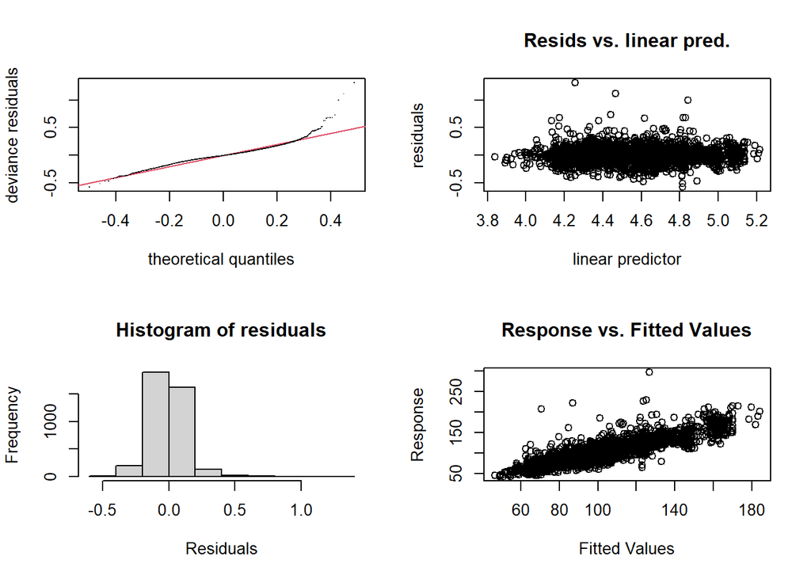

```
##
## Method: fREML   Optimizer: perf chol
## $grad
## [1]  4.369037e-06 -7.836502e-07 -8.047686e-05 -6.270259e-06  1.002692e-03
##
## $hess
##           [,1]         [,2]         [,3]          [,4]         [,5]
##    1.292513815  0.005037828  -0.26661432  -0.086032902   -2.3948511
##    0.005037828  0.011753579   0.09255258  -0.001781074   -0.1367924
##   -0.266614322  0.092552575  50.16524963   1.369195886  -77.0107289
##   -0.086032902 -0.001781074   1.36919589  16.855174868  -18.3166926
## d -2.394851104 -0.136792436 -77.01072892 -18.316692558 1943.9989973
##
## Model rank =  398 / 398
##
## Basis dimension (k) checking results. Low p-value (k-index<1) may
## indicate that k is too low, especially if edf is close to k'.
##
##                         k'    edf k-index p-value
## s(ID)                 9.00   5.79    0.97   0.045 *
## s(ID):groupOtypical   9.00   1.27    0.97   0.040 *
## s(ID,subj)          378.00 190.66    0.97   0.030 *
## ---
## Signif. codes:  0 '***' 0.001 '**' 0.01 '*' 0.05 '.' 0.1 ' ' 1
```

```r
gam.check(m.hypo_gamma)
```

Doesn’t help.

Model criticism, trimming:

```r
df2 <- df[abs(scale(resid(m.hypo))) < 2.5, ] # trim model
(1 - (nrow(df2))/nrow(df)) * 100
```

```
## [1] 2.235355
```

Refit using trimmed data:

```r
summary(m.hypotrim <- bam(time2target ~ groupO + s(ID) + s(ID, by = groupO) + s(ID, subj, bs='fs', m =1), data = df2, discrete = T, nthreads = 10))
```

```
##
## Family: gaussian
## Link function: identity
##
## Formula:
## time2target ~ groupO + s(ID) + s(ID, by = groupO) + s(ID, subj,
##     bs = "fs", m = 1)
##
## Parametric coefficients:
##               Estimate Std. Error t value Pr(>|t|)
## (Intercept)    104.100      4.779  21.782   <2e-16 ***
## groupOtypical  -11.475      6.489  -1.768   0.0771 .
## ---
## Signif. codes:  0 '***' 0.001 '**' 0.01 '*' 0.05 '.' 0.1 ' ' 1
##
## Approximate significance of smooth terms:
##                         edf Ref.df      F  p-value
## s(ID)                 4.705    5.2  6.883 1.63e-06 ***
## s(ID):groupOtypical   1.000    1.0  1.724    0.189
## s(ID,subj)          206.698  371.0 38.159  < 2e-16 ***
## ---
## Signif. codes:  0 '***' 0.001 '**' 0.01 '*' 0.05 '.' 0.1 ' ' 1
##
## R-sq.(adj) =  0.848   Deviance explained = 85.6%
## fREML =  14683  Scale est. = 110.03    n = 3805
```

Check trimmed model:

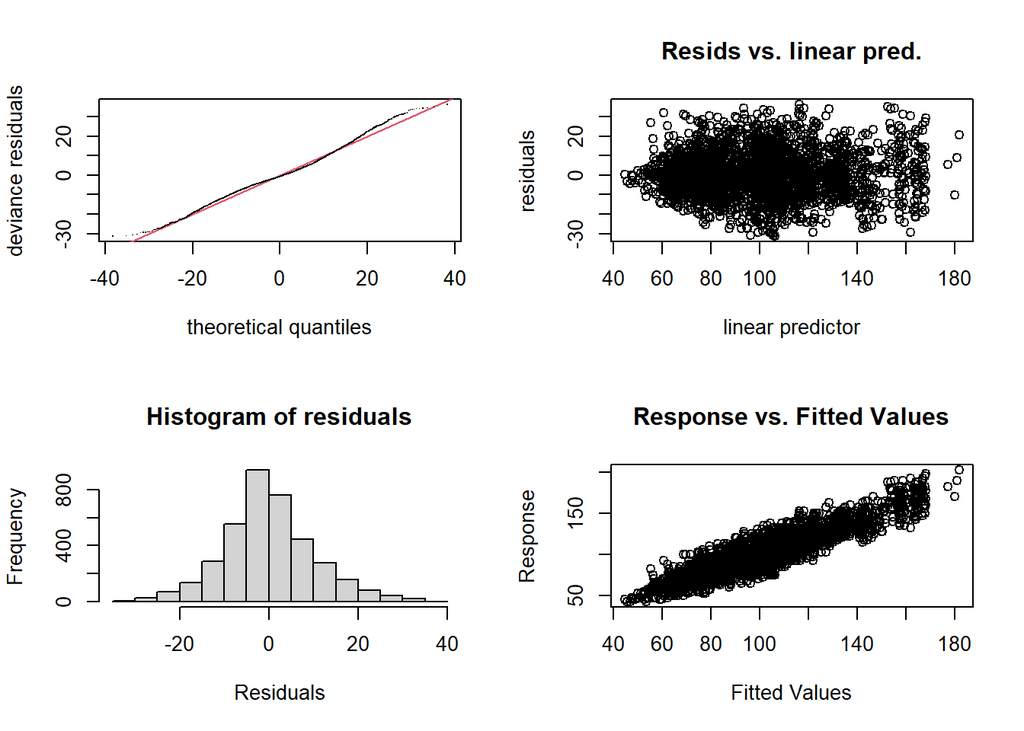

```
##
## Method: fREML   Optimizer: perf chol
## $grad
## [1]  3.324481e-06 -1.360358e-05 -2.993594e-05  6.431832e-07  4.168638e-05
##
## $hess
##            [,1]          [,2]          [,3]          [,4]          [,5]
##    1.106463e+00 -3.327422e-06  4.141713e-01 -7.438549e-02 -1.852415e+00
##   -3.327422e-06  1.360441e-05  2.996553e-05 -6.436103e-07 -4.171491e-05
##    4.141713e-01  2.996553e-05  5.647265e+01  1.117227e+00 -8.474527e+01
##   -7.438549e-02 -6.436103e-07  1.117227e+00  1.705192e+01 -1.860370e+01
## d -1.852415e+00 -4.171491e-05 -8.474527e+01 -1.860370e+01  1.900500e+03
##
## Model rank =  398 / 398
##
## Basis dimension (k) checking results. Low p-value (k-index<1) may
## indicate that k is too low, especially if edf is close to k'.
##
##                        k'   edf k-index p-value
## s(ID)                 9.0   4.7       1    0.42
## s(ID):groupOtypical   9.0   1.0       1    0.42
## s(ID,subj)          378.0 206.7       1    0.42
```

```r
gam.check(m.hypotrim)
```

Much better.

Plot:

```
## Summary:
##  * groupO : factor; set to the value(s): typical.
##  * ID : numeric predictor; with 30 values ranging from 0.306751 to 5.911636.
##  * subj : factor; set to the value(s): CTRL02. (Might be canceled as random effect, check below.)
##  * NOTE : The following random effects columns are canceled: s(ID,subj)
##
```

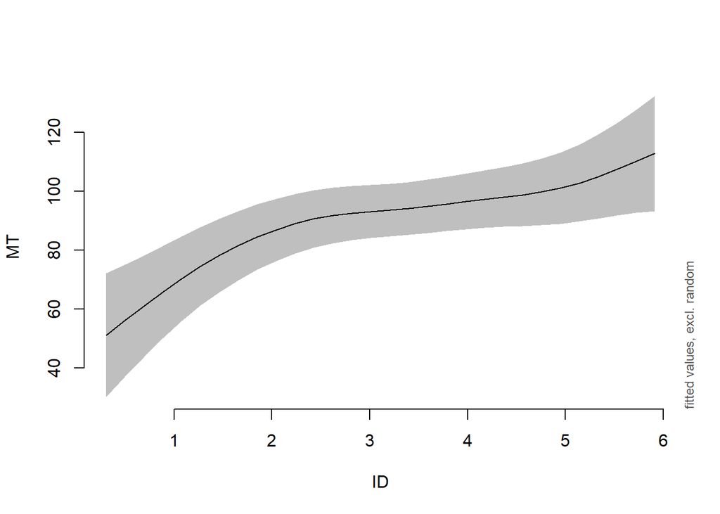

```r
plot_smooth(m.hypotrim, view="ID", rug=F, ylab = "MT", xlab = "ID")
```

# 5 Exploratory analysis

Fit hypothesis model, though without the separate smooths over ID, using ML for subsequent analysis:

```r
summary(m.hypoML <- bam(time2target ~ groupO + s(ID) + s(ID, subj, bs='fs', m =1), data = df, method = "ML"))
```

```
##
## Family: gaussian
## Link function: identity
##
## Formula:
## time2target ~ groupO + s(ID) + s(ID, subj, bs = "fs", m = 1)
##
## Parametric coefficients:
##               Estimate Std. Error t value Pr(>|t|)
## (Intercept)    106.558      4.778  22.301   <2e-16 ***
## groupOtypical  -13.182      6.518  -2.022   0.0432 *
## ---
## Signif. codes:  0 '***' 0.001 '**' 0.01 '*' 0.05 '.' 0.1 ' ' 1
##
## Approximate significance of smooth terms:
##                edf  Ref.df      F p-value
## s(ID)        6.055   6.725  6.646  <2e-16 ***
## s(ID,subj) 190.224 371.000 24.580  <2e-16 ***
## ---
## Signif. codes:  0 '***' 0.001 '**' 0.01 '*' 0.05 '.' 0.1 ' ' 1
##
## R-sq.(adj) =  0.772   Deviance explained = 78.3%
## -ML =  15976  Scale est. = 185.66    n = 3892
```

Add segO?

```r
summary(m0 <- bam(time2target ~ segO + groupO + s(ID) + s(ID, subj, bs='fs', m = 1), data = df, method = "ML"))
```

```
##
## Family: gaussian
## Link function: identity
##
## Formula:
## time2target ~ segO + groupO + s(ID) + s(ID, subj, bs = "fs",
##     m = 1)
##
## Parametric coefficients:
##               Estimate Std. Error t value Pr(>|t|)
## (Intercept)    99.3750     4.3975  22.598  < 2e-16 ***
## segOK          15.1041     0.6886  21.933  < 2e-16 ***
## segOT           4.0256     0.5989   6.721 2.08e-11 ***
## groupOtypical -11.4627     5.9667  -1.921   0.0548 .
## ---
## Signif. codes:  0 '***' 0.001 '**' 0.01 '*' 0.05 '.' 0.1 ' ' 1
##
## Approximate significance of smooth terms:
##                edf  Ref.df     F p-value
## s(ID)        6.449   7.079  9.23  <2e-16 ***
## s(ID,subj) 195.172 371.000 23.58  <2e-16 ***
## ---
## Signif. codes:  0 '***' 0.001 '**' 0.01 '*' 0.05 '.' 0.1 ' ' 1
##
## R-sq.(adj) =  0.799   Deviance explained =   81%
## -ML =  15737  Scale est. = 163.44    n = 3892
```

```r
compareML(m.hypoML, m0)
```

```
## m.hypoML: time2target ~ groupO + s(ID) + s(ID, subj, bs = "fs", m = 1)
##
## m0: time2target ~ segO + groupO + s(ID) + s(ID, subj, bs = "fs",
##     m = 1)
##
## Chi-square test of ML scores
## -----
##      Model    Score Edf Difference    Df  p.value Sig.
## 1 m.hypoML 15975.97   6
## 2       m0 15736.98   8    238.990 2.000  < 2e-16  ***
##
## AIC difference: 489.24, model m0 has lower AIC.
```

Yes.

Include random smooth per segment?

```r
summary(m0smooth <- bam(time2target ~ segO + groupO + s(ID) + s(ID, subj, bs='fs', m =1) + s(ID, subj, by = segO, bs='fs', m =1), data = df, discrete = T, nthreads = 10))
```

```
##
## Family: gaussian
## Link function: identity
##
## Formula:
## time2target ~ segO + groupO + s(ID) + s(ID, subj, bs = "fs",
##     m = 1) + s(ID, subj, by = segO, bs = "fs", m = 1)
##
## Parametric coefficients:
##               Estimate Std. Error t value Pr(>|t|)
## (Intercept)     96.218      4.199  22.913  < 2e-16 ***
## segOK           18.042      2.232   8.082 8.71e-16 ***
## segOT            6.673      1.398   4.772 1.90e-06 ***
## groupOtypical  -10.577      5.641  -1.875   0.0609 .
## ---
## Signif. codes:  0 '***' 0.001 '**' 0.01 '*' 0.05 '.' 0.1 ' ' 1
##
## Approximate significance of smooth terms:
##                      edf  Ref.df      F p-value
## s(ID)              1.001   1.001 55.622  <2e-16 ***
## s(ID,subj)       166.403 372.000 12.089  <2e-16 ***
## s(ID,subj):segOK 104.123 317.000  2.013  <2e-16 ***
## s(ID,subj):segOT 106.979 324.000  1.320  <2e-16 ***
## ---
## Signif. codes:  0 '***' 0.001 '**' 0.01 '*' 0.05 '.' 0.1 ' ' 1
##
## R-sq.(adj) =  0.853   Deviance explained = 86.7%
## fREML =  15377  Scale est. = 119.59    n = 3892
```

Yes.

Add pace (number of repetitions per second, based on the mean) or median measure:

```r
summary(m.pace <- bam(time2target ~ segO + groupO + s(pace) + s(ID) + s(ID, subj, bs='fs', m =1) + s(ID, subj, by = segO, bs='fs', m =1), data = df, select = T, discrete = T, nthreads = 10))
```

```
##
## Family: gaussian
## Link function: identity
##
## Formula:
## time2target ~ segO + groupO + s(pace) + s(ID) + s(ID, subj, bs = "fs",
##     m = 1) + s(ID, subj, by = segO, bs = "fs", m = 1)
##
## Parametric coefficients:
##               Estimate Std. Error t value Pr(>|t|)
## (Intercept)    95.4713     1.2332  77.417  < 2e-16 ***
## segOK           5.8898     1.3626   4.323 1.58e-05 ***
## segOT           1.1288     0.7881   1.432    0.152
## groupOtypical   0.4140     1.4948   0.277    0.782
## ---
## Signif. codes:  0 '***' 0.001 '**' 0.01 '*' 0.05 '.' 0.1 ' ' 1
##
## Approximate significance of smooth terms:
##                      edf Ref.df       F p-value
## s(pace)            8.064      9 199.983  <2e-16 ***
## s(ID)              5.430      9   4.174  <2e-16 ***
## s(ID,subj)       146.622    372   2.328  <2e-16 ***
## s(ID,subj):segOK 101.111    301   1.304  <2e-16 ***
## s(ID,subj):segOT  58.092    323   0.416  <2e-16 ***
## ---
## Signif. codes:  0 '***' 0.001 '**' 0.01 '*' 0.05 '.' 0.1 ' ' 1
##
## R-sq.(adj) =  0.881   Deviance explained = 89.1%
## fREML =  14827  Scale est. = 97.007    n = 3892
```

```r
summary(m.median <- bam(time2target ~ segO + groupO + s(median.time.between.targets) + s(ID) + s(ID, subj, bs='fs', m =1) + s(ID, subj, by = segO, bs='fs', m =1), data = df, select = T, discrete = T, nthreads = 10))
```

```
##
## Family: gaussian
## Link function: identity
##
## Formula:
## time2target ~ segO + groupO + s(median.time.between.targets) +
##     s(ID) + s(ID, subj, bs = "fs", m = 1) + s(ID, subj, by = segO,
##     bs = "fs", m = 1)
##
## Parametric coefficients:
##               Estimate Std. Error t value Pr(>|t|)
## (Intercept)    98.4210     1.2463  78.968  < 2e-16 ***
## segOK           6.6406     1.3303   4.992 6.27e-07 ***
## segOT           1.5235     0.7623   1.998   0.0457 *
## groupOtypical   0.1829     1.5074   0.121   0.9034
## ---
## Signif. codes:  0 '***' 0.001 '**' 0.01 '*' 0.05 '.' 0.1 ' ' 1
##
## Approximate significance of smooth terms:
##                                    edf Ref.df       F p-value
## s(median.time.between.targets)   7.236      9 199.844  <2e-16 ***
## s(ID)                            5.045      9   4.608  <2e-16 ***
## s(ID,subj)                     146.805    372   2.297  <2e-16 ***
## s(ID,subj):segOK                99.784    301   1.262  <2e-16 ***
## s(ID,subj):segOT                55.124    323   0.392  <2e-16 ***
## ---
## Signif. codes:  0 '***' 0.001 '**' 0.01 '*' 0.05 '.' 0.1 ' ' 1
##
## R-sq.(adj) =   0.88   Deviance explained =   89%
## fREML =  14827  Scale est. = 97.539    n = 3892
```

```r
compareML(m.pace, m.median)
```

```
## m.pace: time2target ~ segO + groupO + s(pace) + s(ID) + s(ID, subj, bs = "fs",
##     m = 1) + s(ID, subj, by = segO, bs = "fs", m = 1)
##
## m.median: time2target ~ segO + groupO + s(median.time.between.targets) +
##     s(ID) + s(ID, subj, bs = "fs", m = 1) + s(ID, subj, by = segO,
##     bs = "fs", m = 1)
##
## Model m.pace preferred: lower fREML score (0.081), and equal df (0.000).
## -----
##      Model    Score Edf Difference    Df
## 1 m.median 14826.58  14
## 2   m.pace 14826.50  14      0.081 0.000
##
## AIC difference: -16.06, model m.pace has lower AIC.
```

Pace model has lowest AIC, so we continue with that model.

Add random smooth over pace for each segment?

```r
summary(m3 <- bam(time2target ~ segO  + groupO + s(pace) + s(ID) + s(pace, subj, bs='fs', m =1) + s(pace, subj, by = segO, bs='fs', m =1) + s(ID, subj, bs='fs', m =1) + s(ID, subj, by = segO, bs='fs', m =1), data = df, discrete = T, nthreads = 10))
```

```
##
## Family: gaussian
## Link function: identity
##
## Formula:
## time2target ~ segO + groupO + s(pace) + s(ID) + s(pace, subj,
##     bs = "fs", m = 1) + s(pace, subj, by = segO, bs = "fs", m = 1) +
##     s(ID, subj, bs = "fs", m = 1) + s(ID, subj, by = segO, bs = "fs",
##     m = 1)
##
## Parametric coefficients:
##               Estimate Std. Error t value Pr(>|t|)
## (Intercept)    96.0011     1.2948  74.144  < 2e-16 ***
## segOK           6.5946     1.5215   4.334  1.5e-05 ***
## segOT           1.7305     0.9299   1.861   0.0628 .
## groupOtypical  -0.1823     1.5862  -0.115   0.9085
## ---
## Signif. codes:  0 '***' 0.001 '**' 0.01 '*' 0.05 '.' 0.1 ' ' 1
##
## Approximate significance of smooth terms:
##                        edf  Ref.df      F  p-value
## s(pace)              6.720   7.274 73.178  < 2e-16 ***
## s(ID)                6.646   7.268  5.816 9.70e-07 ***
## s(pace,subj)        60.046 297.000  0.490  < 2e-16 ***
## s(pace,subj):segOK   8.595 120.000  0.084 1.38e-06 ***
## s(pace,subj):segOT  17.337 129.000  0.173  < 2e-16 ***
## s(ID,subj)         121.890 368.000  1.100  < 2e-16 ***
## s(ID,subj):segOK    97.063 301.000  1.060  < 2e-16 ***
## s(ID,subj):segOT    43.004 323.000  0.216  < 2e-16 ***
## ---
## Signif. codes:  0 '***' 0.001 '**' 0.01 '*' 0.05 '.' 0.1 ' ' 1
##
## R-sq.(adj) =  0.885   Deviance explained = 89.6%
## fREML =  14791  Scale est. = 93.419    n = 3892
```

Yes.

Visualize:

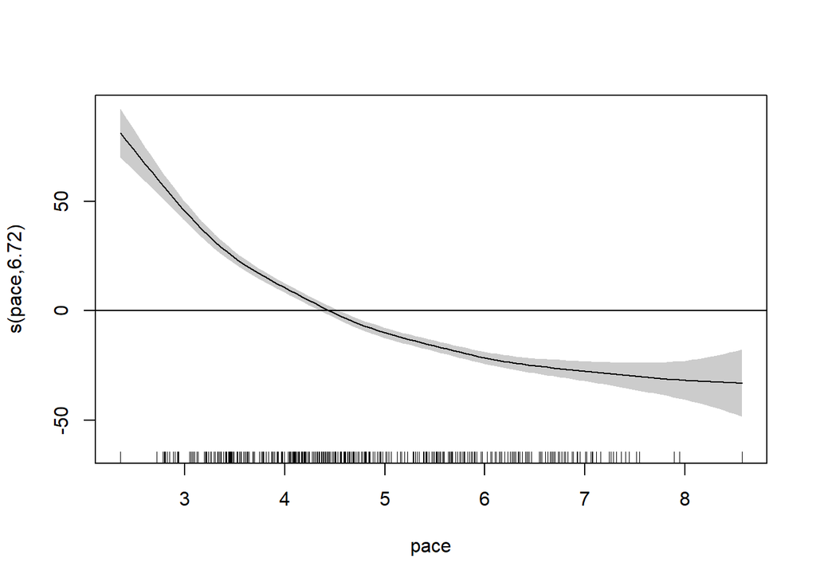

```r
plot(m3, select = 1, shade = T)
abline(h=0)
```

An increase in pace leads to a lower time2target/MT, as expected.

Separate smooths over pace for each group:

```r
summary(m4 <- bam(time2target ~ segO  + groupO + s(pace) + s(pace, by = groupO) + s(ID) + s(pace, subj, bs='fs', m =1) + s(pace, subj, by = segO, bs='fs', m =1) + s(ID, subj, bs='fs', m =1) + s(ID, subj, by = segO, bs='fs', m =1), data = df, discrete = T, nthreads = 10))
```

```
##
## Family: gaussian
## Link function: identity
##
## Formula:
## time2target ~ segO + groupO + s(pace) + s(pace, by = groupO) +
##     s(ID) + s(pace, subj, bs = "fs", m = 1) + s(pace, subj, by = segO,
##     bs = "fs", m = 1) + s(ID, subj, bs = "fs", m = 1) + s(ID,
##     subj, by = segO, bs = "fs", m = 1)
##
## Parametric coefficients:
##               Estimate Std. Error t value Pr(>|t|)
## (Intercept)    96.1835     1.3206  72.831  < 2e-16 ***
## segOK           6.5957     1.5285   4.315 1.64e-05 ***
## segOT           1.7316     0.9420   1.838   0.0661 .
## groupOtypical  -0.4963     1.6474  -0.301   0.7633
## ---
## Signif. codes:  0 '***' 0.001 '**' 0.01 '*' 0.05 '.' 0.1 ' ' 1
##
## Approximate significance of smooth terms:
##                           edf  Ref.df      F  p-value
## s(pace)                 6.695   7.244 43.900  < 2e-16 ***
## s(pace):groupOtypical   1.527   1.623  0.320    0.771
## s(ID)                   6.632   7.254  5.855 9.06e-07 ***
## s(pace,subj)           59.335 297.000  0.481  < 2e-16 ***
## s(pace,subj):segOK      8.819 120.000  0.087 1.16e-06 ***
## s(pace,subj):segOT     18.713 129.000  0.191  < 2e-16 ***
## s(ID,subj)            121.568 368.000  1.094  < 2e-16 ***
## s(ID,subj):segOK       96.962 302.000  1.054  < 2e-16 ***
## s(ID,subj):segOT       42.262 324.000  0.209  < 2e-16 ***
## ---
## Signif. codes:  0 '***' 0.001 '**' 0.01 '*' 0.05 '.' 0.1 ' ' 1
##
## R-sq.(adj) =  0.885   Deviance explained = 89.6%
## fREML =  14789  Scale est. = 93.344    n = 3892
```

No.

Add the interaction between pace and ID:

```r
summary(m5 <- bam(time2target ~ segO  + groupO + te(pace, ID) + s(pace, subj, bs='fs', m =1) + s(pace, subj, by = segO, bs='fs', m =1) + s(ID, subj, bs='fs', m =1) + s(ID, subj, by = segO, bs='fs', m =1), data = df, discrete = T, nthreads = 10))
```

```
##
## Family: gaussian
## Link function: identity
##
## Formula:
## time2target ~ segO + groupO + te(pace, ID) + s(pace, subj, bs = "fs",
##     m = 1) + s(pace, subj, by = segO, bs = "fs", m = 1) + s(ID,
##     subj, bs = "fs", m = 1) + s(ID, subj, by = segO, bs = "fs",
##     m = 1)
##
## Parametric coefficients:
##               Estimate Std. Error t value Pr(>|t|)
## (Intercept)    96.8360     1.3456  71.967  < 2e-16 ***
## segOK           5.9952     1.5584   3.847 0.000122 ***
## segOT           1.5039     0.8344   1.802 0.071563 .
## groupOtypical  -0.2144     1.4994  -0.143 0.886307
## ---
## Signif. codes:  0 '***' 0.001 '**' 0.01 '*' 0.05 '.' 0.1 ' ' 1
##
## Approximate significance of smooth terms:
##                        edf Ref.df      F  p-value
## te(pace,ID)         14.887   16.1 46.024  < 2e-16 ***
## s(pace,subj)        54.924  297.0  0.417  < 2e-16 ***
## s(pace,subj):segOK  14.451  120.0  0.159  < 2e-16 ***
## s(pace,subj):segOT   1.696  128.0  0.014 3.22e-05 ***
## s(ID,subj)         121.312  371.0  1.071  < 2e-16 ***
## s(ID,subj):segOK    94.725  302.0  0.970  < 2e-16 ***
## s(ID,subj):segOT    54.602  323.0  0.343  < 2e-16 ***
## ---
## Signif. codes:  0 '***' 0.001 '**' 0.01 '*' 0.05 '.' 0.1 ' ' 1
##
## R-sq.(adj) =  0.884   Deviance explained = 89.5%
## fREML =  14784  Scale est. = 94.009    n = 3892
```

Yes.

Visualize:

```r
fvisgam(m5, view=c("pace","ID"), rm.ranef=TRUE)
```

```
## Summary:
##  * segO : factor; set to the value(s): P.
##  * groupO : factor; set to the value(s): typical.
##  * pace : numeric predictor; with 30 values ranging from 2.352941 to 8.571429.
##  * ID : numeric predictor; with 30 values ranging from 0.306751 to 5.911636.
##  * subj : factor; set to the value(s): CTRL01. (Might be canceled as random effect, check below.)
##  * NOTE : The following random effects columns are canceled: s(pace,subj),s(pace,subj):segOK,s(pace,subj):segOT,s(ID,subj),s(ID,subj):segOK,s(ID,subj):segOT
##
```

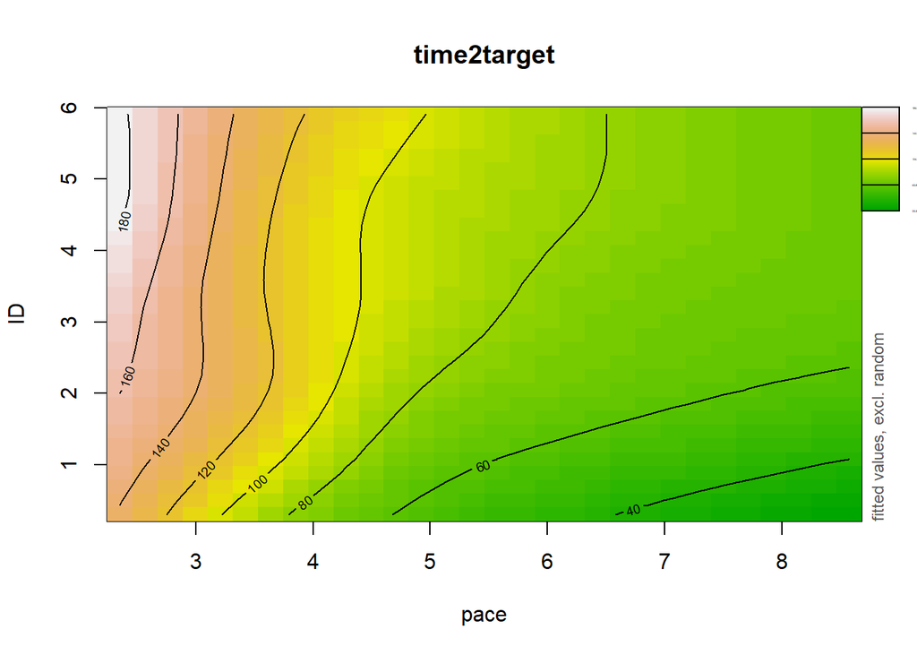

Only the smooth without the intercept:

```r
pvisgam(m5, view=c("pace","ID"), select=1)
```

```
## [1] "Tensor(s) to be plotted: te(pace,ID)"
```

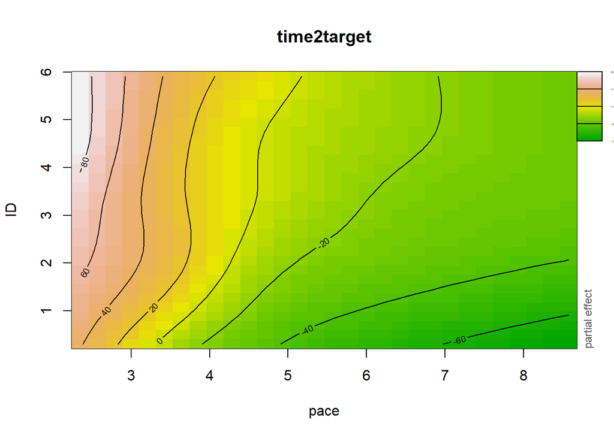

By group:

```r
summary(m6 <- bam(time2target ~ segO  + groupO + te(pace, ID) + te(pace, ID, by = groupO) + s(pace, subj, bs='fs', m =1) + s(pace, subj, by = segO, bs='fs', m =1) + s(ID, subj, bs='fs', m =1) + s(ID, subj, by = segO, bs='fs', m =1), data = df, discrete = T, nthreads = 10))
```

```
##
## Family: gaussian
## Link function: identity
##
## Formula:
## time2target ~ segO + groupO + te(pace, ID) + te(pace, ID, by = groupO) +
##     s(pace, subj, bs = "fs", m = 1) + s(pace, subj, by = segO,
##     bs = "fs", m = 1) + s(ID, subj, bs = "fs", m = 1) + s(ID,
##     subj, by = segO, bs = "fs", m = 1)
##
## Parametric coefficients:
##               Estimate Std. Error t value Pr(>|t|)
## (Intercept)    98.0397     1.4723  66.588  < 2e-16 ***
## segOK           5.9629     1.5834   3.766 0.000169 ***
## segOT           1.4045     0.8279   1.696 0.089894 .
## groupOtypical  -2.2276     1.8272  -1.219 0.222879
## ---
## Signif. codes:  0 '***' 0.001 '**' 0.01 '*' 0.05 '.' 0.1 ' ' 1
##
## Approximate significance of smooth terms:
##                                 edf  Ref.df      F p-value
## te(pace,ID)               1.460e+01  15.777 27.711 < 2e-16 ***
## te(pace,ID):groupOtypical 5.887e+00   6.557  0.956   0.473
## s(pace,subj)              5.418e+01 298.000  0.419 < 2e-16 ***
## s(pace,subj):segOK        1.584e+01 120.000  0.178 < 2e-16 ***
## s(pace,subj):segOT        3.251e-03 129.000  0.000 1.5e-05 ***
## s(ID,subj)                1.205e+02 371.000  1.054 < 2e-16 ***
## s(ID,subj):segOK          9.401e+01 302.000  0.961 < 2e-16 ***
## s(ID,subj):segOT          5.467e+01 324.000  0.353 < 2e-16 ***
## ---
## Signif. codes:  0 '***' 0.001 '**' 0.01 '*' 0.05 '.' 0.1 ' ' 1
##
## R-sq.(adj) =  0.885   Deviance explained = 89.6%
## fREML =  14770  Scale est. = 93.706    n = 3892
```

No.

Add the interaction between pace and ID as a ti?

```r
summary(m7 <- bam(time2target ~ segO  + groupO + s(pace) + s(ID) + ti(pace, ID) + s(pace, subj, bs='fs', m =1) + s(pace, subj, by = segO, bs='fs', m =1) + s(ID, subj, bs='fs', m =1) + s(ID, subj, by = segO, bs='fs', m =1), data = df, discrete = T, nthreads = 10))
```

```
##
## Family: gaussian
## Link function: identity
##
## Formula:
## time2target ~ segO + groupO + s(pace) + s(ID) + ti(pace, ID) +
##     s(pace, subj, bs = "fs", m = 1) + s(pace, subj, by = segO,
##     bs = "fs", m = 1) + s(ID, subj, bs = "fs", m = 1) + s(ID,
##     subj, by = segO, bs = "fs", m = 1)
##
## Parametric coefficients:
##               Estimate Std. Error t value Pr(>|t|)
## (Intercept)    96.8695     1.3817  70.108  < 2e-16 ***
## segOK           6.0627     1.5018   4.037 5.53e-05 ***
## segOT           1.5234     0.9010   1.691    0.091 .
## groupOtypical  -0.1116     1.5344  -0.073    0.942
## ---
## Signif. codes:  0 '***' 0.001 '**' 0.01 '*' 0.05 '.' 0.1 ' ' 1
##
## Approximate significance of smooth terms:
##                        edf  Ref.df      F  p-value
## s(pace)              6.676   7.258 65.513  < 2e-16 ***
## s(ID)                6.739   7.349  3.928 0.000126 ***
## ti(pace,ID)          5.431   6.392  0.959 0.453526
## s(pace,subj)        55.975 297.000  0.423  < 2e-16 ***
## s(pace,subj):segOK   8.405 120.000  0.082 1.41e-06 ***
## s(pace,subj):segOT  11.460 129.000  0.104 2.00e-07 ***
## s(ID,subj)         121.055 369.000  1.075  < 2e-16 ***
## s(ID,subj):segOK    95.614 301.000  0.999  < 2e-16 ***
## s(ID,subj):segOT    48.908 323.000  0.266  < 2e-16 ***
## ---
## Signif. codes:  0 '***' 0.001 '**' 0.01 '*' 0.05 '.' 0.1 ' ' 1
##
## R-sq.(adj) =  0.885   Deviance explained = 89.6%
## fREML =  14785  Scale est. = 93.53     n = 3892
```

No.

Check if there’s a group difference:

```r
summary(m8 <- bam(time2target ~ segO  + groupO + s(pace) + s(ID) + ti(pace, ID) +ti(pace, ID, by = groupO) + s(pace, subj, bs='fs', m =1) + s(pace, subj, by = segO, bs='fs', m =1) + s(ID, subj, bs='fs', m =1) + s(ID, subj, by = segO, bs='fs', m =1), data = df, discrete = T, nthreads = 10))
```

```
##
## Family: gaussian
## Link function: identity
##
## Formula:
## time2target ~ segO + groupO + s(pace) + s(ID) + ti(pace, ID) +
##     ti(pace, ID, by = groupO) + s(pace, subj, bs = "fs", m = 1) +
##     s(pace, subj, by = segO, bs = "fs", m = 1) + s(ID, subj,
##     bs = "fs", m = 1) + s(ID, subj, by = segO, bs = "fs", m = 1)
##
## Parametric coefficients:
##               Estimate Std. Error t value Pr(>|t|)
## (Intercept)    97.4005     1.4041  69.370  < 2e-16 ***
## segOK           5.9382     1.4989   3.962 7.59e-05 ***
## segOT           1.4183     0.8561   1.657   0.0976 .
## groupOtypical  -0.7928     1.5816  -0.501   0.6162
## ---
## Signif. codes:  0 '***' 0.001 '**' 0.01 '*' 0.05 '.' 0.1 ' ' 1
##
## Approximate significance of smooth terms:
##                               edf  Ref.df      F  p-value
## s(pace)                     6.661   7.248 65.212  < 2e-16 ***
## s(ID)                       6.751   7.357  4.013 9.80e-05 ***
## ti(pace,ID)                 5.578   6.556  1.396    0.204
## ti(pace,ID):groupOtypical   1.074   1.100  2.741    0.102
## s(pace,subj)               56.625 297.000  0.439  < 2e-16 ***
## s(pace,subj):segOK          8.720 119.000  0.086 1.49e-06 ***
## s(pace,subj):segOT          4.121 128.000  0.034 1.32e-05 ***
## s(ID,subj)                122.442 369.000  1.095  < 2e-16 ***
## s(ID,subj):segOK           94.996 301.000  0.985  < 2e-16 ***
## s(ID,subj):segOT           52.406 324.000  0.312  < 2e-16 ***
## ---
## Signif. codes:  0 '***' 0.001 '**' 0.01 '*' 0.05 '.' 0.1 ' ' 1
##
## R-sq.(adj) =  0.885   Deviance explained = 89.6%
## fREML =  14780  Scale est. = 93.52     n = 3892
```

No.

Add repetition number?

```r
summary(m10 <- bam(time2target ~ s(rep.no, k= 9) + segO  + groupO + s(ID) + s(pace) + s(pace, subj, bs='fs', m =1) + s(pace, subj, by = segO, bs='fs', m =1) + s(ID, subj, bs='fs', m =1) + s(ID, subj, by = segO, bs='fs', m =1), data = df, discrete = T, nthreads = 10))
```

```
##
## Family: gaussian
## Link function: identity
##
## Formula:
## time2target ~ s(rep.no, k = 9) + segO + groupO + s(ID) + s(pace) +
##     s(pace, subj, bs = "fs", m = 1) + s(pace, subj, by = segO,
##     bs = "fs", m = 1) + s(ID, subj, bs = "fs", m = 1) + s(ID,
##     subj, by = segO, bs = "fs", m = 1)
##
## Parametric coefficients:
##               Estimate Std. Error t value Pr(>|t|)
## (Intercept)   96.54345    1.24702  77.419  < 2e-16 ***
## segOK          6.17404    1.47785   4.178 3.02e-05 ***
## segOT          1.60030    0.88203   1.814   0.0697 .
## groupOtypical -0.09998    1.53391  -0.065   0.9480
## ---
## Signif. codes:  0 '***' 0.001 '**' 0.01 '*' 0.05 '.' 0.1 ' ' 1
##
## Approximate significance of smooth terms:
##                        edf  Ref.df      F  p-value
## s(rep.no)            2.568   3.181 10.343 1.00e-06 ***
## s(ID)                6.805   7.418  5.488 2.14e-06 ***
## s(pace)              6.746   7.310 78.499  < 2e-16 ***
## s(pace,subj)        59.552 297.000  0.490  < 2e-16 ***
## s(pace,subj):segOK   6.580 120.000  0.062 4.02e-06 ***
## s(pace,subj):segOT  11.753 129.000  0.107 5.49e-07 ***
## s(ID,subj)         121.492 368.000  1.094  < 2e-16 ***
## s(ID,subj):segOK    97.132 301.000  1.068  < 2e-16 ***
## s(ID,subj):segOT    45.819 323.000  0.243  < 2e-16 ***
## ---
## Signif. codes:  0 '***' 0.001 '**' 0.01 '*' 0.05 '.' 0.1 ' ' 1
##
## R-sq.(adj) =  0.886   Deviance explained = 89.6%
## fREML =  14777  Scale est. = 93.108    n = 3892
```

Yes.

Random smooths over rep.no?

```r
summary(m10smooths <- bam(time2target ~ s(rep.no, k= 9) + segO  + groupO + s(ID) + s(pace) + s(pace, subj, bs='fs', m =1) + s(pace, subj, by = segO, bs='fs', m =1) + s(ID, subj, bs='fs', m =1) + s(ID, subj, by = segO, bs='fs', m =1) + s(rep.no, subj, bs='fs', m =1) + s(rep.no, subj, by = segO, bs='fs', m =1), data = df, discrete = T, nthreads = 10))
```

```
##
## Family: gaussian
## Link function: identity
##
## Formula:
## time2target ~ s(rep.no, k = 9) + segO + groupO + s(ID) + s(pace) +
##     s(pace, subj, bs = "fs", m = 1) + s(pace, subj, by = segO,
##     bs = "fs", m = 1) + s(ID, subj, bs = "fs", m = 1) + s(ID,
##     subj, by = segO, bs = "fs", m = 1) + s(rep.no, subj, bs = "fs",
##     m = 1) + s(rep.no, subj, by = segO, bs = "fs", m = 1)
##
## Parametric coefficients:
##               Estimate Std. Error t value Pr(>|t|)
## (Intercept)    96.5706     1.2882  74.964  < 2e-16 ***
## segOK           6.3919     1.5266   4.187  2.9e-05 ***
## segOT           1.6293     0.9041   1.802   0.0716 .
## groupOtypical  -0.3152     1.5916  -0.198   0.8430
## ---
## Signif. codes:  0 '***' 0.001 '**' 0.01 '*' 0.05 '.' 0.1 ' ' 1
##
## Approximate significance of smooth terms:
##                            edf  Ref.df      F  p-value
## s(rep.no)            2.401e+00   2.851  5.116  0.00157 **
## s(ID)                7.149e+00   7.721  5.921 4.88e-07 ***
## s(pace)              6.522e+00   7.047 69.328  < 2e-16 ***
## s(pace,subj)         6.522e+01 298.000  0.576  < 2e-16 ***
## s(pace,subj):segOK   1.230e+01 120.000  0.128  < 2e-16 ***
## s(pace,subj):segOT   1.709e+01 129.000  0.171  < 2e-16 ***
## s(ID,subj)           1.184e+02 368.000  1.040  < 2e-16 ***
## s(ID,subj):segOK     9.427e+01 301.000  0.990  < 2e-16 ***
## s(ID,subj):segOT     4.128e+01 323.000  0.204  < 2e-16 ***
## s(rep.no,subj)       7.464e+01 376.000  0.395  < 2e-16 ***
## s(rep.no,subj):segOK 3.516e+01 326.000  0.153 8.81e-05 ***
## s(rep.no,subj):segOT 4.957e-04 346.000  0.000  0.00979 **
## ---
## Signif. codes:  0 '***' 0.001 '**' 0.01 '*' 0.05 '.' 0.1 ' ' 1
##
## R-sq.(adj) =  0.892   Deviance explained = 90.6%
## fREML =  14748  Scale est. = 87.527    n = 3892
```

Yes and rep.no is still significant.

Visualize:

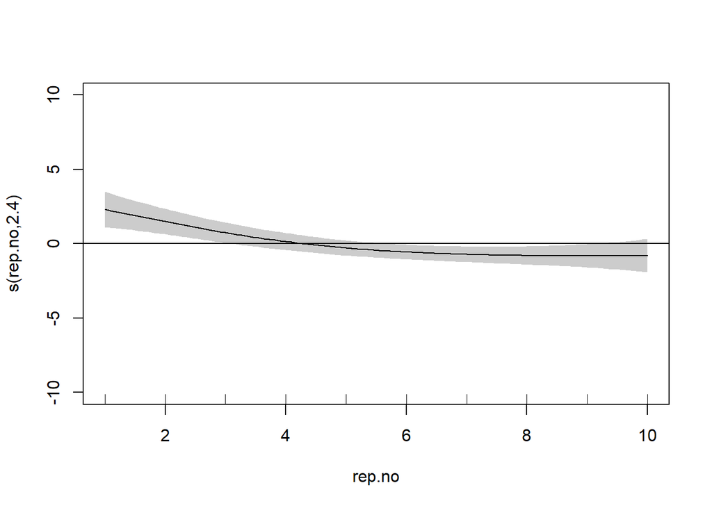

```r
plot(m10smooths, select = 1, shade = T, ylim=c(-10,10))
abline(h=0)
```

With an increase of repetition number subjects show a shorter MT.

By group?

```r
summary(m10smoothsbyGroup <- bam(time2target ~ s(rep.no, k= 9) + s(rep.no, by = groupO, k= 9) + segO  + groupO + s(ID) + s(pace) + s(pace, subj, bs='fs', m =1) + s(pace, subj, by = segO, bs='fs', m =1) + s(ID, subj, bs='fs', m =1) + s(ID, subj, by = segO, bs='fs', m =1) + s(rep.no, subj, bs='fs', m =1) + s(rep.no, subj, by = segO, bs='fs', m =1), data = df, discrete = T, nthreads = 10))
```

```
##
## Family: gaussian
## Link function: identity
##
## Formula:
## time2target ~ s(rep.no, k = 9) + s(rep.no, by = groupO, k = 9) +
##     segO + groupO + s(ID) + s(pace) + s(pace, subj, bs = "fs",
##     m = 1) + s(pace, subj, by = segO, bs = "fs", m = 1) + s(ID,
##     subj, bs = "fs", m = 1) + s(ID, subj, by = segO, bs = "fs",
##     m = 1) + s(rep.no, subj, bs = "fs", m = 1) + s(rep.no, subj,
##     by = segO, bs = "fs", m = 1)
##
## Parametric coefficients:
##               Estimate Std. Error t value Pr(>|t|)
## (Intercept)    96.4269     1.3147  73.344  < 2e-16 ***
## segOK           6.4081     1.5298   4.189 2.88e-05 ***
## segOT           1.6118     0.9067   1.778   0.0756 .
## groupOtypical  -0.3673     1.6149  -0.227   0.8201
## ---
## Signif. codes:  0 '***' 0.001 '**' 0.01 '*' 0.05 '.' 0.1 ' ' 1
##
## Approximate significance of smooth terms:
##                               edf  Ref.df      F  p-value
## s(rep.no)               2.400e+00   2.849  2.678  0.03767 *
## s(rep.no):groupOtypical 1.000e+00   1.000  0.405  0.52477
## s(ID)                   7.139e+00   7.712  5.947 4.54e-07 ***
## s(pace)                 6.518e+00   7.043 69.294  < 2e-16 ***
## s(pace,subj)            6.567e+01 297.000  0.580  < 2e-16 ***
## s(pace,subj):segOK      1.241e+01 120.000  0.129  < 2e-16 ***
## s(pace,subj):segOT      1.760e+01 129.000  0.178  < 2e-16 ***
## s(ID,subj)              1.182e+02 368.000  1.031  < 2e-16 ***
## s(ID,subj):segOK        9.407e+01 301.000  0.985  < 2e-16 ***
## s(ID,subj):segOT        4.066e+01 323.000  0.199  < 2e-16 ***
## s(rep.no,subj)          7.472e+01 376.000  0.397  < 2e-16 ***
## s(rep.no,subj):segOK    3.472e+01 326.000  0.151  0.00011 ***
## s(rep.no,subj):segOT    4.667e-04 346.000  0.000  0.01087 *
## ---
## Signif. codes:  0 '***' 0.001 '**' 0.01 '*' 0.05 '.' 0.1 ' ' 1
##
## R-sq.(adj) =  0.892   Deviance explained = 90.6%
## fREML =  14748  Scale est. = 87.517    n = 3892
```

No.

Add trial number?

```r
summary(m11 <- bam(time2target ~ s(trial.no) + s(rep.no, k= 9) + segO + groupO + s(ID) + s(pace) + s(pace, subj, bs='fs', m =1) + s(pace, subj, by = segO, bs='fs', m =1) + s(ID, subj, bs='fs', m =1) + s(ID, subj, by = segO, bs='fs', m =1) + s(rep.no, subj, bs='fs', m =1) + s(rep.no, subj, by = segO, bs='fs', m =1), data = df, discrete = T, nthreads = 10))
```

```
##
## Family: gaussian
## Link function: identity
##
## Formula:
## time2target ~ s(trial.no) + s(rep.no, k = 9) + segO + groupO +
##     s(ID) + s(pace) + s(pace, subj, bs = "fs", m = 1) + s(pace,
##     subj, by = segO, bs = "fs", m = 1) + s(ID, subj, bs = "fs",
##     m = 1) + s(ID, subj, by = segO, bs = "fs", m = 1) + s(rep.no,
##     subj, bs = "fs", m = 1) + s(rep.no, subj, by = segO, bs = "fs",
##     m = 1)
##
## Parametric coefficients:
##               Estimate Std. Error t value Pr(>|t|)
## (Intercept)    95.1051     1.3007  73.118  < 2e-16 ***
## segOK           6.5482     1.5151   4.322 1.59e-05 ***
## segOT           1.5945     0.9359   1.704   0.0885 .
## groupOtypical  -0.4783     1.5933  -0.300   0.7640
## ---
## Signif. codes:  0 '***' 0.001 '**' 0.01 '*' 0.05 '.' 0.1 ' ' 1
##
## Approximate significance of smooth terms:
##                            edf  Ref.df      F  p-value
## s(trial.no)          1.693e+00   1.998  6.624 0.001315 **
## s(rep.no)            2.390e+00   2.837  5.019 0.001823 **
## s(ID)                7.206e+00   7.774  6.199  < 2e-16 ***
## s(pace)              6.330e+00   6.865 69.072  < 2e-16 ***
## s(pace,subj)         6.393e+01 297.000  0.558  < 2e-16 ***
## s(pace,subj):segOK   1.145e+01 120.000  0.118  < 2e-16 ***
## s(pace,subj):segOT   2.188e+01 129.000  0.238  < 2e-16 ***
## s(ID,subj)           1.174e+02 368.000  1.009  < 2e-16 ***
## s(ID,subj):segOK     9.433e+01 301.000  0.997  < 2e-16 ***
## s(ID,subj):segOT     3.848e+01 324.000  0.181  < 2e-16 ***
## s(rep.no,subj)       7.453e+01 376.000  0.393  < 2e-16 ***
## s(rep.no,subj):segOK 3.454e+01 326.000  0.150 0.000114 ***
## s(rep.no,subj):segOT 5.142e-04 346.000  0.000 0.012208 *
## ---
## Signif. codes:  0 '***' 0.001 '**' 0.01 '*' 0.05 '.' 0.1 ' ' 1
##
## R-sq.(adj) =  0.893   Deviance explained = 90.6%
## fREML =  14742  Scale est. = 87.351    n = 3892
```

Yes.

Add random smooth:

```r
summary(m12 <- bam(time2target ~ s(trial.no) + s(rep.no, k= 9) + segO  + groupO + s(ID) + s(pace) + s(pace, subj, bs='fs', m =1) + s(pace, subj, by = segO, bs='fs', m =1) + s(ID, subj, bs='fs', m =1) + s(ID, subj, by = segO, bs='fs', m =1) + s(rep.no, subj, bs='fs', m =1) + s(rep.no, subj, by = segO, bs='fs', m =1) + s(trial.no, subj, bs='fs', m =1) + s(trial.no, subj, by = segO, bs='fs', m =1), data = df, discrete = T, nthreads = 10))
```

```
##
## Family: gaussian
## Link function: identity
##
## Formula:
## time2target ~ s(trial.no) + s(rep.no, k = 9) + segO + groupO +
##     s(ID) + s(pace) + s(pace, subj, bs = "fs", m = 1) + s(pace,
##     subj, by = segO, bs = "fs", m = 1) + s(ID, subj, bs = "fs",
##     m = 1) + s(ID, subj, by = segO, bs = "fs", m = 1) + s(rep.no,
##     subj, bs = "fs", m = 1) + s(rep.no, subj, by = segO, bs = "fs",
##     m = 1) + s(trial.no, subj, bs = "fs", m = 1) + s(trial.no,
##     subj, by = segO, bs = "fs", m = 1)
##
## Parametric coefficients:
##               Estimate Std. Error t value Pr(>|t|)
## (Intercept)    95.0547     1.2413  76.579  < 2e-16 ***
## segOK           7.2123     1.5646   4.610 4.18e-06 ***
## segOT           1.5687     0.9516   1.649   0.0993 .
## groupOtypical  -0.5256     1.5132  -0.347   0.7284
## ---
## Signif. codes:  0 '***' 0.001 '**' 0.01 '*' 0.05 '.' 0.1 ' ' 1
##
## Approximate significance of smooth terms:
##                              edf  Ref.df      F  p-value
## s(trial.no)            1.334e+00   1.443  2.905  0.04978 *
## s(rep.no)              2.395e+00   2.843  4.729  0.00265 **
## s(ID)                  7.287e+00   7.822  6.485  < 2e-16 ***
## s(pace)                5.999e+00   6.456 81.033  < 2e-16 ***
## s(pace,subj)           4.725e+01 297.000  0.318  < 2e-16 ***
## s(pace,subj):segOK     7.644e+00 120.000  0.074  < 2e-16 ***
## s(pace,subj):segOT     1.373e+01 129.000  0.130  < 2e-16 ***
## s(ID,subj)             1.157e+02 369.000  0.993  < 2e-16 ***
## s(ID,subj):segOK       9.523e+01 301.000  1.016  < 2e-16 ***
## s(ID,subj):segOT       4.705e+01 323.000  0.241  < 2e-16 ***
## s(rep.no,subj)         7.380e+01 376.000  0.381  < 2e-16 ***
## s(rep.no,subj):segOK   3.566e+01 326.000  0.155 8.03e-05 ***
## s(rep.no,subj):segOT   4.930e-04 346.000  0.000  0.08575 .
## s(trial.no,subj)       5.789e+01 342.000  0.297  < 2e-16 ***
## s(trial.no,subj):segOK 1.482e+01 121.000  0.166  < 2e-16 ***
## s(trial.no,subj):segOT 6.615e-04 132.000  0.000 1.58e-05 ***
## ---
## Signif. codes:  0 '***' 0.001 '**' 0.01 '*' 0.05 '.' 0.1 ' ' 1
##
## R-sq.(adj) =  0.896   Deviance explained =   91%
## fREML =  14731  Scale est. = 84.561    n = 3892
```

Yes.

By group?

```r
summary(m12group <- bam(time2target ~ s(trial.no) + s(trial.no, by = groupO) + s(rep.no, k= 9) + segO  + groupO + s(ID) + s(pace) + s(pace, subj, bs='fs', m =1) + s(pace, subj, by = segO, bs='fs', m =1) + s(ID, subj, bs='fs', m =1) + s(ID, subj, by = segO, bs='fs', m =1) + s(rep.no, subj, bs='fs', m =1) + s(rep.no, subj, by = segO, bs='fs', m =1) + s(trial.no, subj, bs='fs', m =1) + s(trial.no, subj, by = segO, bs='fs', m =1), data = df, discrete = T, nthreads = 10))
```

```
##
## Family: gaussian
## Link function: identity
##
## Formula:
## time2target ~ s(trial.no) + s(trial.no, by = groupO) + s(rep.no,
##     k = 9) + segO + groupO + s(ID) + s(pace) + s(pace, subj,
##     bs = "fs", m = 1) + s(pace, subj, by = segO, bs = "fs", m = 1) +
##     s(ID, subj, bs = "fs", m = 1) + s(ID, subj, by = segO, bs = "fs",
##     m = 1) + s(rep.no, subj, bs = "fs", m = 1) + s(rep.no, subj,
##     by = segO, bs = "fs", m = 1) + s(trial.no, subj, bs = "fs",
##     m = 1) + s(trial.no, subj, by = segO, bs = "fs", m = 1)
##
## Parametric coefficients:
##               Estimate Std. Error t value Pr(>|t|)
## (Intercept)    96.2111     1.2415  77.498  < 2e-16 ***
## segOK           7.2141     1.5640   4.612 4.13e-06 ***
## segOT           1.5849     0.9504   1.668   0.0955 .
## groupOtypical  -0.3218     1.5116  -0.213   0.8314
## ---
## Signif. codes:  0 '***' 0.001 '**' 0.01 '*' 0.05 '.' 0.1 ' ' 1
##
## Approximate significance of smooth terms:
##                                 edf  Ref.df      F  p-value
## s(trial.no)               1.177e+00   1.238  4.654  0.01870 *
## s(trial.no):groupOtypical 1.180e+00   1.241  1.791  0.22269
## s(rep.no)                 2.397e+00   2.846  4.726  0.00266 **
## s(ID)                     7.275e+00   7.810  6.435  < 2e-16 ***
## s(pace)                   5.948e+00   6.412 83.909  < 2e-16 ***
## s(pace,subj)              4.636e+01 297.000  0.304  < 2e-16 ***
## s(pace,subj):segOK        7.938e+00 120.000  0.077  < 2e-16 ***
## s(pace,subj):segOT        1.374e+01 128.000  0.131  < 2e-16 ***
## s(ID,subj)                1.166e+02 369.000  1.009  < 2e-16 ***
## s(ID,subj):segOK          9.541e+01 302.000  1.013  < 2e-16 ***
## s(ID,subj):segOT          4.687e+01 323.000  0.241  < 2e-16 ***
## s(rep.no,subj)            7.385e+01 376.000  0.381  < 2e-16 ***
## s(rep.no,subj):segOK      3.547e+01 326.000  0.153 8.67e-05 ***
## s(rep.no,subj):segOT      3.780e-04 346.000  0.000  0.00298 **
## s(trial.no,subj)          5.709e+01 342.000  0.289  < 2e-16 ***
## s(trial.no,subj):segOK    1.327e+01 121.000  0.143 1.29e-06 ***
## s(trial.no,subj):segOT    1.358e-03 133.000  0.000 2.64e-05 ***
## ---
## Signif. codes:  0 '***' 0.001 '**' 0.01 '*' 0.05 '.' 0.1 ' ' 1
##
## R-sq.(adj) =  0.896   Deviance explained =   91%
## fREML =  14729  Scale est. = 84.64     n = 3892
```

No.

Add block?

```r
summary(m13 <- bam(time2target ~  block + s(trial.no) + s(rep.no, k= 9) + segO  + groupO + s(ID) + s(pace) + s(pace, subj, bs='fs', m =1) + s(pace, subj, by = segO, bs='fs', m =1) + s(ID, subj, bs='fs', m =1) + s(ID, subj, by = segO, bs='fs', m =1) + s(rep.no, subj, bs='fs', m =1) + s(rep.no, subj, by = segO, bs='fs', m =1) + s(trial.no, subj, bs='fs', m =1) + s(trial.no, subj, by = segO, bs='fs', m =1), data = df, discrete = T, nthreads = 10))
```

```
##
## Family: gaussian
## Link function: identity
##
## Formula:
## time2target ~ block + s(trial.no) + s(rep.no, k = 9) + segO +
##     groupO + s(ID) + s(pace) + s(pace, subj, bs = "fs", m = 1) +
##     s(pace, subj, by = segO, bs = "fs", m = 1) + s(ID, subj,
##     bs = "fs", m = 1) + s(ID, subj, by = segO, bs = "fs", m = 1) +
##     s(rep.no, subj, bs = "fs", m = 1) + s(rep.no, subj, by = segO,
##     bs = "fs", m = 1) + s(trial.no, subj, bs = "fs", m = 1) +
##     s(trial.no, subj, by = segO, bs = "fs", m = 1)
##
## Parametric coefficients:
##               Estimate Std. Error t value Pr(>|t|)
## (Intercept)    95.3758     1.3984  68.202  < 2e-16 ***
## blockDDK2      -0.4247     1.1215  -0.379   0.7049
## segOK           7.2343     1.5631   4.628 3.83e-06 ***
## segOT           1.5864     0.9506   1.669   0.0952 .
## groupOtypical  -0.5230     1.5112  -0.346   0.7293
## ---
## Signif. codes:  0 '***' 0.001 '**' 0.01 '*' 0.05 '.' 0.1 ' ' 1
##
## Approximate significance of smooth terms:
##                              edf  Ref.df      F  p-value
## s(trial.no)            1.262e+00   1.350  0.886  0.29653
## s(rep.no)              2.395e+00   2.844  4.727  0.00265 **
## s(ID)                  7.303e+00   7.836  6.493  < 2e-16 ***
## s(pace)                6.014e+00   6.470 80.939  < 2e-16 ***
## s(pace,subj)           4.702e+01 297.000  0.315  < 2e-16 ***
## s(pace,subj):segOK     7.254e+00 119.000  0.070  < 2e-16 ***
## s(pace,subj):segOT     1.342e+01 128.000  0.128  < 2e-16 ***
## s(ID,subj)             1.157e+02 370.000  0.991  < 2e-16 ***
## s(ID,subj):segOK       9.528e+01 301.000  1.018  < 2e-16 ***
## s(ID,subj):segOT       4.698e+01 323.000  0.241  < 2e-16 ***
## s(rep.no,subj)         7.373e+01 376.000  0.380  < 2e-16 ***
## s(rep.no,subj):segOK   3.556e+01 326.000  0.154 8.36e-05 ***
## s(rep.no,subj):segOT   4.902e-04 346.000  0.000  0.08685 .
## s(trial.no,subj)       5.826e+01 342.000  0.300  < 2e-16 ***
## s(trial.no,subj):segOK 1.539e+01 122.000  0.173  < 2e-16 ***
## s(trial.no,subj):segOT 6.847e-04 132.000  0.000 1.56e-05 ***
## ---
## Signif. codes:  0 '***' 0.001 '**' 0.01 '*' 0.05 '.' 0.1 ' ' 1
##
## R-sq.(adj) =  0.896   Deviance explained =   91%
## fREML =  14729  Scale est. = 84.562    n = 3892
```

No.

Add slopes?

```r
summary(m13slopes <- bam(time2target ~ block + s(trial.no) + s(rep.no, k= 9) + segO  + groupO + s(ID) + s(pace) + s(pace, subj, bs='fs', m =1) + s(pace, subj, by = segO, bs='fs', m =1) + s(ID, subj, bs='fs', m =1) + s(block, subj, bs='re') + s(ID, subj, by = segO, bs='fs', m =1) + s(rep.no, subj, bs='fs', m =1) + s(rep.no, subj, by = segO, bs='fs', m =1) + s(trial.no, subj, bs='fs', m =1) + s(trial.no, subj, by = segO, bs='fs', m =1), data = df, discrete = T, nthreads = 10))
```

```
##
## Family: gaussian
## Link function: identity
##
## Formula:
## time2target ~ block + s(trial.no) + s(rep.no, k = 9) + segO +
##     groupO + s(ID) + s(pace) + s(pace, subj, bs = "fs", m = 1) +
##     s(pace, subj, by = segO, bs = "fs", m = 1) + s(ID, subj,
##     bs = "fs", m = 1) + s(block, subj, bs = "re") + s(ID, subj,
##     by = segO, bs = "fs", m = 1) + s(rep.no, subj, bs = "fs",
##     m = 1) + s(rep.no, subj, by = segO, bs = "fs", m = 1) + s(trial.no,
##     subj, bs = "fs", m = 1) + s(trial.no, subj, by = segO, bs = "fs",
##     m = 1)
##
## Parametric coefficients:
##               Estimate Std. Error t value Pr(>|t|)
## (Intercept)    95.6259     1.5445  61.913  < 2e-16 ***
## blockDDK2      -1.2815     1.3174  -0.973   0.3307
## segOK           7.4333     1.5447   4.812 1.56e-06 ***
## segOT           1.6878     0.9421   1.792   0.0733 .
## groupOtypical  -0.5598     1.6872  -0.332   0.7401
## ---
## Signif. codes:  0 '***' 0.001 '**' 0.01 '*' 0.05 '.' 0.1 ' ' 1
##
## Approximate significance of smooth terms:
##                              edf  Ref.df      F  p-value
## s(trial.no)            1.644e+00   1.852  0.583  0.45176
## s(rep.no)              2.393e+00   2.842  4.707  0.00272 **
## s(ID)                  7.397e+00   7.919  6.789  < 2e-16 ***
## s(pace)                6.182e+00   6.695 79.363  < 2e-16 ***
## s(pace,subj)           4.235e+01 295.000  0.306  < 2e-16 ***
## s(pace,subj):segOK     6.673e+00 119.000  0.065  < 2e-16 ***
## s(pace,subj):segOT     1.640e+01 128.000  0.169  < 2e-16 ***
## s(ID,subj)             1.149e+02 368.000  1.054  < 2e-16 ***
## s(block,subj)          2.960e+01  79.000  0.690  < 2e-16 ***
## s(ID,subj):segOK       9.500e+01 301.000  1.037  < 2e-16 ***
## s(ID,subj):segOT       4.533e+01 323.000  0.233  < 2e-16 ***
## s(rep.no,subj)         7.345e+01 376.000  0.378  < 2e-16 ***
## s(rep.no,subj):segOK   3.629e+01 326.000  0.158 6.47e-05 ***
## s(rep.no,subj):segOT   4.710e-04 346.000  0.000  0.12968
## s(trial.no,subj)       1.839e+01 342.000  0.068  0.00514 **
## s(trial.no,subj):segOK 2.081e+01 121.000  0.286 1.09e-06 ***
## s(trial.no,subj):segOT 8.050e-04 132.000  0.000  0.00396 **
## ---
## Signif. codes:  0 '***' 0.001 '**' 0.01 '*' 0.05 '.' 0.1 ' ' 1
##
## R-sq.(adj) =  0.896   Deviance explained =   91%
## fREML =  14728  Scale est. = 84.72     n = 3892
```

Yes, but block still doesn’t reach significance anymore.

Per group?

```r
summary(m14 <- bam(time2target ~ block + block:groupO + s(trial.no) + s(rep.no, k= 9) + segO  + groupO + s(ID) + s(pace)  + s(block, subj, bs='re') + s(pace, subj, bs='fs', m =1) + s(pace, subj, by = segO, bs='fs', m =1) + s(ID, subj, bs='fs', m =1) + s(ID, subj, by = segO, bs='fs', m =1) + s(rep.no, subj, bs='fs', m =1) + s(rep.no, subj, by = segO, bs='fs', m =1) + s(trial.no, subj, bs='fs', m =1) + s(trial.no, subj, by = segO, bs='fs', m =1), data = df, discrete = T, nthreads = 10))
```

```
##
## Family: gaussian
## Link function: identity
##
## Formula:
## time2target ~ block + block:groupO + s(trial.no) + s(rep.no,
##     k = 9) + segO + groupO + s(ID) + s(pace) + s(block, subj,
##     bs = "re") + s(pace, subj, bs = "fs", m = 1) + s(pace, subj,
##     by = segO, bs = "fs", m = 1) + s(ID, subj, bs = "fs", m = 1) +
##     s(ID, subj, by = segO, bs = "fs", m = 1) + s(rep.no, subj,
##     bs = "fs", m = 1) + s(rep.no, subj, by = segO, bs = "fs",
##     m = 1) + s(trial.no, subj, bs = "fs", m = 1) + s(trial.no,
##     subj, by = segO, bs = "fs", m = 1)
##
## Parametric coefficients:
##                         Estimate Std. Error t value Pr(>|t|)
## (Intercept)              96.6499     1.5909  60.751  < 2e-16 ***
## blockDDK2                -3.2562     1.6433  -1.982   0.0476 *
## segOK                     7.3547     1.5415   4.771 1.91e-06 ***
## segOT                     1.5931     0.9347   1.704   0.0884 .
## groupOtypical            -2.4995     1.8873  -1.324   0.1855
## blockDDK2:groupOtypical   3.8250     1.8476   2.070   0.0385 *
## ---
## Signif. codes:  0 '***' 0.001 '**' 0.01 '*' 0.05 '.' 0.1 ' ' 1
##
## Approximate significance of smooth terms:
##                              edf  Ref.df      F  p-value
## s(trial.no)            1.616e+00   1.809  0.580  0.43766
## s(rep.no)              2.394e+00   2.843  4.703  0.00273 **
## s(ID)                  7.410e+00   7.927  6.723  < 2e-16 ***
## s(pace)                6.138e+00   6.643 84.273  < 2e-16 ***
## s(block,subj)          2.418e+01  78.000  0.487  < 2e-16 ***
## s(pace,subj)           4.026e+01 295.000  0.268  < 2e-16 ***
## s(pace,subj):segOK     6.842e+00 119.000  0.066  < 2e-16 ***
## s(pace,subj):segOT     1.519e+01 129.000  0.151  < 2e-16 ***
## s(ID,subj)             1.159e+02 368.000  1.066  < 2e-16 ***
## s(ID,subj):segOK       9.509e+01 301.000  1.035  < 2e-16 ***
## s(ID,subj):segOT       4.538e+01 323.000  0.232  < 2e-16 ***
## s(rep.no,subj)         7.349e+01 376.000  0.378  < 2e-16 ***
## s(rep.no,subj):segOK   3.579e+01 326.000  0.155 7.84e-05 ***
## s(rep.no,subj):segOT   4.793e-04 346.000  0.000  0.11981
## s(trial.no,subj)       2.826e+01 342.000  0.117  0.00166 **
## s(trial.no,subj):segOK 1.906e+01 121.000  0.243 1.10e-06 ***
## s(trial.no,subj):segOT 6.909e-03 132.000  0.000  0.00221 **
## ---
## Signif. codes:  0 '***' 0.001 '**' 0.01 '*' 0.05 '.' 0.1 ' ' 1
##
## R-sq.(adj) =  0.896   Deviance explained =   91%
## fREML =  14724  Scale est. = 84.73     n = 3892
```

Yes., but trial.no becomes non-significant.

Visualize:

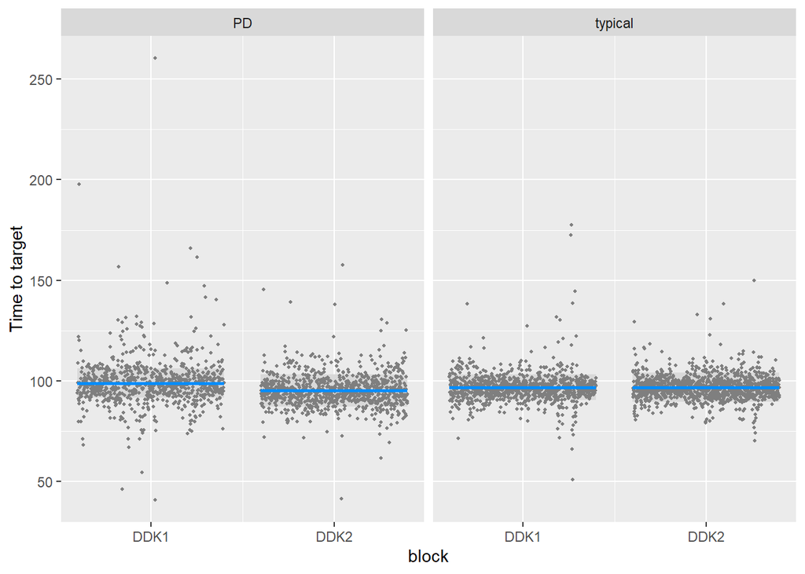

```r
visreg(m14, "block", "groupO", gg=TRUE, ylab="Time to target")
```

Add gender?

```r
summary(m15 <- bam(time2target ~ gender + block + block:groupO + s(rep.no, k= 9) + segO  + groupO + s(ID) + s(pace)  + s(block, subj, bs='re') + s(pace, subj, bs='fs', m =1) + s(pace, subj, by = segO, bs='fs', m =1) + s(ID, subj, bs='fs', m =1) + s(ID, subj, by = segO, bs='fs', m =1) + s(rep.no, subj, bs='fs', m =1) + s(rep.no, subj, by = segO, bs='fs', m =1), data = df, discrete = T, nthreads = 10))
```

```
##
## Family: gaussian
## Link function: identity
##
## Formula:
## time2target ~ gender + block + block:groupO + s(rep.no, k = 9) +
##     segO + groupO + s(ID) + s(pace) + s(block, subj, bs = "re") +
##     s(pace, subj, bs = "fs", m = 1) + s(pace, subj, by = segO,
##     bs = "fs", m = 1) + s(ID, subj, bs = "fs", m = 1) + s(ID,
##     subj, by = segO, bs = "fs", m = 1) + s(rep.no, subj, bs = "fs",
##     m = 1) + s(rep.no, subj, by = segO, bs = "fs", m = 1)
##
## Parametric coefficients:
##                         Estimate Std. Error t value Pr(>|t|)
## (Intercept)             100.9487     1.9472  51.842  < 2e-16 ***
## genderM                  -3.5494     1.7970  -1.975 0.048327 *
## blockDDK2                -4.2046     1.1975  -3.511 0.000452 ***
## segOK                     7.0994     1.5299   4.641 3.61e-06 ***
## segOT                     1.5349     0.8568   1.792 0.073294 .
## groupOtypical            -2.1536     1.8121  -1.188 0.234725
## blockDDK2:groupOtypical   3.7842     1.6109   2.349 0.018870 *
## ---
## Signif. codes:  0 '***' 0.001 '**' 0.01 '*' 0.05 '.' 0.1 ' ' 1
##
## Approximate significance of smooth terms:
##                            edf  Ref.df      F  p-value
## s(rep.no)            2.404e+00   2.858  4.922  0.00201 **
## s(ID)                7.397e+00   7.921  6.395  < 2e-16 ***
## s(pace)              6.446e+00   7.015 81.190  < 2e-16 ***
## s(block,subj)        2.868e+01  77.000  0.762  < 2e-16 ***
## s(pace,subj)         4.788e+01 295.000  0.393  < 2e-16 ***
## s(pace,subj):segOK   1.306e+01 119.000  0.144  < 2e-16 ***
## s(pace,subj):segOT   1.156e+01 128.000  0.109 9.40e-07 ***
## s(ID,subj)           1.181e+02 367.000  1.153  < 2e-16 ***
## s(ID,subj):segOK     9.447e+01 301.000  1.032  < 2e-16 ***
## s(ID,subj):segOT     4.339e+01 323.000  0.227  < 2e-16 ***
## s(rep.no,subj)       7.270e+01 375.000  0.377  < 2e-16 ***
## s(rep.no,subj):segOK 3.570e+01 326.000  0.157 6.53e-05 ***
## s(rep.no,subj):segOT 3.084e-04 346.000  0.000  0.11713
## ---
## Signif. codes:  0 '***' 0.001 '**' 0.01 '*' 0.05 '.' 0.1 ' ' 1
##
## R-sq.(adj) =  0.894   Deviance explained = 90.7%
## fREML =  14727  Scale est. = 86.463    n = 3892
```

Yes.

Per group?

```r
summary(m15Group <- bam(time2target ~ gender + gender:groupO + block + block:groupO + s(rep.no, k= 9) + segO  + groupO + s(ID) + s(pace)  + s(block, subj, bs='re') + s(pace, subj, bs='fs', m =1) + s(pace, subj, by = segO, bs='fs', m =1) + s(ID, subj, bs='fs', m =1) + s(ID, subj, by = segO, bs='fs', m =1) + s(rep.no, subj, bs='fs', m =1) + s(rep.no, subj, by = segO, bs='fs', m =1), data = df, discrete = T, nthreads = 10))
```

```
##
## Family: gaussian
## Link function: identity
##
## Formula:
## time2target ~ gender + gender:groupO + block + block:groupO +
##     s(rep.no, k = 9) + segO + groupO + s(ID) + s(pace) + s(block,
##     subj, bs = "re") + s(pace, subj, bs = "fs", m = 1) + s(pace,
##     subj, by = segO, bs = "fs", m = 1) + s(ID, subj, bs = "fs",
##     m = 1) + s(ID, subj, by = segO, bs = "fs", m = 1) + s(rep.no,
##     subj, bs = "fs", m = 1) + s(rep.no, subj, by = segO, bs = "fs",
##     m = 1)
##
## Parametric coefficients:
##                         Estimate Std. Error t value Pr(>|t|)
## (Intercept)             101.2553     2.4315  41.644  < 2e-16 ***
## genderM                  -3.9734     2.6726  -1.487 0.137191
## blockDDK2                -4.2195     1.2060  -3.499 0.000473 ***
## segOK                     7.1304     1.5334   4.650 3.44e-06 ***
## segOT                     1.5354     0.8616   1.782 0.074826 .
## groupOtypical            -2.7285     3.2102  -0.850 0.395413
## genderM:groupOtypical     0.7798     3.6085   0.216 0.828916
## blockDDK2:groupOtypical   3.7938     1.6221   2.339 0.019404 *
## ---
## Signif. codes:  0 '***' 0.001 '**' 0.01 '*' 0.05 '.' 0.1 ' ' 1
##
## Approximate significance of smooth terms:
##                            edf  Ref.df      F  p-value
## s(rep.no)            2.403e+00   2.857  4.919  0.00203 **
## s(ID)                7.400e+00   7.923  6.372  < 2e-16 ***
## s(pace)              6.430e+00   6.999 80.642  < 2e-16 ***
## s(block,subj)        2.868e+01  76.000  0.778  < 2e-16 ***
## s(pace,subj)         4.768e+01 295.000  0.390  < 2e-16 ***
## s(pace,subj):segOK   1.319e+01 119.000  0.146  < 2e-16 ***
## s(pace,subj):segOT   1.182e+01 128.000  0.112 7.73e-07 ***
## s(ID,subj)           1.181e+02 366.000  1.151  < 2e-16 ***
## s(ID,subj):segOK     9.429e+01 301.000  1.025  < 2e-16 ***
## s(ID,subj):segOT     4.340e+01 323.000  0.227  < 2e-16 ***
## s(rep.no,subj)       7.268e+01 374.000  0.377  < 2e-16 ***
## s(rep.no,subj):segOK 3.580e+01 326.000  0.158 6.28e-05 ***
## s(rep.no,subj):segOT 3.075e-04 346.000  0.000  0.11316
## ---
## Signif. codes:  0 '***' 0.001 '**' 0.01 '*' 0.05 '.' 0.1 ' ' 1
##
## R-sq.(adj) =  0.894   Deviance explained = 90.7%
## fREML =  14725  Scale est. = 86.419    n = 3892
```

No.

Add age?

```r
summary(m16 <- bam(time2target ~ age + gender + block + block:groupO + s(rep.no, k= 9) + segO  + groupO + s(ID) + s(pace)  + s(block, subj, bs='re') + s(pace, subj, bs='fs', m =1) + s(pace, subj, by = segO, bs='fs', m =1) + s(ID, subj, bs='fs', m =1) + s(ID, subj, by = segO, bs='fs', m =1) + s(rep.no, subj, bs='fs', m =1) + s(rep.no, subj, by = segO, bs='fs', m =1), data = df, discrete = T, nthreads = 10))
```

```
##
## Family: gaussian
## Link function: identity
##
## Formula:
## time2target ~ age + gender + block + block:groupO + s(rep.no,
##     k = 9) + segO + groupO + s(ID) + s(pace) + s(block, subj,
##     bs = "re") + s(pace, subj, bs = "fs", m = 1) + s(pace, subj,
##     by = segO, bs = "fs", m = 1) + s(ID, subj, bs = "fs", m = 1) +
##     s(ID, subj, by = segO, bs = "fs", m = 1) + s(rep.no, subj,
##     bs = "fs", m = 1) + s(rep.no, subj, by = segO, bs = "fs",
##     m = 1)
##
## Parametric coefficients:
##                         Estimate Std. Error t value Pr(>|t|)
## (Intercept)              95.3931     8.7168  10.944  < 2e-16 ***
## age                       0.0821     0.1254   0.655 0.512665
## genderM                  -3.5910     1.8081  -1.986 0.047110 *
## blockDDK2                -4.2168     1.2017  -3.509 0.000455 ***
## segOK                     7.1718     1.5388   4.661 3.27e-06 ***
## segOT                     1.5478     0.8634   1.793 0.073121 .
## groupOtypical            -2.1310     1.8215  -1.170 0.242113
## blockDDK2:groupOtypical   3.7972     1.6168   2.349 0.018902 *
## ---
## Signif. codes:  0 '***' 0.001 '**' 0.01 '*' 0.05 '.' 0.1 ' ' 1
##
## Approximate significance of smooth terms:
##                            edf  Ref.df      F  p-value
## s(rep.no)            2.404e+00   2.858  4.904  0.00206 **
## s(ID)                7.391e+00   7.916  6.473  < 2e-16 ***
## s(pace)              6.429e+00   6.995 79.731  < 2e-16 ***
## s(block,subj)        2.851e+01  76.000  0.769  < 2e-16 ***
## s(pace,subj)         4.816e+01 295.000  0.397  < 2e-16 ***
## s(pace,subj):segOK   1.325e+01 119.000  0.146  < 2e-16 ***
## s(pace,subj):segOT   1.271e+01 128.000  0.122 4.43e-07 ***
## s(ID,subj)           1.176e+02 365.000  1.135  < 2e-16 ***
## s(ID,subj):segOK     9.461e+01 297.000  1.047  < 2e-16 ***
## s(ID,subj):segOT     4.226e+01 323.000  0.216  < 2e-16 ***
## s(rep.no,subj)       7.277e+01 374.000  0.378  < 2e-16 ***
## s(rep.no,subj):segOK 3.575e+01 326.000  0.158 6.40e-05 ***
## s(rep.no,subj):segOT 3.132e-04 346.000  0.000  0.10059
## ---
## Signif. codes:  0 '***' 0.001 '**' 0.01 '*' 0.05 '.' 0.1 ' ' 1
##
## R-sq.(adj) =  0.894   Deviance explained = 90.7%
## fREML =  14728  Scale est. = 86.41     n = 3892
```

No.

Per group?

```r
summary(m16Group <- bam(time2target ~ gender + age + age:groupO + block + block:groupO + s(rep.no, k= 9) + segO  + groupO + s(ID) + s(pace) + s(pace, subj, bs='fs', m =1) + s(pace, subj, by = segO, bs='fs', m =1) + s(ID, subj, bs='fs', m =1) + s(block, subj, bs='re') + s(ID, subj, by = segO, bs='fs', m =1) + s(rep.no, subj, bs='fs', m =1) + s(rep.no, subj, by = segO, bs='fs', m =1), data = df, discrete = T, nthreads = 10))
```

```
##
## Family: gaussian
## Link function: identity
##
## Formula:
## time2target ~ gender + age + age:groupO + block + block:groupO +
##     s(rep.no, k = 9) + segO + groupO + s(ID) + s(pace) + s(pace,
##     subj, bs = "fs", m = 1) + s(pace, subj, by = segO, bs = "fs",
##     m = 1) + s(ID, subj, bs = "fs", m = 1) + s(block, subj, bs = "re") +
##     s(ID, subj, by = segO, bs = "fs", m = 1) + s(rep.no, subj,
##     bs = "fs", m = 1) + s(rep.no, subj, by = segO, bs = "fs",
##     m = 1)
##
## Parametric coefficients:
##                         Estimate Std. Error t value Pr(>|t|)
## (Intercept)              92.0643    12.1733   7.563 5.05e-14 ***
## genderM                  -3.7861     1.8899  -2.003 0.045223 *
## age                       0.1328     0.1806   0.736 0.462071
## blockDDK2                -4.2304     1.2053  -3.510 0.000454 ***
## segOK                     7.1831     1.5416   4.659 3.29e-06 ***
## segOT                     1.5448     0.8682   1.779 0.075276 .
## groupOtypical             4.7101    17.9014   0.263 0.792477
## age:groupOtypical        -0.1005     0.2616  -0.384 0.700839
## blockDDK2:groupOtypical   3.8021     1.6213   2.345 0.019083 *
## ---
## Signif. codes:  0 '***' 0.001 '**' 0.01 '*' 0.05 '.' 0.1 ' ' 1
##
## Approximate significance of smooth terms:
##                            edf  Ref.df      F  p-value
## s(rep.no)            2.403e+00   2.857  4.892   0.0021 **
## s(ID)                7.390e+00   7.916  6.478  < 2e-16 ***
## s(pace)              6.425e+00   6.990 78.603  < 2e-16 ***
## s(pace,subj)         4.809e+01 295.000  0.396  < 2e-16 ***
## s(pace,subj):segOK   1.321e+01 119.000  0.146  < 2e-16 ***
## s(pace,subj):segOT   1.323e+01 129.000  0.128  < 2e-16 ***
## s(ID,subj)           1.173e+02 365.000  1.132  < 2e-16 ***
## s(block,subj)        2.838e+01  76.000  0.767  < 2e-16 ***
## s(ID,subj):segOK     9.465e+01 297.000  1.048  < 2e-16 ***
## s(ID,subj):segOT     4.190e+01 323.000  0.213  < 2e-16 ***
## s(rep.no,subj)       7.280e+01 373.000  0.379  < 2e-16 ***
## s(rep.no,subj):segOK 3.575e+01 326.000  0.158 6.41e-05 ***
## s(rep.no,subj):segOT 3.127e-04 346.000  0.000   0.0991 .
## ---
## Signif. codes:  0 '***' 0.001 '**' 0.01 '*' 0.05 '.' 0.1 ' ' 1
##
## R-sq.(adj) =  0.894   Deviance explained = 90.7%
## fREML =  14728  Scale est. = 86.379    n = 3892
```

No.

Check once more if we need the interaction:

```r
summary(m18 <- bam(time2target ~ gender + block + block:groupO+ s(rep.no, k= 9) + segO + groupO + s(ID) + s(pace) + ti(ID, pace) + s(block, subj, bs='re') + s(pace, subj, bs='fs', m =1) + s(pace, subj, by = segO, bs='fs', m =1) + s(ID, subj, bs='fs', m =1) + s(ID, subj, by = segO, bs='fs', m =1) + s(rep.no, subj, bs='fs', m =1) + s(rep.no, subj, by = segO, bs='fs', m =1), data = df, discrete = T, nthreads = 10))
```

```
##
## Family: gaussian
## Link function: identity
##
## Formula:
## time2target ~ gender + block + block:groupO + s(rep.no, k = 9) +
##     segO + groupO + s(ID) + s(pace) + ti(ID, pace) + s(block,
##     subj, bs = "re") + s(pace, subj, bs = "fs", m = 1) + s(pace,
##     subj, by = segO, bs = "fs", m = 1) + s(ID, subj, bs = "fs",
##     m = 1) + s(ID, subj, by = segO, bs = "fs", m = 1) + s(rep.no,
##     subj, bs = "fs", m = 1) + s(rep.no, subj, by = segO, bs = "fs",
##     m = 1)
##
## Parametric coefficients:
##                         Estimate Std. Error t value Pr(>|t|)
## (Intercept)             101.2730     1.9762  51.246  < 2e-16 ***
## genderM                  -3.1798     1.7778  -1.789 0.073767 .
## blockDDK2                -4.1853     1.2360  -3.386 0.000717 ***
## segOK                     6.7168     1.5112   4.445 9.08e-06 ***
## segOT                     1.3783     0.8076   1.707 0.087954 .
## groupOtypical            -1.9783     1.7907  -1.105 0.269346
## blockDDK2:groupOtypical   3.6308     1.6601   2.187 0.028803 *
## ---
## Signif. codes:  0 '***' 0.001 '**' 0.01 '*' 0.05 '.' 0.1 ' ' 1
##
## Approximate significance of smooth terms:
##                            edf  Ref.df      F  p-value
## s(rep.no)            2.415e+00   2.873  5.016  0.00175 **
## s(ID)                7.347e+00   7.874  4.865 5.73e-06 ***
## s(pace)              6.455e+00   7.062 70.385  < 2e-16 ***
## ti(ID,pace)          5.512e+00   6.446  1.307  0.35744
## s(block,subj)        3.073e+01  77.000  0.841  < 2e-16 ***
## s(pace,subj)         4.268e+01 295.000  0.323  < 2e-16 ***
## s(pace,subj):segOK   1.301e+01 119.000  0.142 1.13e-06 ***
## s(pace,subj):segOT   2.370e+00 128.000  0.019 8.07e-05 ***
## s(ID,subj)           1.170e+02 367.000  1.131  < 2e-16 ***
## s(ID,subj):segOK     9.349e+01 301.000  0.988  < 2e-16 ***
## s(ID,subj):segOT     5.069e+01 323.000  0.311  < 2e-16 ***
## s(rep.no,subj)       7.187e+01 375.000  0.371  < 2e-16 ***
## s(rep.no,subj):segOK 3.533e+01 326.000  0.155 7.41e-05 ***
## s(rep.no,subj):segOT 4.320e-04 346.000  0.000  0.16871
## ---
## Signif. codes:  0 '***' 0.001 '**' 0.01 '*' 0.05 '.' 0.1 ' ' 1
##
## R-sq.(adj) =  0.894   Deviance explained = 90.7%
## fREML =  14722  Scale est. = 86.608    n = 3892
```

No.

Check once more if we need separate smooths over ID for each group:

```r
summary(m19 <- bam(time2target ~ gender + block + block:groupO + groupO + s(rep.no, k= 9) + segO + s(ID) + s(ID, by = groupO) + s(pace) + ti(ID, pace) + s(block, subj, bs='re') + s(pace, subj, bs='fs', m =1) + s(pace, subj, by = segO, bs='fs', m =1) + s(ID, subj, bs='fs', m =1) + s(ID, subj, by = segO, bs='fs', m =1) + s(rep.no, subj, bs='fs', m =1) + s(rep.no, subj, by = segO, bs='fs', m =1), data = df, discrete = T, nthreads = 10))
```

```
##
## Family: gaussian
## Link function: identity
##
## Formula:
## time2target ~ gender + block + block:groupO + groupO + s(rep.no,
##     k = 9) + segO + s(ID) + s(ID, by = groupO) + s(pace) + ti(ID,
##     pace) + s(block, subj, bs = "re") + s(pace, subj, bs = "fs",
##     m = 1) + s(pace, subj, by = segO, bs = "fs", m = 1) + s(ID,
##     subj, bs = "fs", m = 1) + s(ID, subj, by = segO, bs = "fs",
##     m = 1) + s(rep.no, subj, bs = "fs", m = 1) + s(rep.no, subj,
##     by = segO, bs = "fs", m = 1)
##
## Parametric coefficients:
##                         Estimate Std. Error t value Pr(>|t|)
## (Intercept)             101.1335     1.9996  50.577  < 2e-16 ***
## genderM                  -3.2700     1.7888  -1.828 0.067634 .
## blockDDK2                -4.1821     1.2330  -3.392 0.000703 ***
## groupOtypical            -2.0548     1.7979  -1.143 0.253165
## segOK                     6.7553     1.5164   4.455 8.67e-06 ***
## segOT                     1.4050     0.8184   1.717 0.086121 .
## blockDDK2:groupOtypical   3.6285     1.6559   2.191 0.028504 *
## ---
## Signif. codes:  0 '***' 0.001 '**' 0.01 '*' 0.05 '.' 0.1 ' ' 1
##
## Approximate significance of smooth terms:
##                            edf  Ref.df      F  p-value
## s(rep.no)            2.415e+00   2.873  5.004 0.001771 **
## s(ID)                7.376e+00   7.898  3.618 0.000224 ***
## s(ID):groupOtypical  1.000e+00   1.000  0.566 0.451790
## s(pace)              6.447e+00   7.054 70.498  < 2e-16 ***
## ti(ID,pace)          5.556e+00   6.493  1.292 0.373925
## s(block,subj)        3.049e+01  77.000  0.832  < 2e-16 ***
## s(pace,subj)         4.239e+01 295.000  0.316  < 2e-16 ***
## s(pace,subj):segOK   1.320e+01 119.000  0.144 9.00e-07 ***
## s(pace,subj):segOT   3.876e+00 129.000  0.032 3.33e-05 ***
## s(ID,subj)           1.167e+02 367.000  1.127  < 2e-16 ***
## s(ID,subj):segOK     9.322e+01 301.000  0.982  < 2e-16 ***
## s(ID,subj):segOT     4.996e+01 323.000  0.298  < 2e-16 ***
## s(rep.no,subj)       7.171e+01 375.000  0.369  < 2e-16 ***
## s(rep.no,subj):segOK 3.535e+01 326.000  0.155 7.31e-05 ***
## s(rep.no,subj):segOT 3.203e-04 346.000  0.000 0.116129
## ---
## Signif. codes:  0 '***' 0.001 '**' 0.01 '*' 0.05 '.' 0.1 ' ' 1
##
## R-sq.(adj) =  0.894   Deviance explained = 90.7%
## fREML =  14719  Scale est. = 86.564    n = 3892
```

No.

# 6 Check assumptions

Check assumptions:

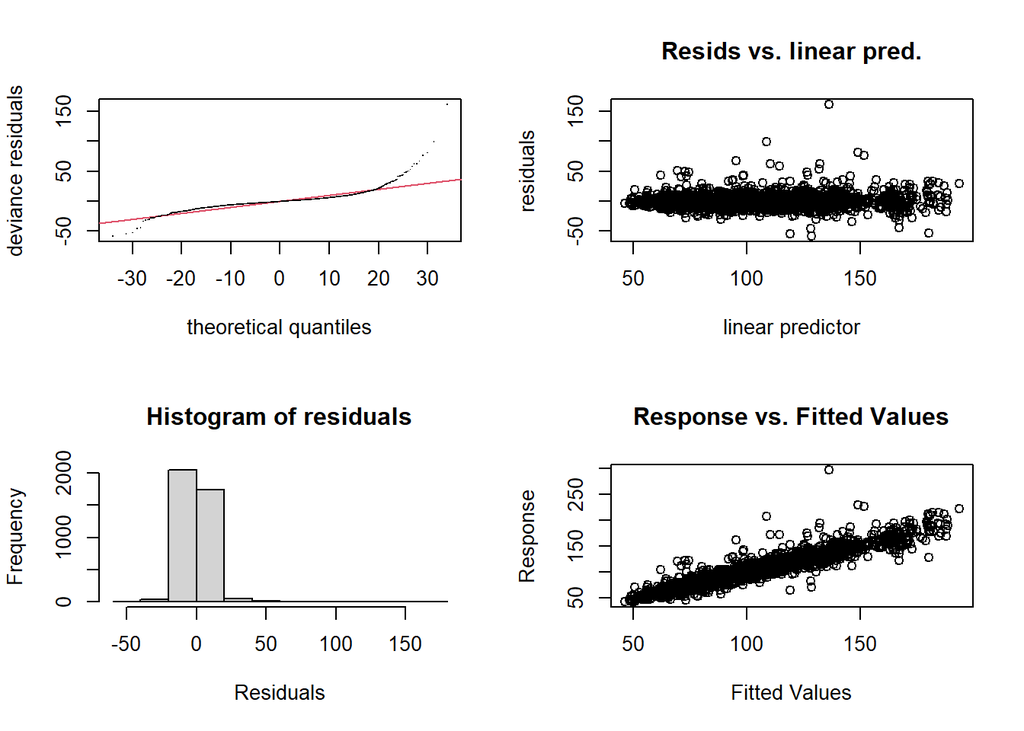

[output not shown]

[output cut: 97 more lines]

```
## s(rep.no)            8.00e+00 2.40e+00    1.02   0.870
## s(ID)                9.00e+00 7.40e+00    0.96   0.005 **
## s(pace)              9.00e+00 6.45e+00    1.05   1.000
## s(block,subj)        8.40e+01 2.87e+01      NA      NA
## s(pace,subj)         3.78e+02 4.79e+01    1.05   1.000
## s(pace,subj):segOK   3.78e+02 1.31e+01    1.05   0.995
## s(pace,subj):segOT   3.78e+02 1.16e+01    1.05   1.000
## s(ID,subj)           3.78e+02 1.18e+02    0.96   0.005 **
## s(ID,subj):segOK     3.78e+02 9.45e+01    0.96   0.005 **
## s(ID,subj):segOT     3.78e+02 4.34e+01    0.96   0.010 **
## s(rep.no,subj)       3.78e+02 7.27e+01    1.02   0.780
## s(rep.no,subj):segOK 3.78e+02 3.57e+01    1.02   0.800
## s(rep.no,subj):segOT 3.78e+02 3.08e-04    1.02   0.835
## ---
## Signif. codes:  0 '***' 0.001 '**' 0.01 '*' 0.05 '.' 0.1 ' ' 1
```

```r
gam.check(m15)
```

Right skewed.

Use gamma distribution and check assumptions once more:

```r
summary(m15log <- bam(time2target ~ gender + block + block:groupO + s(rep.no, k= 9) + segO  + groupO + s(ID) + s(pace) + s(block, subj, bs='re') + s(pace, subj, bs='fs', m =1) + s(pace, subj, by = segO, bs='fs', m =1) + s(ID, subj, bs='fs', m =1) + s(ID, subj, by = segO, bs='fs', m =1) + s(rep.no, subj, bs='fs', m =1) + s(rep.no, subj, by = segO, bs='fs', m =1), data = df, discrete = T, nthreads = 10, family = Gamma(link=log)))
```

```
##
## Family: Gamma
## Link function: log
##
## Formula:
## time2target ~ gender + block + block:groupO + s(rep.no, k = 9) +
##     segO + groupO + s(ID) + s(pace) + s(block, subj, bs = "re") +
##     s(pace, subj, bs = "fs", m = 1) + s(pace, subj, by = segO,
##     bs = "fs", m = 1) + s(ID, subj, bs = "fs", m = 1) + s(ID,
##     subj, by = segO, bs = "fs", m = 1) + s(rep.no, subj, bs = "fs",
##     m = 1) + s(rep.no, subj, by = segO, bs = "fs", m = 1)
##
## Parametric coefficients:
##                         Estimate Std. Error t value Pr(>|t|)
## (Intercept)              4.55672    0.02130 213.922  < 2e-16 ***
## genderM                 -0.03286    0.01977  -1.662  0.09667 .
## blockDDK2               -0.03372    0.01236  -2.728  0.00641 **
## segOK                    0.08044    0.01729   4.651 3.43e-06 ***
## segOT                    0.01965    0.01063   1.848  0.06464 .
## groupOtypical           -0.01488    0.01965  -0.757  0.44909
## blockDDK2:groupOtypical  0.02891    0.01663   1.738  0.08225 .
## ---
## Signif. codes:  0 '***' 0.001 '**' 0.01 '*' 0.05 '.' 0.1 ' ' 1
##
## Approximate significance of smooth terms:
##                            edf  Ref.df      F p-value
## s(rep.no)            2.322e+00   2.785  5.102 0.00195 **
## s(ID)                7.987e+00   8.356 15.887 < 2e-16 ***
## s(pace)              4.362e+00   4.810 83.739 < 2e-16 ***
## s(block,subj)        2.853e+01  77.000  0.775 < 2e-16 ***
## s(pace,subj)         4.866e+01 295.000  0.404 < 2e-16 ***
## s(pace,subj):segOK   2.529e+01 119.000  0.345 < 2e-16 ***
## s(pace,subj):segOT   3.189e+01 128.000  0.448 < 2e-16 ***
## s(ID,subj)           1.303e+02 367.000  1.468 < 2e-16 ***
## s(ID,subj):segOK     9.236e+01 301.000  0.972 < 2e-16 ***
## s(ID,subj):segOT     3.903e+01 323.000  0.186 < 2e-16 ***
## s(rep.no,subj)       5.335e+01 375.000  0.233 < 2e-16 ***
## s(rep.no,subj):segOK 5.310e+01 326.000  0.290 < 2e-16 ***
## s(rep.no,subj):segOT 4.988e-04 346.000  0.000 0.12489
## ---
## Signif. codes:  0 '***' 0.001 '**' 0.01 '*' 0.05 '.' 0.1 ' ' 1
##
## R-sq.(adj) =  0.896   Deviance explained = 92.3%
## fREML =  -3456  Scale est. = 0.0076786  n = 3892
```

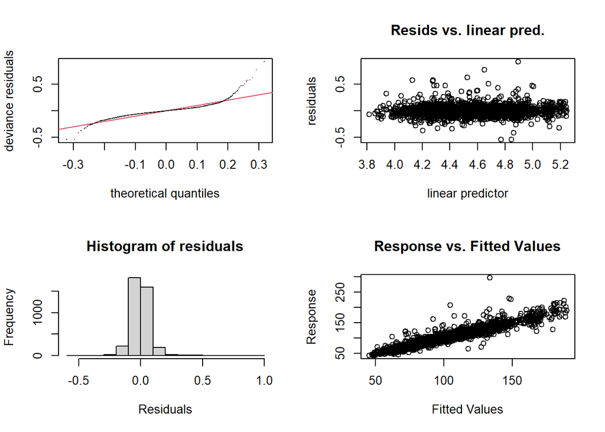

[output not shown]

[output cut: 97 more lines]

```
## s(rep.no)            8.00e+00 2.32e+00    1.02    0.84
## s(ID)                9.00e+00 7.99e+00    0.95  <2e-16 ***
## s(pace)              9.00e+00 4.36e+00    1.05    1.00
## s(block,subj)        8.40e+01 2.85e+01      NA      NA
## s(pace,subj)         3.78e+02 4.87e+01    1.05    1.00
## s(pace,subj):segOK   3.78e+02 2.53e+01    1.05    1.00
## s(pace,subj):segOT   3.78e+02 3.19e+01    1.05    1.00
## s(ID,subj)           3.78e+02 1.30e+02    0.95  <2e-16 ***
## s(ID,subj):segOK     3.78e+02 9.24e+01    0.95  <2e-16 ***
## s(ID,subj):segOT     3.78e+02 3.90e+01    0.95  <2e-16 ***
## s(rep.no,subj)       3.78e+02 5.34e+01    1.02    0.84
## s(rep.no,subj):segOK 3.78e+02 5.31e+01    1.02    0.85
## s(rep.no,subj):segOT 3.78e+02 4.99e-04    1.02    0.84
## ---
## Signif. codes:  0 '***' 0.001 '**' 0.01 '*' 0.05 '.' 0.1 ' ' 1
```

```r
gam.check(m15log)
```

Still doesn’t look great.

Trim the gamma model:

```r
df3 <- df[abs(scale(resid(m15log))) < 2.5, ] # trim model
(1 - (nrow(df3))/nrow(df)) * 100
```

```
## [1] 2.261048
```

We now have a new trimmed dataframe: df3.

Refit gamma model with trimmed data:

```r
summary(m15log_Trim <- bam(time2target ~ gender + block + block:groupO + s(rep.no, k= 9) + segO  + groupO + s(ID) + s(pace) + s(block, subj, bs='re') + s(pace, subj, bs='fs', m =1) + s(pace, subj, by = segO, bs='fs', m =1) + s(ID, subj, bs='fs', m =1) + s(ID, subj, by = segO, bs='fs', m =1) + s(rep.no, subj, bs='fs', m =1) + s(rep.no, subj, by = segO, bs='fs', m =1), data = df3, discrete = T, nthreads = 10, family = Gamma(link=log)))
```

```
##
## Family: Gamma
## Link function: log
##
## Formula:
## time2target ~ gender + block + block:groupO + s(rep.no, k = 9) +
##     segO + groupO + s(ID) + s(pace) + s(block, subj, bs = "re") +
##     s(pace, subj, bs = "fs", m = 1) + s(pace, subj, by = segO,
##     bs = "fs", m = 1) + s(ID, subj, bs = "fs", m = 1) + s(ID,
##     subj, by = segO, bs = "fs", m = 1) + s(rep.no, subj, bs = "fs",
##     m = 1) + s(rep.no, subj, by = segO, bs = "fs", m = 1)
##
## Parametric coefficients:
##                         Estimate Std. Error t value Pr(>|t|)
## (Intercept)              4.54422    0.02409 188.621  < 2e-16 ***
## genderM                 -0.02757    0.02298  -1.200   0.2303
## blockDDK2               -0.01946    0.01106  -1.760   0.0785 .
## segOK                    0.10642    0.01663   6.401 1.77e-10 ***
## segOT                    0.03025    0.01211   2.498   0.0125 *
## groupOtypical           -0.01114    0.02188  -0.509   0.6108
## blockDDK2:groupOtypical  0.01090    0.01489   0.732   0.4644
## ---
## Signif. codes:  0 '***' 0.001 '**' 0.01 '*' 0.05 '.' 0.1 ' ' 1
##
## Approximate significance of smooth terms:
##                          edf  Ref.df      F  p-value
## s(rep.no)              1.901   2.264  3.687 0.020051 *
## s(ID)                  7.778   8.162 19.435  < 2e-16 ***
## s(pace)                5.022   5.403 51.571  < 2e-16 ***
## s(block,subj)         28.010  77.000  0.889  < 2e-16 ***
## s(pace,subj)          71.367 305.000  0.923  < 2e-16 ***
## s(pace,subj):segOK    32.283 119.000  0.507  < 2e-16 ***
## s(pace,subj):segOT    45.146 128.000  0.838  < 2e-16 ***
## s(ID,subj)           128.708 369.000  1.274  < 2e-16 ***
## s(ID,subj):segOK      98.220 304.000  1.312  < 2e-16 ***
## s(ID,subj):segOT      61.937 324.000  0.391  < 2e-16 ***
## s(rep.no,subj)        53.830 371.000  0.240  < 2e-16 ***
## s(rep.no,subj):segOK  34.224 325.000  0.145 0.000177 ***
## s(rep.no,subj):segOT  14.087 346.000  0.047 0.012978 *
## ---
## Signif. codes:  0 '***' 0.001 '**' 0.01 '*' 0.05 '.' 0.1 ' ' 1
##
## R-sq.(adj) =  0.947   Deviance explained =   96%
## fREML = -4491.1  Scale est. = 0.0036423  n = 3804
```

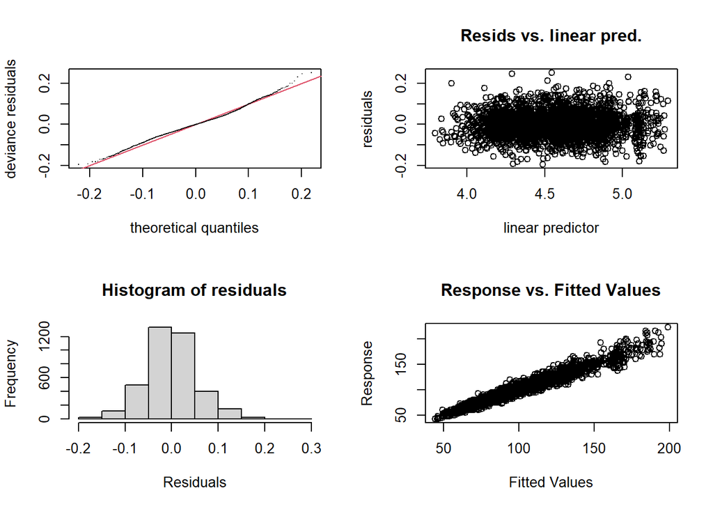

[output not shown]

[output cut: 95 more lines]

```
##
##                          k'    edf k-index p-value
## s(rep.no)              8.00   1.90    1.02    0.97
## s(ID)                  9.00   7.78    1.00    0.39
## s(pace)                9.00   5.02    1.08    1.00
## s(block,subj)         84.00  28.01      NA      NA
## s(pace,subj)         378.00  71.37    1.08    1.00
## s(pace,subj):segOK   378.00  32.28    1.08    1.00
## s(pace,subj):segOT   378.00  45.15    1.08    1.00
## s(ID,subj)           378.00 128.71    1.00    0.34
## s(ID,subj):segOK     378.00  98.22    1.00    0.40
## s(ID,subj):segOT     378.00  61.94    1.00    0.36
## s(rep.no,subj)       378.00  53.83    1.02    0.91
## s(rep.no,subj):segOK 378.00  34.22    1.02    0.96
## s(rep.no,subj):segOT 378.00  14.09    1.02    0.92
```

```r
gam.check(m15log_Trim)
```

Improves, but block and gender do not reach significance anymore.

Fit gamma model without block, gender and group, using the original data.

```r
summary(m16log <- bam(time2target ~  s(rep.no, k= 9) + segO + s(ID) + s(pace) + s(pace, subj, bs='fs', m =1) + s(pace, subj, by = segO, bs='fs', m =1) + s(ID, subj, bs='fs', m =1) + s(ID, subj, by = segO, bs='fs', m =1) + s(rep.no, subj, bs='fs', m =1) + s(rep.no, subj, by = segO, bs='fs', m =1), data = df, discrete = T, nthreads = 10, family = Gamma(link=log)))
```

```
##
## Family: Gamma
## Link function: log
##
## Formula:
## time2target ~ s(rep.no, k = 9) + segO + s(ID) + s(pace) + s(pace,
##     subj, bs = "fs", m = 1) + s(pace, subj, by = segO, bs = "fs",
##     m = 1) + s(ID, subj, bs = "fs", m = 1) + s(ID, subj, by = segO,
##     bs = "fs", m = 1) + s(rep.no, subj, bs = "fs", m = 1) + s(rep.no,
##     subj, by = segO, bs = "fs", m = 1)
##
## Parametric coefficients:
##             Estimate Std. Error t value Pr(>|t|)
## (Intercept)  4.51819    0.01099 411.140  < 2e-16 ***
## segOK        0.07460    0.01740   4.288 1.86e-05 ***
## segOT        0.02164    0.01129   1.917   0.0554 .
## ---
## Signif. codes:  0 '***' 0.001 '**' 0.01 '*' 0.05 '.' 0.1 ' ' 1
##
## Approximate significance of smooth terms:
##                            edf  Ref.df      F p-value
## s(rep.no)            2.315e+00   2.775  5.341 0.00145 **
## s(ID)                7.921e+00   8.314 15.389 < 2e-16 ***
## s(pace)              4.397e+00   4.816 73.417 < 2e-16 ***
## s(pace,subj)         6.449e+01 297.000  0.569 < 2e-16 ***
## s(pace,subj):segOK   2.529e+01 120.000  0.327 < 2e-16 ***
## s(pace,subj):segOT   3.633e+01 129.000  0.504 < 2e-16 ***
## s(ID,subj)           1.298e+02 370.000  1.350 < 2e-16 ***
## s(ID,subj):segOK     9.258e+01 302.000  0.954 < 2e-16 ***
## s(ID,subj):segOT     3.950e+01 324.000  0.189 < 2e-16 ***
## s(rep.no,subj)       5.529e+01 377.000  0.246 < 2e-16 ***
## s(rep.no,subj):segOK 5.000e+01 326.000  0.260 < 2e-16 ***
## s(rep.no,subj):segOT 6.044e-04 346.000  0.000 0.04718 *
## ---
## Signif. codes:  0 '***' 0.001 '**' 0.01 '*' 0.05 '.' 0.1 ' ' 1
##
## R-sq.(adj) =  0.895   Deviance explained = 92.2%
## fREML = -3453.9  Scale est. = 0.0077926  n = 3892
```

No surprises.

Trim the new model:

```r
df4 <- df[abs(scale(resid(m16log))) < 2.5, ] # trim model
(1 - (nrow(df4))/nrow(df)) * 100
```

```
## [1] 2.338129
```

We now have a new trimmed dataframe: df4.

Fit gamma model without trial.no using the trimmed data:

```r
summary(m16log_newTrim2 <- bam(time2target ~  s(rep.no, k= 9) + segO + s(ID) + s(pace) + s(pace, subj, bs='fs', m =1) + s(pace, subj, by = segO, bs='fs', m =1) + s(ID, subj, bs='fs', m =1) + s(ID, subj, by = segO, bs='fs', m =1) + s(rep.no, subj, bs='fs', m =1) + s(rep.no, subj, by = segO, bs='fs', m =1), data = df4, discrete = T, nthreads = 10, family = Gamma(link=log)))
```

```
##
## Family: Gamma
## Link function: log
##
## Formula:
## time2target ~ s(rep.no, k = 9) + segO + s(ID) + s(pace) + s(pace,
##     subj, bs = "fs", m = 1) + s(pace, subj, by = segO, bs = "fs",
##     m = 1) + s(ID, subj, bs = "fs", m = 1) + s(ID, subj, by = segO,
##     bs = "fs", m = 1) + s(rep.no, subj, bs = "fs", m = 1) + s(rep.no,
##     subj, by = segO, bs = "fs", m = 1)
##
## Parametric coefficients:
##             Estimate Std. Error t value Pr(>|t|)
## (Intercept)  4.51462    0.01204 375.011  < 2e-16 ***
## segOK        0.10094    0.01681   6.003 2.15e-09 ***
## segOT        0.02877    0.01237   2.326   0.0201 *
## ---
## Signif. codes:  0 '***' 0.001 '**' 0.01 '*' 0.05 '.' 0.1 ' ' 1
##
## Approximate significance of smooth terms:
##                          edf  Ref.df      F  p-value
## s(rep.no)              1.928   2.293  4.075 0.012427 *
## s(ID)                  7.631   8.041 20.989  < 2e-16 ***
## s(pace)                5.283   5.671 48.386  < 2e-16 ***
## s(pace,subj)          79.882 312.000  0.922  < 2e-16 ***
## s(pace,subj):segOK    34.020 120.000  0.524  < 2e-16 ***
## s(pace,subj):segOT    48.228 129.000  0.913  < 2e-16 ***
## s(ID,subj)           131.649 371.000  1.292  < 2e-16 ***
## s(ID,subj):segOK      98.786 308.000  1.304  < 2e-16 ***
## s(ID,subj):segOT      60.683 325.000  0.371  < 2e-16 ***
## s(rep.no,subj)        55.620 373.000  0.245  < 2e-16 ***
## s(rep.no,subj):segOK  34.636 325.000  0.147 0.000121 ***
## s(rep.no,subj):segOT  17.541 346.000  0.060 0.005664 **
## ---
## Signif. codes:  0 '***' 0.001 '**' 0.01 '*' 0.05 '.' 0.1 ' ' 1
##
## R-sq.(adj) =  0.946   Deviance explained =   96%
## fREML = -4501.5  Scale est. = 0.0036539  n = 3801
```

No surprises.

Check assumptions once more:

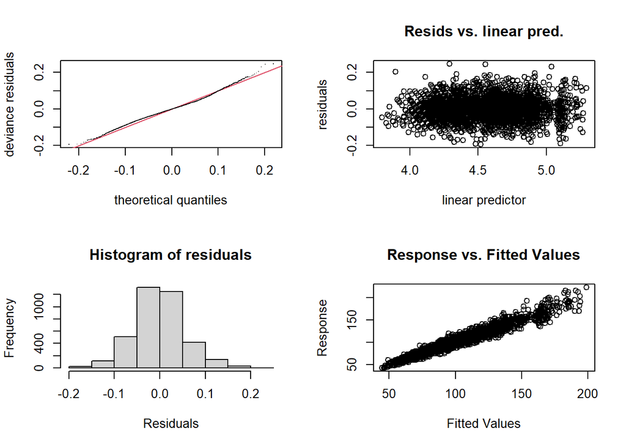

[output not shown]

[output cut: 89 more lines]

```
## indicate that k is too low, especially if edf is close to k'.
##
##                          k'    edf k-index p-value
## s(rep.no)              8.00   1.93    1.02    0.92
## s(ID)                  9.00   7.63    1.00    0.47
## s(pace)                9.00   5.28    1.07    1.00
## s(pace,subj)         378.00  79.88    1.07    1.00
## s(pace,subj):segOK   378.00  34.02    1.07    1.00
## s(pace,subj):segOT   378.00  48.23    1.07    1.00
## s(ID,subj)           378.00 131.65    1.00    0.48
## s(ID,subj):segOK     378.00  98.79    1.00    0.46
## s(ID,subj):segOT     378.00  60.68    1.00    0.48
## s(rep.no,subj)       378.00  55.62    1.02    0.96
## s(rep.no,subj):segOK 378.00  34.64    1.02    0.92
## s(rep.no,subj):segOT 378.00  17.54    1.02    0.94
```

```r
gam.check(m16log_newTrim2)
```

Looks OK.

# 7 Final plots

Visualize:

```
## Summary:
##  * segO : factor; set to the value(s): P.
##  * rep.no : numeric predictor; with 30 values ranging from 1.000000 to 10.000000.
##  * ID : numeric predictor; set to the value(s): 3.35608113669383.
##  * pace : numeric predictor; set to the value(s): 4.59183673469388.
##  * subj : factor; set to the value(s): CTRL06. (Might be canceled as random effect, check below.)
##  * NOTE : The following random effects columns are canceled: s(pace,subj),s(pace,subj):segOK,s(pace,subj):segOT,s(ID,subj),s(ID,subj):segOK,s(ID,subj):segOT,s(rep.no,subj),s(rep.no,subj):segOK,s(rep.no,subj):segOT
##
```

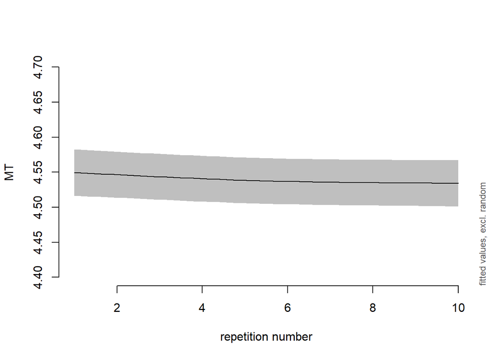

```r
plot_smooth(m16log_newTrim2, view="rep.no", rug=F, ylim=c(4.4,4.7), ylab = "MT", xlab = "repetition number")
```

```
## Summary:
##  * segO : factor; set to the value(s): P.
##  * rep.no : numeric predictor; set to the value(s): 5.
##  * ID : numeric predictor; with 30 values ranging from 0.306751 to 5.911636.
##  * pace : numeric predictor; set to the value(s): 4.59183673469388.
##  * subj : factor; set to the value(s): CTRL06. (Might be canceled as random effect, check below.)
##  * NOTE : The following random effects columns are canceled: s(pace,subj),s(pace,subj):segOK,s(pace,subj):segOT,s(ID,subj),s(ID,subj):segOK,s(ID,subj):segOT,s(rep.no,subj),s(rep.no,subj):segOK,s(rep.no,subj):segOT
##
```

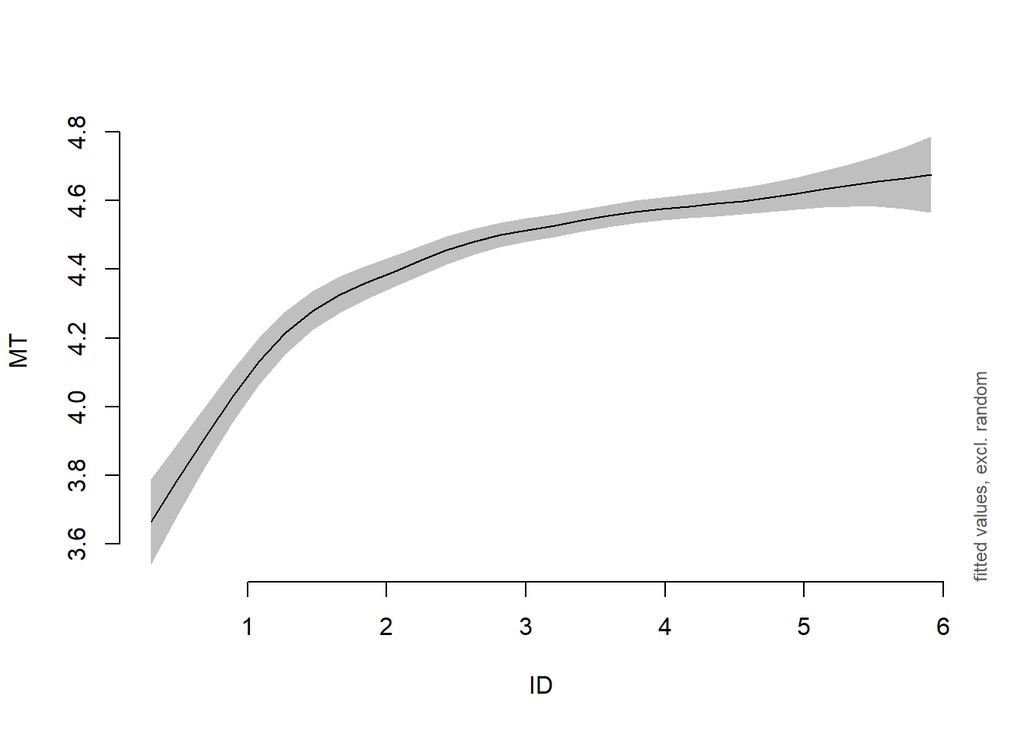

```r
plot_smooth(m16log_newTrim2, view="ID", rug=F, ylab = "MT", xlab = "ID")
```

```
## Summary:
##  * segO : factor; set to the value(s): P.
##  * rep.no : numeric predictor; set to the value(s): 5.
##  * ID : numeric predictor; set to the value(s): 3.35608113669383.
##  * pace : numeric predictor; with 30 values ranging from 2.352941 to 8.571429.
##  * subj : factor; set to the value(s): CTRL06. (Might be canceled as random effect, check below.)
##  * NOTE : The following random effects columns are canceled: s(pace,subj),s(pace,subj):segOK,s(pace,subj):segOT,s(ID,subj),s(ID,subj):segOK,s(ID,subj):segOT,s(rep.no,subj),s(rep.no,subj):segOK,s(rep.no,subj):segOT
##
```

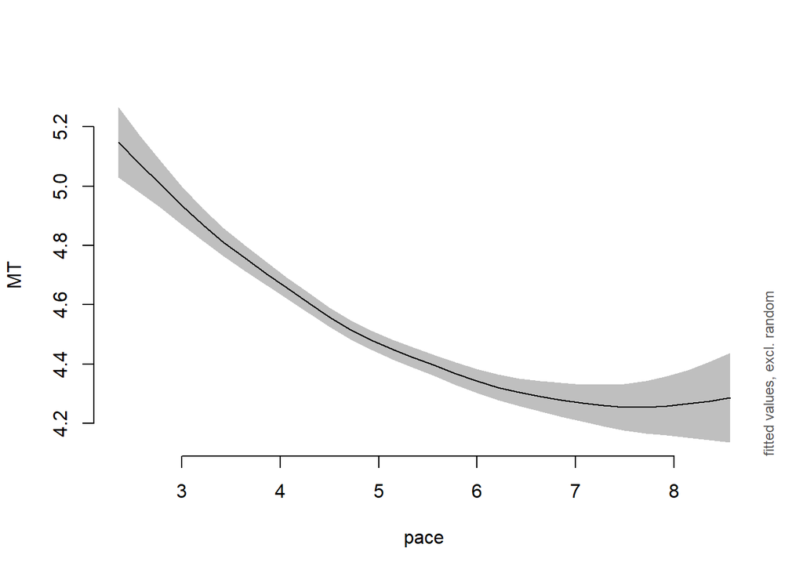

```r
plot_smooth(m16log_newTrim2, view="pace", rug=F, ylab = "MT", xlab = "pace")
```

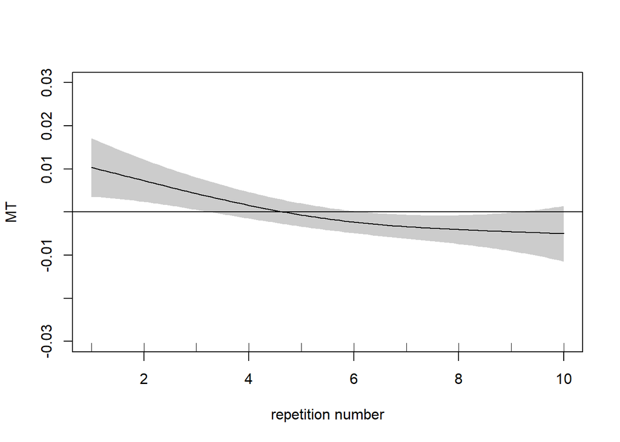

```r
plot(m16log_newTrim2, select = 1, ylim=c(-0.03,0.03), shade  = T, ylab = "MT", xlab = "repetition number")
abline(h=0)
```

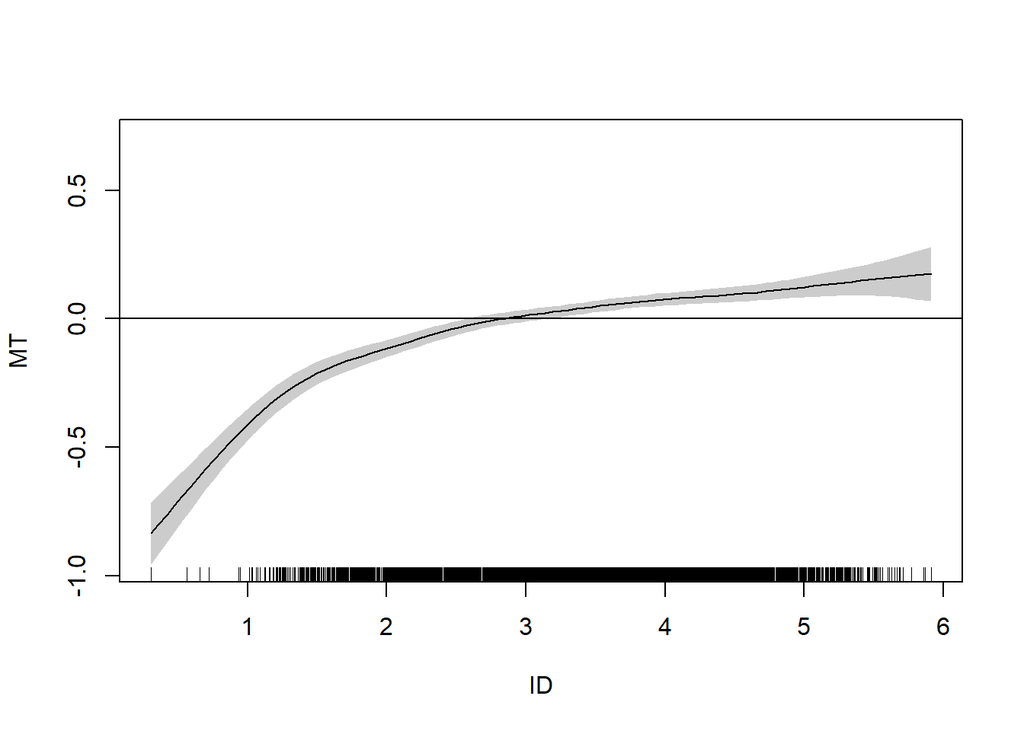

```r
plot(m16log_newTrim2, select = 2, shade  = T, ylab = "MT", xlab = "ID")
abline(h=0)
```

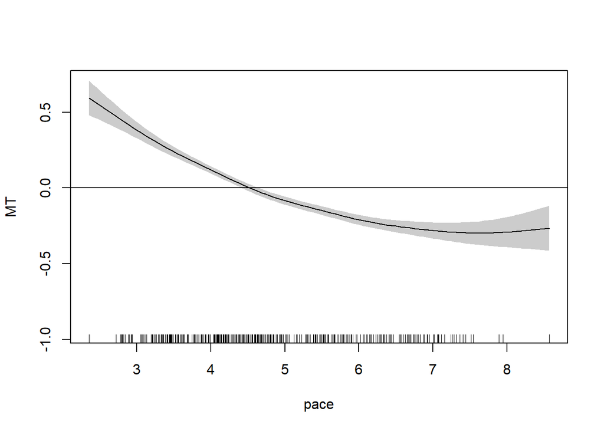

```r
plot(m16log_newTrim2, select = 3, shade  = T, ylab = "MT", xlab = "pace")
abline(h=0)
```

MT decreases with an increase in repetition number, MT increases with an increase in ID and MT decreases with a higher pace.

# 8 PD severity

## 8.1 Together with typical

Add years since diagnosis?

```r
summary(mPD_1 <- bam(time2target ~  s(diagnosis) + s(rep.no, k= 9) + segO + s(ID) + s(pace) + s(pace, subj, bs='fs', m =1) + s(pace, subj, by = segO, bs='fs', m =1) + s(ID, subj, bs='fs', m =1) + s(ID, subj, by = segO, bs='fs', m =1) + s(rep.no, subj, bs='fs', m =1) + s(rep.no, subj, by = segO, bs='fs', m =1), data = df4, discrete = T, nthreads = 10, family = Gamma(link=log)))
```

```
##
## Family: Gamma
## Link function: log
##
## Formula:
## time2target ~ s(diagnosis) + s(rep.no, k = 9) + segO + s(ID) +
##     s(pace) + s(pace, subj, bs = "fs", m = 1) + s(pace, subj,
##     by = segO, bs = "fs", m = 1) + s(ID, subj, bs = "fs", m = 1) +
##     s(ID, subj, by = segO, bs = "fs", m = 1) + s(rep.no, subj,
##     bs = "fs", m = 1) + s(rep.no, subj, by = segO, bs = "fs",
##     m = 1)
##
## Parametric coefficients:
##             Estimate Std. Error t value Pr(>|t|)
## (Intercept)  4.52321    0.01580 286.222  < 2e-16 ***
## segOK        0.10247    0.01680   6.101 1.18e-09 ***
## segOT        0.03071    0.01229   2.498   0.0125 *
## ---
## Signif. codes:  0 '***' 0.001 '**' 0.01 '*' 0.05 '.' 0.1 ' ' 1
##
## Approximate significance of smooth terms:
##                          edf  Ref.df      F  p-value
## s(diagnosis)           2.796   2.836  2.372 0.043951 *
## s(rep.no)              1.920   2.283  3.998 0.013586 *
## s(ID)                  7.633   8.045 21.598  < 2e-16 ***
## s(pace)                5.217   5.604 45.966  < 2e-16 ***
## s(pace,subj)          78.503 310.000  0.913  < 2e-16 ***
## s(pace,subj):segOK    34.503 120.000  0.543  < 2e-16 ***
## s(pace,subj):segOT    47.391 129.000  0.893  < 2e-16 ***
## s(ID,subj)           129.777 370.000  1.247  < 2e-16 ***
## s(ID,subj):segOK      98.717 308.000  1.310  < 2e-16 ***
## s(ID,subj):segOT      61.789 325.000  0.382  < 2e-16 ***
## s(rep.no,subj)        55.471 372.000  0.247  < 2e-16 ***
## s(rep.no,subj):segOK  34.800 325.000  0.148 0.000114 ***
## s(rep.no,subj):segOT  17.330 346.000  0.060 0.005906 **
## ---
## Signif. codes:  0 '***' 0.001 '**' 0.01 '*' 0.05 '.' 0.1 ' ' 1
##
## R-sq.(adj) =  0.946   Deviance explained =   96%
## fREML = -4500.6  Scale est. = 0.0036515  n = 3801
```

Yes.

Visualize:

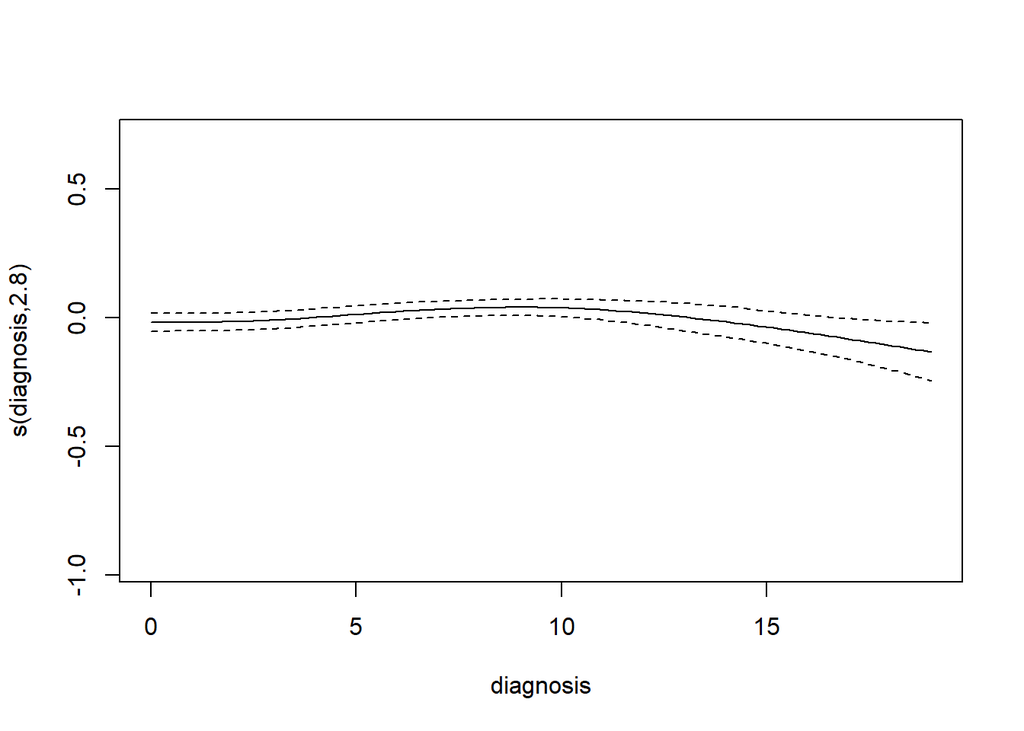

```r
plot(mPD_1, select = 1, rug = F)
```

UPDRS total score?

```r
summary(mPD_2 <- bam(time2target ~  s(total_UPDRS) + s(rep.no, k= 9) + segO + s(ID) + s(pace) + s(pace, subj, bs='fs', m =1) + s(pace, subj, by = segO, bs='fs', m =1) + s(ID, subj, bs='fs', m =1) + s(ID, subj, by = segO, bs='fs', m =1) + s(rep.no, subj, bs='fs', m =1) + s(rep.no, subj, by = segO, bs='fs', m =1), data = df4, discrete = T, nthreads = 10, family = Gamma(link=log)))
```

```
##
## Family: Gamma
## Link function: log
##
## Formula:
## time2target ~ s(total_UPDRS) + s(rep.no, k = 9) + segO + s(ID) +
##     s(pace) + s(pace, subj, bs = "fs", m = 1) + s(pace, subj,
##     by = segO, bs = "fs", m = 1) + s(ID, subj, bs = "fs", m = 1) +
##     s(ID, subj, by = segO, bs = "fs", m = 1) + s(rep.no, subj,
##     bs = "fs", m = 1) + s(rep.no, subj, by = segO, bs = "fs",
##     m = 1)
##
## Parametric coefficients:
##             Estimate Std. Error t value Pr(>|t|)
## (Intercept)  4.52078    0.01510 299.400  < 2e-16 ***
## segOK        0.10089    0.01685   5.988 2.36e-09 ***
## segOT        0.02785    0.01248   2.231   0.0257 *
## ---
## Signif. codes:  0 '***' 0.001 '**' 0.01 '*' 0.05 '.' 0.1 ' ' 1
##
## Approximate significance of smooth terms:
##                          edf  Ref.df      F  p-value
## s(total_UPDRS)         1.946   1.974  3.350 0.050574 .
## s(rep.no)              1.923   2.287  4.201 0.013181 *
## s(ID)                  7.636   8.050 22.063  < 2e-16 ***
## s(pace)                5.222   5.606 47.438  < 2e-16 ***
## s(pace,subj)          79.853 311.000  0.939  < 2e-16 ***
## s(pace,subj):segOK    34.467 121.000  0.530  < 2e-16 ***
## s(pace,subj):segOT    48.571 129.000  0.915  < 2e-16 ***
## s(ID,subj)           128.080 370.000  1.229  < 2e-16 ***
## s(ID,subj):segOK      98.954 308.000  1.321  < 2e-16 ***
## s(ID,subj):segOT      62.258 325.000  0.389  < 2e-16 ***
## s(rep.no,subj)        55.181 372.000  0.245  < 2e-16 ***
## s(rep.no,subj):segOK  35.037 325.000  0.150 0.000108 ***
## s(rep.no,subj):segOT  17.164 346.000  0.059 0.006248 **
## ---
## Signif. codes:  0 '***' 0.001 '**' 0.01 '*' 0.05 '.' 0.1 ' ' 1
##
## R-sq.(adj) =  0.947   Deviance explained =   96%
## fREML =  -4500  Scale est. = 0.0036507  n = 3801
```

No.

Visualize:

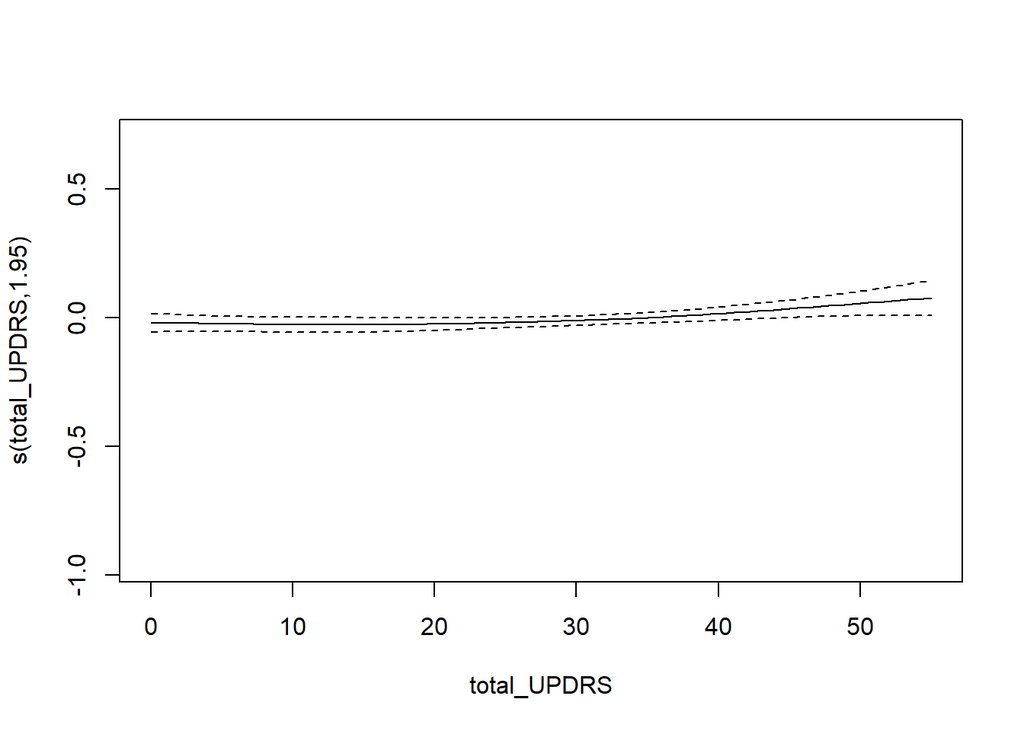

```r
plot(mPD_2, select = 1, rug = F)
```

UPDRS motor score?

```r
summary(mPD_3 <- bam(time2target ~  s(motor_UPDRS) + s(rep.no, k= 9) + segO + s(ID) + s(pace) + s(pace, subj, bs='fs', m =1) + s(pace, subj, by = segO, bs='fs', m =1) + s(ID, subj, bs='fs', m =1) + s(ID, subj, by = segO, bs='fs', m =1) + s(rep.no, subj, bs='fs', m =1) + s(rep.no, subj, by = segO, bs='fs', m =1), data = df4, discrete = T, nthreads = 10, family = Gamma(link=log)))
```

```
##
## Family: Gamma
## Link function: log
##
## Formula:
## time2target ~ s(motor_UPDRS) + s(rep.no, k = 9) + segO + s(ID) +
##     s(pace) + s(pace, subj, bs = "fs", m = 1) + s(pace, subj,
##     by = segO, bs = "fs", m = 1) + s(ID, subj, bs = "fs", m = 1) +
##     s(ID, subj, by = segO, bs = "fs", m = 1) + s(rep.no, subj,
##     bs = "fs", m = 1) + s(rep.no, subj, by = segO, bs = "fs",
##     m = 1)
##
## Parametric coefficients:
##             Estimate Std. Error t value Pr(>|t|)
## (Intercept)  4.53377    0.01601 283.258  < 2e-16 ***
## segOK        0.10291    0.01694   6.075 1.38e-09 ***
## segOT        0.02971    0.01256   2.365   0.0181 *
## ---
## Signif. codes:  0 '***' 0.001 '**' 0.01 '*' 0.05 '.' 0.1 ' ' 1
##
## Approximate significance of smooth terms:
##                          edf  Ref.df      F  p-value
## s(motor_UPDRS)         2.319   2.358  4.426 0.013285 *
## s(rep.no)              1.922   2.285  3.943 0.014388 *
## s(ID)                  7.653   8.070 23.442  < 2e-16 ***
## s(pace)                5.079   5.454 46.633  < 2e-16 ***
## s(pace,subj)          80.870 310.000  0.971  < 2e-16 ***
## s(pace,subj):segOK    34.597 120.000  0.537  < 2e-16 ***
## s(pace,subj):segOT    48.888 129.000  0.932  < 2e-16 ***
## s(ID,subj)           125.512 370.000  1.142  < 2e-16 ***
## s(ID,subj):segOK      99.060 308.000  1.325  < 2e-16 ***
## s(ID,subj):segOT      61.786 325.000  0.382  < 2e-16 ***
## s(rep.no,subj)        55.666 372.000  0.248  < 2e-16 ***
## s(rep.no,subj):segOK  34.809 325.000  0.148 0.000114 ***
## s(rep.no,subj):segOT  17.612 346.000  0.061 0.005557 **
## ---
## Signif. codes:  0 '***' 0.001 '**' 0.01 '*' 0.05 '.' 0.1 ' ' 1
##
## R-sq.(adj) =  0.947   Deviance explained =   96%
## fREML = -4501.6  Scale est. = 0.0036497  n = 3801
```

Yes.

Visualize:

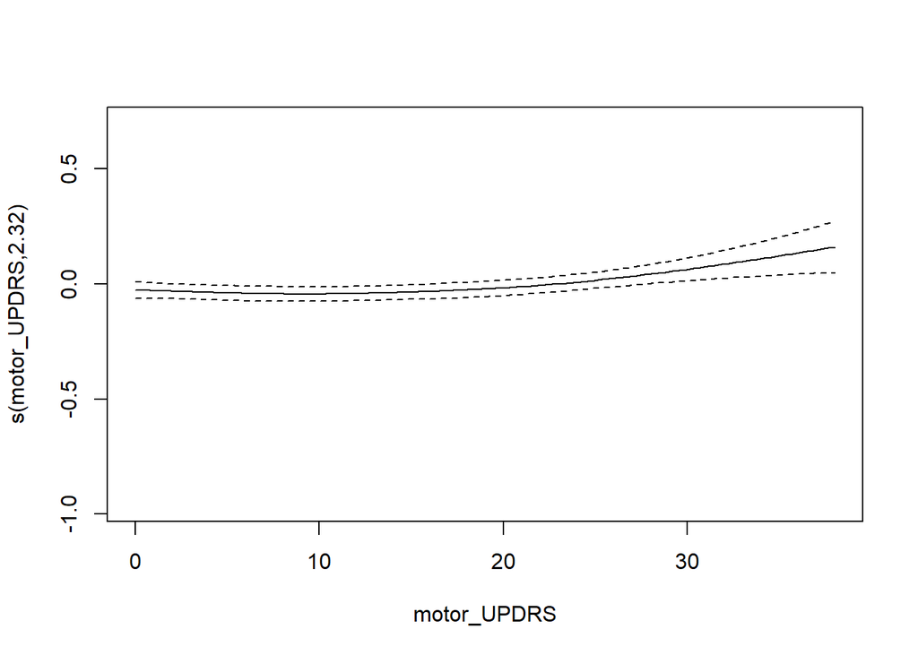

```r
plot(mPD_3, select = 1, rug = F)
```

Tremor score?

```r
summary(mPD_4 <- bam(time2target ~  s(tremor, k = 6) + s(rep.no, k= 9) + segO + s(ID) + s(pace) + s(pace, subj, bs='fs', m =1) + s(pace, subj, by = segO, bs='fs', m =1) + s(ID, subj, bs='fs', m =1) + s(ID, subj, by = segO, bs='fs', m =1) + s(rep.no, subj, bs='fs', m =1) + s(rep.no, subj, by = segO, bs='fs', m =1), data = df4, discrete = T, nthreads = 10, family = Gamma(link=log)))
```

```
##
## Family: Gamma
## Link function: log
##
## Formula:
## time2target ~ s(tremor, k = 6) + s(rep.no, k = 9) + segO + s(ID) +
##     s(pace) + s(pace, subj, bs = "fs", m = 1) + s(pace, subj,
##     by = segO, bs = "fs", m = 1) + s(ID, subj, bs = "fs", m = 1) +
##     s(ID, subj, by = segO, bs = "fs", m = 1) + s(rep.no, subj,
##     bs = "fs", m = 1) + s(rep.no, subj, by = segO, bs = "fs",
##     m = 1)
##
## Parametric coefficients:
##             Estimate Std. Error t value Pr(>|t|)
## (Intercept)  4.50289    0.02148 209.661  < 2e-16 ***
## segOK        0.10070    0.01677   6.006 2.11e-09 ***
## segOT        0.02929    0.01247   2.349   0.0189 *
## ---
## Signif. codes:  0 '***' 0.001 '**' 0.01 '*' 0.05 '.' 0.1 ' ' 1
##
## Approximate significance of smooth terms:
##                          edf  Ref.df      F  p-value
## s(tremor)              1.000   1.000  0.633 0.426251
## s(rep.no)              1.926   2.291  4.045 0.012846 *
## s(ID)                  7.632   8.042 20.996  < 2e-16 ***
## s(pace)                5.296   5.684 47.819  < 2e-16 ***
## s(pace,subj)          79.379 311.000  0.920  < 2e-16 ***
## s(pace,subj):segOK    33.714 120.000  0.516  < 2e-16 ***
## s(pace,subj):segOT    48.544 129.000  0.924  < 2e-16 ***
## s(ID,subj)           131.514 371.000  1.290  < 2e-16 ***
## s(ID,subj):segOK      98.863 308.000  1.303  < 2e-16 ***
## s(ID,subj):segOT      60.587 326.000  0.369  < 2e-16 ***
## s(rep.no,subj)        55.790 372.000  0.246  < 2e-16 ***
## s(rep.no,subj):segOK  34.625 325.000  0.147 0.000124 ***
## s(rep.no,subj):segOT  17.288 346.000  0.059 0.006062 **
## ---
## Signif. codes:  0 '***' 0.001 '**' 0.01 '*' 0.05 '.' 0.1 ' ' 1
##
## R-sq.(adj) =  0.946   Deviance explained =   96%
## fREML =  -4499  Scale est. = 0.0036521  n = 3801
```

No.

UPDRS akinetic score?

```r
summary(mPD_5 <- bam(time2target ~  s(akinetic, k = 5) + s(rep.no, k= 9) + segO  + s(ID) + s(pace) + s(pace, subj, bs='fs', m =1) + s(pace, subj, by = segO, bs='fs', m =1) + s(ID, subj, bs='fs', m =1) + s(ID, subj, by = segO, bs='fs', m =1) + s(rep.no, subj, bs='fs', m =1) + s(rep.no, subj, by = segO, bs='fs', m =1), data = df4, discrete = T, nthreads = 10, family = Gamma(link=log)))
```

```
##
## Family: Gamma
## Link function: log
##
## Formula:
## time2target ~ s(akinetic, k = 5) + s(rep.no, k = 9) + segO +
##     s(ID) + s(pace) + s(pace, subj, bs = "fs", m = 1) + s(pace,
##     subj, by = segO, bs = "fs", m = 1) + s(ID, subj, bs = "fs",
##     m = 1) + s(ID, subj, by = segO, bs = "fs", m = 1) + s(rep.no,
##     subj, bs = "fs", m = 1) + s(rep.no, subj, by = segO, bs = "fs",
##     m = 1)
##
## Parametric coefficients:
##             Estimate Std. Error t value Pr(>|t|)
## (Intercept)  4.52703    0.01768 256.118  < 2e-16 ***
## segOK        0.10162    0.01689   6.017 1.98e-09 ***
## segOT        0.02827    0.01252   2.258    0.024 *
## ---
## Signif. codes:  0 '***' 0.001 '**' 0.01 '*' 0.05 '.' 0.1 ' ' 1
##
## Approximate significance of smooth terms:
##                          edf  Ref.df      F  p-value
## s(akinetic)            1.000   1.000  1.741 0.187061
## s(rep.no)              1.924   2.288  4.170 0.013641 *
## s(ID)                  7.639   8.053 22.091  < 2e-16 ***
## s(pace)                5.208   5.589 46.150  < 2e-16 ***
## s(pace,subj)          80.737 311.000  0.943  < 2e-16 ***
## s(pace,subj):segOK    33.911 120.000  0.520  < 2e-16 ***
## s(pace,subj):segOT    48.665 129.000  0.921  < 2e-16 ***
## s(ID,subj)           128.571 370.000  1.199  < 2e-16 ***
## s(ID,subj):segOK      99.183 308.000  1.321  < 2e-16 ***
## s(ID,subj):segOT      61.340 325.000  0.379  < 2e-16 ***
## s(rep.no,subj)        56.122 372.000  0.248  < 2e-16 ***
## s(rep.no,subj):segOK  34.647 325.000  0.147 0.000123 ***
## s(rep.no,subj):segOT  17.435 346.000  0.060 0.005854 **
## ---
## Signif. codes:  0 '***' 0.001 '**' 0.01 '*' 0.05 '.' 0.1 ' ' 1
##
## R-sq.(adj) =  0.947   Deviance explained =   96%
## fREML =  -4499  Scale est. = 0.0036504  n = 3801
```

No.

## 8.2 Interaction with ID?

Add years since diagnosis?

```r
summary(mPD_1te <- bam(time2target ~  s(rep.no, k= 9) + segO + te(ID, diagnosis) + s(pace) + s(pace, subj, bs='fs', m =1) + s(pace, subj, by = segO, bs='fs', m =1) + s(ID, subj, bs='fs', m =1) + s(ID, subj, by = segO, bs='fs', m =1) + s(rep.no, subj, bs='fs', m =1) + s(rep.no, subj, by = segO, bs='fs', m =1), data = df4, discrete = T, nthreads = 10, family = Gamma(link=log)))
```

```
##
## Family: Gamma
## Link function: log
##
## Formula:
## time2target ~ s(rep.no, k = 9) + segO + te(ID, diagnosis) + s(pace) +
##     s(pace, subj, bs = "fs", m = 1) + s(pace, subj, by = segO,
##     bs = "fs", m = 1) + s(ID, subj, bs = "fs", m = 1) + s(ID,
##     subj, by = segO, bs = "fs", m = 1) + s(rep.no, subj, bs = "fs",
##     m = 1) + s(rep.no, subj, by = segO, bs = "fs", m = 1)
##
## Parametric coefficients:
##             Estimate Std. Error t value Pr(>|t|)
## (Intercept)  4.52430    0.01587 285.110  < 2e-16 ***
## segOK        0.10069    0.01698   5.928 3.38e-09 ***
## segOT        0.02895    0.01240   2.336   0.0196 *
## ---
## Signif. codes:  0 '***' 0.001 '**' 0.01 '*' 0.05 '.' 0.1 ' ' 1
##
## Approximate significance of smooth terms:
##                          edf  Ref.df      F  p-value
## s(rep.no)              1.934   2.298  3.649 0.019523 *
## te(ID,diagnosis)      14.432  15.026  9.807  < 2e-16 ***
## s(pace)                5.370   5.760 44.401  < 2e-16 ***
## s(pace,subj)          79.083 311.000  0.926  < 2e-16 ***
## s(pace,subj):segOK    34.632 120.000  0.550  < 2e-16 ***
## s(pace,subj):segOT    46.810 129.000  0.870  < 2e-16 ***
## s(ID,subj)           123.331 370.000  1.050  < 2e-16 ***
## s(ID,subj):segOK      99.242 304.000  1.345  < 2e-16 ***
## s(ID,subj):segOT      63.642 324.000  0.406  < 2e-16 ***
## s(rep.no,subj)        57.384 372.000  0.258  < 2e-16 ***
## s(rep.no,subj):segOK  35.213 325.000  0.150 0.000111 ***
## s(rep.no,subj):segOT  16.270 346.000  0.055 0.007516 **
## ---
## Signif. codes:  0 '***' 0.001 '**' 0.01 '*' 0.05 '.' 0.1 ' ' 1
##
## R-sq.(adj) =  0.946   Deviance explained =   96%
## fREML = -4495.9  Scale est. = 0.0036591  n = 3801
```

Yes.

UPDRS total score?

```r
summary(mPD_2te <- bam(time2target ~  s(rep.no, k= 9) + segO + te(ID, total_UPDRS) + s(pace) + s(pace, subj, bs='fs', m =1) + s(pace, subj, by = segO, bs='fs', m =1) + s(ID, subj, bs='fs', m =1) + s(ID, subj, by = segO, bs='fs', m =1) + s(rep.no, subj, bs='fs', m =1) + s(rep.no, subj, by = segO, bs='fs', m =1), data = df4, discrete = T, nthreads = 10, family = Gamma(link=log)))
```

```
##
## Family: Gamma
## Link function: log
##
## Formula:
## time2target ~ s(rep.no, k = 9) + segO + te(ID, total_UPDRS) +
##     s(pace) + s(pace, subj, bs = "fs", m = 1) + s(pace, subj,
##     by = segO, bs = "fs", m = 1) + s(ID, subj, bs = "fs", m = 1) +
##     s(ID, subj, by = segO, bs = "fs", m = 1) + s(rep.no, subj,
##     bs = "fs", m = 1) + s(rep.no, subj, by = segO, bs = "fs",
##     m = 1)
##
## Parametric coefficients:
##             Estimate Std. Error t value Pr(>|t|)
## (Intercept)  4.51869    0.01538 293.889  < 2e-16 ***
## segOK        0.10020    0.01701   5.891 4.24e-09 ***
## segOT        0.02738    0.01240   2.207   0.0274 *
## ---
## Signif. codes:  0 '***' 0.001 '**' 0.01 '*' 0.05 '.' 0.1 ' ' 1
##
## Approximate significance of smooth terms:
##                          edf  Ref.df      F  p-value
## s(rep.no)              1.924   2.286  3.848   0.0160 *
## te(ID,total_UPDRS)    11.483  11.888 12.091  < 2e-16 ***
## s(pace)                5.399   5.788 45.607  < 2e-16 ***
## s(pace,subj)          79.848 310.000  0.944  < 2e-16 ***
## s(pace,subj):segOK    34.586 120.000  0.539  < 2e-16 ***
## s(pace,subj):segOT    48.056 128.000  0.910  < 2e-16 ***
## s(ID,subj)           126.712 370.000  1.126  < 2e-16 ***
## s(ID,subj):segOK      99.298 305.000  1.314  < 2e-16 ***
## s(ID,subj):segOT      61.188 324.000  0.378  < 2e-16 ***
## s(rep.no,subj)        56.401 372.000  0.252  < 2e-16 ***
## s(rep.no,subj):segOK  35.820 325.000  0.153 9.19e-05 ***
## s(rep.no,subj):segOT  16.900 346.000  0.058   0.0065 **
## ---
## Signif. codes:  0 '***' 0.001 '**' 0.01 '*' 0.05 '.' 0.1 ' ' 1
##
## R-sq.(adj) =  0.947   Deviance explained =   96%
## fREML = -4497.4  Scale est. = 0.0036549  n = 3801
```

Yes.

UPDRS motor score?

```r
summary(mPD_3te <- bam(time2target ~  s(rep.no, k= 9) + segO + te(ID, motor_UPDRS) + s(pace) + s(pace, subj, bs='fs', m =1) + s(pace, subj, by = segO, bs='fs', m =1) + s(ID, subj, bs='fs', m =1) + s(ID, subj, by = segO, bs='fs', m =1) + s(rep.no, subj, bs='fs', m =1) + s(rep.no, subj, by = segO, bs='fs', m =1), data = df4, discrete = T, nthreads = 10, family = Gamma(link=log)))
```

```
##
## Family: Gamma
## Link function: log
##
## Formula:
## time2target ~ s(rep.no, k = 9) + segO + te(ID, motor_UPDRS) +
##     s(pace) + s(pace, subj, bs = "fs", m = 1) + s(pace, subj,
##     by = segO, bs = "fs", m = 1) + s(ID, subj, bs = "fs", m = 1) +
##     s(ID, subj, by = segO, bs = "fs", m = 1) + s(rep.no, subj,
##     bs = "fs", m = 1) + s(rep.no, subj, by = segO, bs = "fs",
##     m = 1)
##
## Parametric coefficients:
##             Estimate Std. Error t value Pr(>|t|)
## (Intercept)  4.53406    0.01606 282.351  < 2e-16 ***
## segOK        0.10169    0.01704   5.967 2.68e-09 ***
## segOT        0.02916    0.01249   2.334   0.0197 *
## ---
## Signif. codes:  0 '***' 0.001 '**' 0.01 '*' 0.05 '.' 0.1 ' ' 1
##
## Approximate significance of smooth terms:
##                          edf  Ref.df      F  p-value
## s(rep.no)              1.945   2.312  3.726  0.01774 *
## te(ID,motor_UPDRS)    12.944  13.438 11.172  < 2e-16 ***
## s(pace)                5.356   5.740 46.275  < 2e-16 ***
## s(pace,subj)          81.242 309.000  0.997  < 2e-16 ***
## s(pace,subj):segOK    34.717 120.000  0.542  < 2e-16 ***
## s(pace,subj):segOT    48.319 128.000  0.923  < 2e-16 ***
## s(ID,subj)           119.729 370.000  1.005  < 2e-16 ***
## s(ID,subj):segOK      99.869 305.000  1.342  < 2e-16 ***
## s(ID,subj):segOT      62.706 325.000  0.392  < 2e-16 ***
## s(rep.no,subj)        56.625 372.000  0.255  < 2e-16 ***
## s(rep.no,subj):segOK  35.588 325.000  0.152 9.92e-05 ***
## s(rep.no,subj):segOT  16.746 346.000  0.057  0.00673 **
## ---
## Signif. codes:  0 '***' 0.001 '**' 0.01 '*' 0.05 '.' 0.1 ' ' 1
##
## R-sq.(adj) =  0.947   Deviance explained =   96%
## fREML = -4500.5  Scale est. = 0.0036573  n = 3801
```

Yes.

Tremor score?

```r
summary(mPD_4te <- bam(time2target ~  s(rep.no, k= 9) + segO + te(ID, tremor) + s(pace) + s(pace, subj, bs='fs', m =1) + s(pace, subj, by = segO, bs='fs', m =1) + s(ID, subj, bs='fs', m =1) + s(ID, subj, by = segO, bs='fs', m =1) + s(rep.no, subj, bs='fs', m =1) + s(rep.no, subj, by = segO, bs='fs', m =1), data = df4, discrete = T, nthreads = 10, family = Gamma(link=log)))
```

```
##
## Family: Gamma
## Link function: log
##
## Formula:
## time2target ~ s(rep.no, k = 9) + segO + te(ID, tremor) + s(pace) +
##     s(pace, subj, bs = "fs", m = 1) + s(pace, subj, by = segO,
##     bs = "fs", m = 1) + s(ID, subj, bs = "fs", m = 1) + s(ID,
##     subj, by = segO, bs = "fs", m = 1) + s(rep.no, subj, bs = "fs",
##     m = 1) + s(rep.no, subj, by = segO, bs = "fs", m = 1)
##
## Parametric coefficients:
##             Estimate Std. Error t value Pr(>|t|)
## (Intercept)  4.50218    0.02436 184.851  < 2e-16 ***
## segOK        0.09989    0.01692   5.902 3.97e-09 ***
## segOT        0.02909    0.01251   2.325   0.0201 *
## ---
## Signif. codes:  0 '***' 0.001 '**' 0.01 '*' 0.05 '.' 0.1 ' ' 1
##
## Approximate significance of smooth terms:
##                          edf  Ref.df      F  p-value
## s(rep.no)              1.937   2.302  3.764 0.017207 *
## te(ID,tremor)         11.421  11.853 11.099  < 2e-16 ***
## s(pace)                5.363   5.752 45.393  < 2e-16 ***
## s(pace,subj)          79.173 311.000  0.912  < 2e-16 ***
## s(pace,subj):segOK    33.955 119.000  0.526  < 2e-16 ***
## s(pace,subj):segOT    48.237 129.000  0.909  < 2e-16 ***
## s(ID,subj)           127.407 370.000  1.117  < 2e-16 ***
## s(ID,subj):segOK      99.237 306.000  1.315  < 2e-16 ***
## s(ID,subj):segOT      60.731 325.000  0.374  < 2e-16 ***
## s(rep.no,subj)        57.553 372.000  0.257  < 2e-16 ***
## s(rep.no,subj):segOK  35.072 325.000  0.149 0.000117 ***
## s(rep.no,subj):segOT  16.749 346.000  0.057 0.006719 **
## ---
## Signif. codes:  0 '***' 0.001 '**' 0.01 '*' 0.05 '.' 0.1 ' ' 1
##
## R-sq.(adj) =  0.946   Deviance explained =   96%
## fREML = -4494.9  Scale est. = 0.0036627  n = 3801
```

Yes.

UPDRS akinetic score?

```r
summary(mPD_5te <- bam(time2target ~  s(rep.no, k= 9) + segO + te(ID, akinetic) + s(pace) + s(pace, subj, bs='fs', m =1) + s(pace, subj, by = segO, bs='fs', m =1) + s(ID, subj, bs='fs', m =1) + s(ID, subj, by = segO, bs='fs', m =1) + s(rep.no, subj, bs='fs', m =1) + s(rep.no, subj, by = segO, bs='fs', m =1), data = df4, discrete = T, nthreads = 10, family = Gamma(link=log)))
```

```
##
## Family: Gamma
## Link function: log
##
## Formula:
## time2target ~ s(rep.no, k = 9) + segO + te(ID, akinetic) + s(pace) +
##     s(pace, subj, bs = "fs", m = 1) + s(pace, subj, by = segO,
##     bs = "fs", m = 1) + s(ID, subj, bs = "fs", m = 1) + s(ID,
##     subj, by = segO, bs = "fs", m = 1) + s(rep.no, subj, bs = "fs",
##     m = 1) + s(rep.no, subj, by = segO, bs = "fs", m = 1)
##
## Parametric coefficients:
##             Estimate Std. Error t value Pr(>|t|)
## (Intercept)  4.51555    0.02458 183.715  < 2e-16 ***
## segOK        0.10331    0.01701   6.072 1.41e-09 ***
## segOT        0.02989    0.01246   2.399   0.0165 *
## ---
## Signif. codes:  0 '***' 0.001 '**' 0.01 '*' 0.05 '.' 0.1 ' ' 1
##
## Approximate significance of smooth terms:
##                          edf  Ref.df      F  p-value
## s(rep.no)              1.949   2.316  3.868  0.01531 *
## te(ID,akinetic)       15.806  16.364 11.561  < 2e-16 ***
## s(pace)                5.538   5.930 44.575  < 2e-16 ***
## s(pace,subj)          80.074 311.000  0.952  < 2e-16 ***
## s(pace,subj):segOK    34.774 120.000  0.546  < 2e-16 ***
## s(pace,subj):segOT    48.271 129.000  0.914  < 2e-16 ***
## s(ID,subj)           113.114 371.000  0.871  < 2e-16 ***
## s(ID,subj):segOK     100.350 307.000  1.387  < 2e-16 ***
## s(ID,subj):segOT      64.014 325.000  0.402  < 2e-16 ***
## s(rep.no,subj)        56.729 372.000  0.254  < 2e-16 ***
## s(rep.no,subj):segOK  35.618 325.000  0.152 9.45e-05 ***
## s(rep.no,subj):segOT  17.547 346.000  0.060  0.00556 **
## ---
## Signif. codes:  0 '***' 0.001 '**' 0.01 '*' 0.05 '.' 0.1 ' ' 1
##
## R-sq.(adj) =  0.947   Deviance explained =   96%
## fREML = -4505.1  Scale est. = 0.00365   n = 3801
```

Yes.

## 8.3 Separate main effect from interaction

Add years since diagnosis?

```r
summary(mPD1ti <- bam(time2target ~  ti(diagnosis, ID) + s(diagnosis) + s(rep.no, k= 9) + segO + s(ID) + s(pace) + s(pace, subj, bs='fs', m =1) + s(pace, subj, by = segO, bs='fs', m =1) + s(ID, subj, bs='fs', m =1) + s(ID, subj, by = segO, bs='fs', m =1) + s(rep.no, subj, bs='fs', m =1) + s(rep.no, subj, by = segO, bs='fs', m =1), data = df4, discrete = T, nthreads = 10, family = Gamma(link=log)))
```

```
##
## Family: Gamma
## Link function: log
##
## Formula:
## time2target ~ ti(diagnosis, ID) + s(diagnosis) + s(rep.no, k = 9) +
##     segO + s(ID) + s(pace) + s(pace, subj, bs = "fs", m = 1) +
##     s(pace, subj, by = segO, bs = "fs", m = 1) + s(ID, subj,
##     bs = "fs", m = 1) + s(ID, subj, by = segO, bs = "fs", m = 1) +
##     s(rep.no, subj, bs = "fs", m = 1) + s(rep.no, subj, by = segO,
##     bs = "fs", m = 1)
##
## Parametric coefficients:
##             Estimate Std. Error t value Pr(>|t|)
## (Intercept)  4.52195    0.01611 280.695  < 2e-16 ***
## segOK        0.10127    0.01685   6.012 2.04e-09 ***
## segOT        0.02971    0.01236   2.403   0.0163 *
## ---
## Signif. codes:  0 '***' 0.001 '**' 0.01 '*' 0.05 '.' 0.1 ' ' 1
##
## Approximate significance of smooth terms:
##                          edf  Ref.df      F  p-value
## ti(diagnosis,ID)       6.558   7.075  0.874 0.521095
## s(diagnosis)           2.908   2.950  2.489 0.039631 *
## s(rep.no)              1.917   2.278  3.939 0.014559 *
## s(ID)                  7.686   8.088 15.261  < 2e-16 ***
## s(pace)                5.230   5.615 45.312  < 2e-16 ***
## s(pace,subj)          79.379 311.000  0.938  < 2e-16 ***
## s(pace,subj):segOK    34.881 120.000  0.555  < 2e-16 ***
## s(pace,subj):segOT    47.114 129.000  0.882  < 2e-16 ***
## s(ID,subj)           121.168 370.000  1.037  < 2e-16 ***
## s(ID,subj):segOK      98.060 308.000  1.295  < 2e-16 ***
## s(ID,subj):segOT      62.992 324.000  0.398  < 2e-16 ***
## s(rep.no,subj)        55.875 372.000  0.250  < 2e-16 ***
## s(rep.no,subj):segOK  34.944 325.000  0.149 0.000108 ***
## s(rep.no,subj):segOT  16.981 346.000  0.058 0.006465 **
## ---
## Signif. codes:  0 '***' 0.001 '**' 0.01 '*' 0.05 '.' 0.1 ' ' 1
##
## R-sq.(adj) =  0.947   Deviance explained =   96%
## fREML = -4500.7  Scale est. = 0.0036476  n = 3801
```

No.

UPDRS total score?

```r
summary(mPD2ti <- bam(time2target ~  ti(total_UPDRS, ID) + s(total_UPDRS) + s(rep.no, k= 9) + segO + s(ID) + s(pace) + s(pace, subj, bs='fs', m =1) + s(pace, subj, by = segO, bs='fs', m =1) + s(ID, subj, bs='fs', m =1) + s(ID, subj, by = segO, bs='fs', m =1) + s(rep.no, subj, bs='fs', m =1) + s(rep.no, subj, by = segO, bs='fs', m =1), data = df4, discrete = T, nthreads = 10, family = Gamma(link=log)))
```

```
##
## Family: Gamma
## Link function: log
##
## Formula:
## time2target ~ ti(total_UPDRS, ID) + s(total_UPDRS) + s(rep.no,
##     k = 9) + segO + s(ID) + s(pace) + s(pace, subj, bs = "fs",
##     m = 1) + s(pace, subj, by = segO, bs = "fs", m = 1) + s(ID,
##     subj, bs = "fs", m = 1) + s(ID, subj, by = segO, bs = "fs",
##     m = 1) + s(rep.no, subj, bs = "fs", m = 1) + s(rep.no, subj,
##     by = segO, bs = "fs", m = 1)
##
## Parametric coefficients:
##             Estimate Std. Error t value Pr(>|t|)
## (Intercept)  4.52560    0.01542 293.563  < 2e-16 ***
## segOK        0.10015    0.01696   5.906 3.86e-09 ***
## segOT        0.02778    0.01248   2.226   0.0261 *
## ---
## Signif. codes:  0 '***' 0.001 '**' 0.01 '*' 0.05 '.' 0.1 ' ' 1
##
## Approximate significance of smooth terms:
##                          edf  Ref.df      F  p-value
## ti(total_UPDRS,ID)     5.026   5.405  0.585  0.71583
## s(total_UPDRS)         1.935   1.964  2.462  0.10918
## s(rep.no)              1.913   2.274  4.107  0.01226 *
## s(ID)                  7.566   7.988 15.573  < 2e-16 ***
## s(pace)                5.237   5.620 46.781  < 2e-16 ***
## s(pace,subj)          80.607 310.000  0.965  < 2e-16 ***
## s(pace,subj):segOK    34.758 120.000  0.542  < 2e-16 ***
## s(pace,subj):segOT    48.128 129.000  0.903  < 2e-16 ***
## s(ID,subj)           124.177 370.000  1.117  < 2e-16 ***
## s(ID,subj):segOK      98.424 305.000  1.301  < 2e-16 ***
## s(ID,subj):segOT      62.014 324.000  0.386  < 2e-16 ***
## s(rep.no,subj)        54.962 372.000  0.245  < 2e-16 ***
## s(rep.no,subj):segOK  35.655 325.000  0.153 8.68e-05 ***
## s(rep.no,subj):segOT  17.325 346.000  0.059  0.00598 **
## ---
## Signif. codes:  0 '***' 0.001 '**' 0.01 '*' 0.05 '.' 0.1 ' ' 1
##
## R-sq.(adj) =  0.947   Deviance explained =   96%
## fREML = -4499.9  Scale est. = 0.0036419  n = 3801
```

No.

UPDRS motor score?

```r
summary(mPD3ti <- bam(time2target ~  ti(motor_UPDRS, ID) + s(motor_UPDRS) + s(rep.no, k= 9) + segO + s(ID) + s(pace) + s(pace, subj, bs='fs', m =1) + s(pace, subj, by = segO, bs='fs', m =1) + s(ID, subj, bs='fs', m =1) + s(ID, subj, by = segO, bs='fs', m =1) + s(rep.no, subj, bs='fs', m =1) + s(rep.no, subj, by = segO, bs='fs', m =1), data = df4, discrete = T, nthreads = 10, family = Gamma(link=log)))
```

```
##
## Family: Gamma
## Link function: log
##
## Formula:
## time2target ~ ti(motor_UPDRS, ID) + s(motor_UPDRS) + s(rep.no,
##     k = 9) + segO + s(ID) + s(pace) + s(pace, subj, bs = "fs",
##     m = 1) + s(pace, subj, by = segO, bs = "fs", m = 1) + s(ID,
##     subj, bs = "fs", m = 1) + s(ID, subj, by = segO, bs = "fs",
##     m = 1) + s(rep.no, subj, bs = "fs", m = 1) + s(rep.no, subj,
##     by = segO, bs = "fs", m = 1)
##
## Parametric coefficients:
##             Estimate Std. Error t value Pr(>|t|)
## (Intercept)  4.52798    0.01573 287.942  < 2e-16 ***
## segOK        0.10169    0.01692   6.009 2.07e-09 ***
## segOT        0.02925    0.01251   2.337   0.0195 *
## ---
## Signif. codes:  0 '***' 0.001 '**' 0.01 '*' 0.05 '.' 0.1 ' ' 1
##
## Approximate significance of smooth terms:
##                          edf  Ref.df      F  p-value
## ti(motor_UPDRS,ID)     5.860   6.256  1.030  0.34128
## s(motor_UPDRS)         2.185   2.225  3.127  0.05072 .
## s(rep.no)              1.920   2.282  3.956  0.01428 *
## s(ID)                  7.577   8.008 18.329  < 2e-16 ***
## s(pace)                5.206   5.584 46.683  < 2e-16 ***
## s(pace,subj)          81.609 310.000  1.005  < 2e-16 ***
## s(pace,subj):segOK    34.805 120.000  0.544  < 2e-16 ***
## s(pace,subj):segOT    48.353 129.000  0.916  < 2e-16 ***
## s(ID,subj)           119.030 370.000  1.015  < 2e-16 ***
## s(ID,subj):segOK      98.490 307.000  1.301  < 2e-16 ***
## s(ID,subj):segOT      62.788 325.000  0.392  < 2e-16 ***
## s(rep.no,subj)        55.422 372.000  0.248  < 2e-16 ***
## s(rep.no,subj):segOK  35.318 325.000  0.151 9.67e-05 ***
## s(rep.no,subj):segOT  17.268 346.000  0.059  0.00607 **
## ---
## Signif. codes:  0 '***' 0.001 '**' 0.01 '*' 0.05 '.' 0.1 ' ' 1
##
## R-sq.(adj) =  0.947   Deviance explained =   96%
## fREML =  -4502  Scale est. = 0.0036464  n = 3801
```

No.

Tremor score?

```r
summary(mPD4ti <- bam(time2target ~ ti(tremor, ID) +  s(tremor, k = 6) + s(rep.no, k= 9) + segO + s(ID) + s(pace) + s(pace, subj, bs='fs', m =1) + s(pace, subj, by = segO, bs='fs', m =1) + s(ID, subj, bs='fs', m =1) + s(ID, subj, by = segO, bs='fs', m =1) + s(rep.no, subj, bs='fs', m =1) + s(rep.no, subj, by = segO, bs='fs', m =1), data = df4, discrete = T, nthreads = 10, family = Gamma(link=log)))
```

```
##
## Family: Gamma
## Link function: log
##
## Formula:
## time2target ~ ti(tremor, ID) + s(tremor, k = 6) + s(rep.no, k = 9) +
##     segO + s(ID) + s(pace) + s(pace, subj, bs = "fs", m = 1) +
##     s(pace, subj, by = segO, bs = "fs", m = 1) + s(ID, subj,
##     bs = "fs", m = 1) + s(ID, subj, by = segO, bs = "fs", m = 1) +
##     s(rep.no, subj, bs = "fs", m = 1) + s(rep.no, subj, by = segO,
##     bs = "fs", m = 1)
##
## Parametric coefficients:
##             Estimate Std. Error t value Pr(>|t|)
## (Intercept)  4.49925    0.02286 196.788  < 2e-16 ***
## segOK        0.09958    0.01675   5.943 3.09e-09 ***
## segOT        0.02940    0.01248   2.356   0.0185 *
## ---
## Signif. codes:  0 '***' 0.001 '**' 0.01 '*' 0.05 '.' 0.1 ' ' 1
##
## Approximate significance of smooth terms:
##                          edf  Ref.df      F  p-value
## ti(tremor,ID)          5.825   6.207  1.377  0.15571
## s(tremor)              1.000   1.000  0.990  0.31973
## s(rep.no)              1.931   2.297  4.161  0.01133 *
## s(ID)                  7.721   8.102 10.209  < 2e-16 ***
## s(pace)                5.244   5.628 46.689  < 2e-16 ***
## s(pace,subj)          80.426 311.000  0.946  < 2e-16 ***
## s(pace,subj):segOK    34.031 120.000  0.523  < 2e-16 ***
## s(pace,subj):segOT    48.225 129.000  0.907  < 2e-16 ***
## s(ID,subj)           125.178 370.000  1.147  < 2e-16 ***
## s(ID,subj):segOK      98.117 310.000  1.264  < 2e-16 ***
## s(ID,subj):segOT      61.406 325.000  0.379  < 2e-16 ***
## s(rep.no,subj)        55.540 372.000  0.247  < 2e-16 ***
## s(rep.no,subj):segOK  35.391 325.000  0.151 9.65e-05 ***
## s(rep.no,subj):segOT  17.444 346.000  0.060  0.00584 **
## ---
## Signif. codes:  0 '***' 0.001 '**' 0.01 '*' 0.05 '.' 0.1 ' ' 1
##
## R-sq.(adj) =  0.947   Deviance explained =   96%
## fREML = -4501.9  Scale est. = 0.0036385  n = 3801
```

No.

UPDRS akinetic score?

```r
summary(mPD5ti <- bam(time2target ~  ti(akinetic, ID) + s(akinetic, k = 5) + s(rep.no, k= 9) + segO + s(ID) + s(pace) + s(pace, subj, bs='fs', m =1) + s(pace, subj, by = segO, bs='fs', m =1) + s(ID, subj, bs='fs', m =1) + s(ID, subj, by = segO, bs='fs', m =1) + s(rep.no, subj, bs='fs', m =1) + s(rep.no, subj, by = segO, bs='fs', m =1), data = df4, discrete = T, nthreads = 10, family = Gamma(link=log)))
```

```
##
## Family: Gamma
## Link function: log
##
## Formula:
## time2target ~ ti(akinetic, ID) + s(akinetic, k = 5) + s(rep.no,
##     k = 9) + segO + s(ID) + s(pace) + s(pace, subj, bs = "fs",
##     m = 1) + s(pace, subj, by = segO, bs = "fs", m = 1) + s(ID,
##     subj, bs = "fs", m = 1) + s(ID, subj, by = segO, bs = "fs",
##     m = 1) + s(rep.no, subj, bs = "fs", m = 1) + s(rep.no, subj,
##     by = segO, bs = "fs", m = 1)
##
## Parametric coefficients:
##             Estimate Std. Error t value Pr(>|t|)
## (Intercept)  4.51386    0.01854 243.503  < 2e-16 ***
## segOK        0.10311    0.01680   6.137 9.43e-10 ***
## segOT        0.02920    0.01247   2.341   0.0193 *
## ---
## Signif. codes:  0 '***' 0.001 '**' 0.01 '*' 0.05 '.' 0.1 ' ' 1
##
## Approximate significance of smooth terms:
##                          edf  Ref.df      F  p-value
## ti(akinetic,ID)       10.139  10.577  2.088  0.01491 *
## s(akinetic)            1.000   1.000  0.150  0.69861
## s(rep.no)              1.934   2.300  4.100  0.01215 *
## s(ID)                  7.054   7.570 10.325  < 2e-16 ***
## s(pace)                5.545   5.935 46.815  < 2e-16 ***
## s(pace,subj)          81.655 309.000  1.000  < 2e-16 ***
## s(pace,subj):segOK    34.428 120.000  0.533  < 2e-16 ***
## s(pace,subj):segOT    48.701 129.000  0.926  < 2e-16 ***
## s(ID,subj)           111.571 370.000  0.873  < 2e-16 ***
## s(ID,subj):segOK      99.776 308.000  1.352  < 2e-16 ***
## s(ID,subj):segOT      63.829 325.000  0.399  < 2e-16 ***
## s(rep.no,subj)        55.106 372.000  0.246  < 2e-16 ***
## s(rep.no,subj):segOK  35.355 325.000  0.151 9.68e-05 ***
## s(rep.no,subj):segOT  17.817 346.000  0.061  0.00534 **
## ---
## Signif. codes:  0 '***' 0.001 '**' 0.01 '*' 0.05 '.' 0.1 ' ' 1
##
## R-sq.(adj) =  0.947   Deviance explained =   96%
## fREML = -4505.4  Scale est. = 0.0036431  n = 3801
```

Yes.

Fit model without PD19 (= notorious outlier) and PD09.

```r
 df5 <- df %>% subset(!subj == "PD19")
 df5 <- df5 %>% subset(!subj == "PD09")


summary(mPD5ti_minPD19 <- bam(time2target ~  ti(akinetic, ID, k = 4) + s(akinetic, k = 4) + s(rep.no, k= 9) + segO + s(ID) + s(pace) + s(pace, subj, bs='fs', m =1) + s(pace, subj, by = segO, bs='fs', m =1) + s(ID, subj, bs='fs', m =1) + s(ID, subj, by = segO, bs='fs', m =1) + s(rep.no, subj, bs='fs', m =1) + s(rep.no, subj, by = segO, bs='fs', m =1), data = df5, discrete = T, nthreads = 10, family = Gamma(link=log)))
```

```
##
## Family: Gamma
## Link function: log
##
## Formula:
## time2target ~ ti(akinetic, ID, k = 4) + s(akinetic, k = 4) +
##     s(rep.no, k = 9) + segO + s(ID) + s(pace) + s(pace, subj,
##     bs = "fs", m = 1) + s(pace, subj, by = segO, bs = "fs", m = 1) +
##     s(ID, subj, bs = "fs", m = 1) + s(ID, subj, by = segO, bs = "fs",
##     m = 1) + s(rep.no, subj, bs = "fs", m = 1) + s(rep.no, subj,
##     by = segO, bs = "fs", m = 1)
##
## Parametric coefficients:
##             Estimate Std. Error t value Pr(>|t|)
## (Intercept)  4.50846    0.01317 342.328  < 2e-16 ***
## segOK        0.07929    0.01780   4.454  8.7e-06 ***
## segOT        0.02441    0.01145   2.132   0.0331 *
## ---
## Signif. codes:  0 '***' 0.001 '**' 0.01 '*' 0.05 '.' 0.1 ' ' 1
##
## Approximate significance of smooth terms:
##                            edf  Ref.df      F  p-value
## ti(akinetic,ID)      2.681e+00   2.734  2.977 0.023830 *
## s(akinetic)          1.000e+00   1.000  0.006 0.941216
## s(rep.no)            2.513e+00   3.016  5.871 0.000523 ***
## s(ID)                4.933e+00   5.514  6.983 1.37e-06 ***
## s(pace)              5.003e+00   5.518 80.007  < 2e-16 ***
## s(pace,subj)         5.169e+01 303.000  0.372  < 2e-16 ***
## s(pace,subj):segOK   3.072e+01 119.000  0.457  < 2e-16 ***
## s(pace,subj):segOT   3.881e+01 129.000  0.554  < 2e-16 ***
## s(ID,subj)           1.219e+02 358.000  1.189  < 2e-16 ***
## s(ID,subj):segOK     9.275e+01 295.000  1.023  < 2e-16 ***
## s(ID,subj):segOT     4.527e+01 324.000  0.229  < 2e-16 ***
## s(rep.no,subj)       5.485e+01 358.000  0.258  < 2e-16 ***
## s(rep.no,subj):segOK 5.590e+01 317.000  0.316  < 2e-16 ***
## s(rep.no,subj):segOT 6.470e-04 346.000  0.000 0.060646 .
## ---
## Signif. codes:  0 '***' 0.001 '**' 0.01 '*' 0.05 '.' 0.1 ' ' 1
##
## R-sq.(adj) =  0.896   Deviance explained = 92.4%
## fREML = -3501.2  Scale est. = 0.0075164  n = 3867
```

Still the same effect.

Visualize:

```r
fvisgam(mPD5ti_minPD19, view=c("akinetic","ID"), rm.ranef=TRUE)
```

```
## Summary:
##  * segO : factor; set to the value(s): P.
##  * akinetic : numeric predictor; with 30 values ranging from 0.000000 to 3.000000.
##  * ID : numeric predictor; with 30 values ranging from 0.306751 to 5.911636.
##  * rep.no : numeric predictor; set to the value(s): 5.
##  * pace : numeric predictor; set to the value(s): 4.59770114942529.
##  * subj : factor; set to the value(s): CTRL01. (Might be canceled as random effect, check below.)
##  * NOTE : The following random effects columns are canceled: s(pace,subj),s(pace,subj):segOK,s(pace,subj):segOT,s(ID,subj),s(ID,subj):segOK,s(ID,subj):segOT,s(rep.no,subj),s(rep.no,subj):segOK,s(rep.no,subj):segOT
##
```

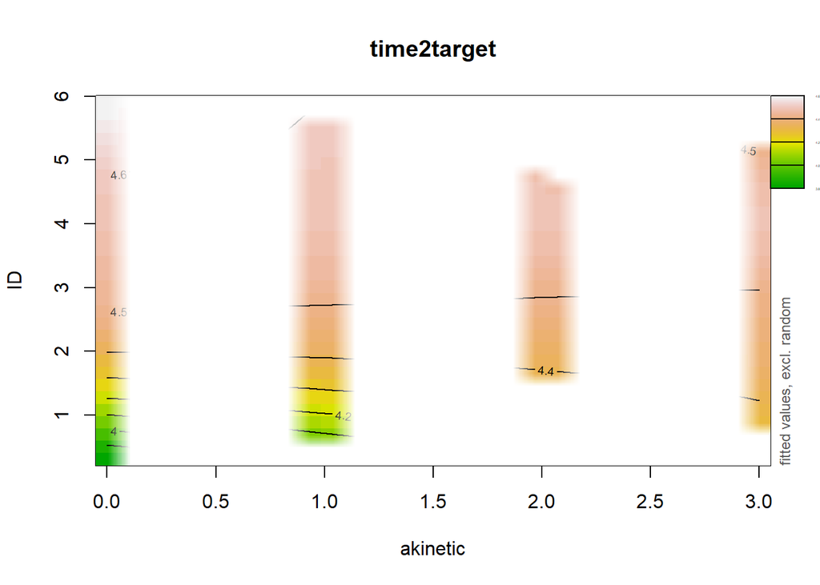

```r
fadeRug(df5$akinetic, df5$ID)
```

Only the smooth without the intercept:

```r
pvisgam(mPD5ti_minPD19, view=c("akinetic","ID"), select=1, fadeRUG=T)
```

```
## [1] "Tensor(s) to be plotted: ti(akinetic,ID)"
```

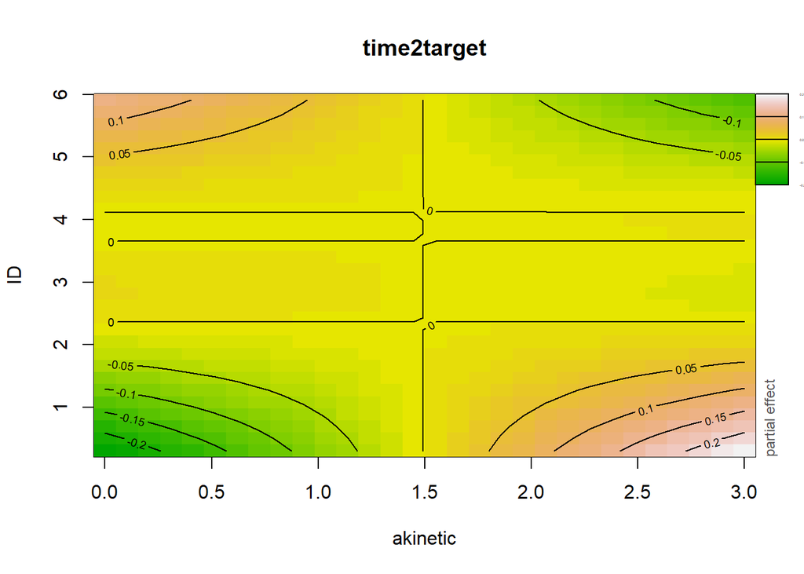

Per subject: UPDRS akinetic score?

```r
summary(mPD5ti_subj <- bam(time2target ~  s(ID, by = subj) + s(akinetic, k = 5) + s(rep.no, k= 9) + segO + s(ID) + s(pace) + subj, data = df4, discrete = T, nthreads = 10, family = Gamma(link=log)))
```

```
##
## Family: Gamma
## Link function: log
##
## Formula:
## time2target ~ s(ID, by = subj) + s(akinetic, k = 5) + s(rep.no,
##     k = 9) + segO + s(ID) + s(pace) + subj
##
## Parametric coefficients:
##               Estimate Std. Error t value Pr(>|t|)
## (Intercept)  4.5649244  0.0405932 112.456  < 2e-16 ***
## segOK        0.0414132  0.0047780   8.667  < 2e-16 ***
## segOT       -0.0000284  0.0037251  -0.008  0.99392
## subjCTRL02  -0.0167886  0.0460813  -0.364  0.71564
## subjCTRL03  -0.0061179  0.0450918  -0.136  0.89208
## subjCTRL04  -0.0008923  0.0410610  -0.022  0.98266
## subjCTRL05   0.0353240  0.0413505   0.854  0.39302
## subjCTRL06  -0.0323380  0.0511905  -0.632  0.52761
## subjCTRL07  -0.0539518  0.0420564  -1.283  0.19963
## subjCTRL08  -0.0344089  0.0519201  -0.663  0.50755
## subjCTRL09  -0.0280322  0.0420598  -0.666  0.50514
## subjCTRL10  -0.0397035  0.0425630  -0.933  0.35098
## subjCTRL11   0.1549402  0.1287665   1.203  0.22895
## subjCTRL12  -0.0185793  0.0418620  -0.444  0.65720
## subjCTRL13   0.0822397  0.1349234   0.610  0.54221
## subjCTRL14   0.0732623  0.1798204   0.407  0.68372
## subjCTRL16   0.0150819  0.0600564   0.251  0.80173
## subjCTRL17  -0.0530818  0.0420618  -1.262  0.20703
## subjCTRL18  -0.0312559  0.0455971  -0.685  0.49308
## subjCTRL20  -0.0660205  0.0431417  -1.530  0.12603
## subjCTRL22   0.0678289  0.0977351   0.694  0.48772
## subjCTRL23  -0.0102473  0.0429906  -0.238  0.81161
## subjCTRL24   0.0048410  0.0642714   0.075  0.93996
## subjCTRL25  -0.1397483  0.0801353  -1.744  0.08126 .
## subjPD01     0.1891463  0.2937500   0.644  0.51968
## subjPD02    -0.3116547  0.0729209  -4.274 1.97e-05 ***
## subjPD03    -0.0613968  0.0430169  -1.427  0.15359
## subjPD04    -0.0846025  0.0493264  -1.715  0.08640 .
## subjPD05    -0.0608100  0.0435862  -1.395  0.16305
## subjPD06    -0.2724683  0.6227750  -0.438  0.66177
```

[output cut: 56 more lines]

```
## s(ID):subjPD19    2.872e+00  3.014e+00  17.083  < 2e-16 ***
## s(ID):subjPD21    4.411e+00  5.191e+00  25.325  < 2e-16 ***
## s(ID):subjPD22    5.670e+00  6.611e+00  14.626  < 2e-16 ***
## s(ID):subjPD23    1.000e+00  1.000e+00  23.374 1.85e-06 ***
## s(ID):subjPD25    5.313e+00  5.971e+00   8.808  < 2e-16 ***
## s(akinetic)      -2.435e-15 -6.446e-15   0.000 1.000000
## s(rep.no)         2.237e+00  2.780e+00  13.996  < 2e-16 ***
## s(ID)             6.020e+00  6.928e+00   7.524  < 2e-16 ***
## s(pace)           7.134e+00  8.191e+00 372.009  < 2e-16 ***
## ---
## Signif. codes:  0 '***' 0.001 '**' 0.01 '*' 0.05 '.' 0.1 ' ' 1
##
## Rank: 450/452
## R-sq.(adj) =  0.922   Deviance explained = 92.9%
## fREML = -4031.6  Scale est. = 0.0057662  n = 3801
```

Plot:

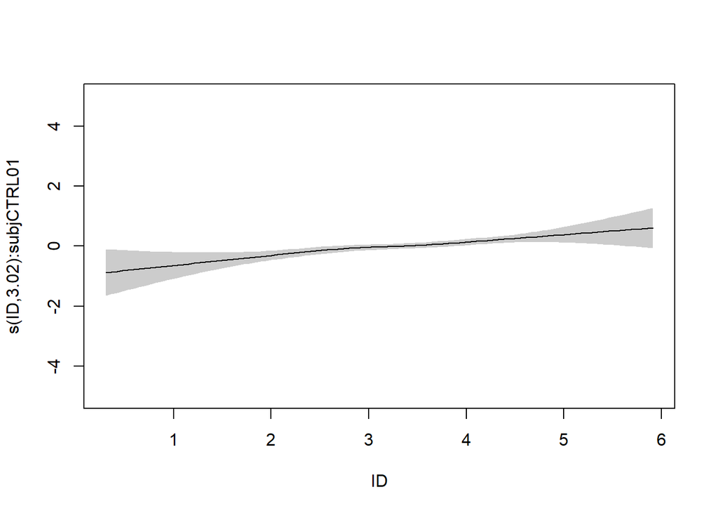

```r
plot(mPD5ti_subj, select = 1, shade = T, rug = F, ylim = c(-5,5))
```

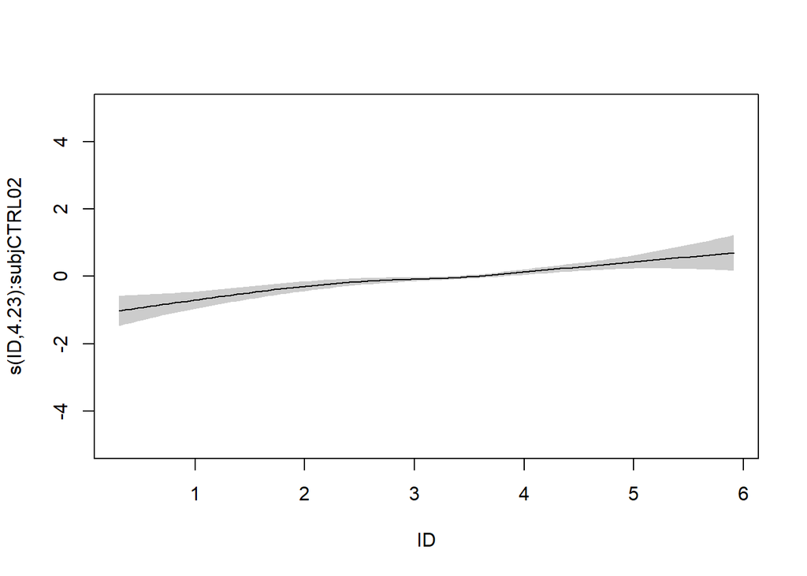

```r
plot(mPD5ti_subj, select = 2, shade = T, rug = F, ylim = c(-5,5))
```

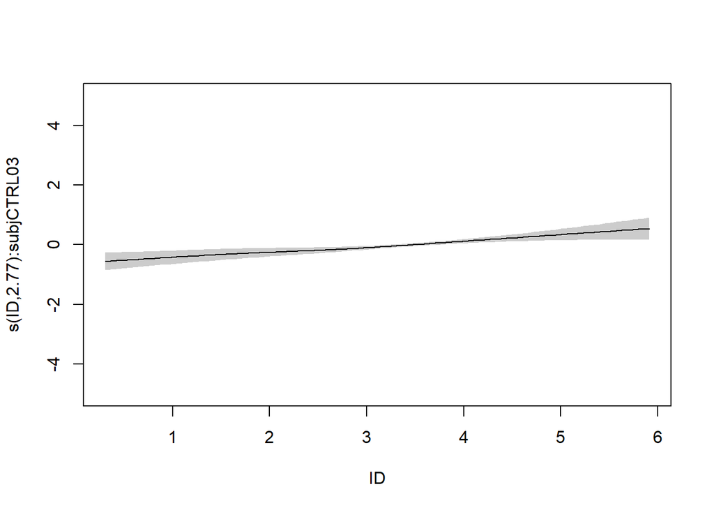

```r
plot(mPD5ti_subj, select = 3, shade = T, rug = F, ylim = c(-5,5))
```

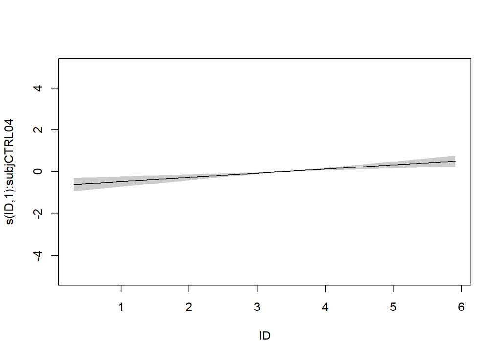

```r
plot(mPD5ti_subj, select = 4, shade = T, rug = F, ylim = c(-5,5))
```